# O Mercado de Trabalho Formal dos Arqueólogos

Análise dos Dados da RAIS e do Novo CAGED - 2022 a 2025

Autor

Data de Publicação

29 de agosto de 2026

# 1 Notas Introdutórias

Este artigo apresenta uma análise dos microdados da RAIS (Relação Anual de Informações Sociais) e do Novo CAGED (Cadastro Geral de Empregados e Desempregados) para o período de 2022 a 2025, relativo à ocupação de arqueólogo. Os dados foram obtidos de registros tratados disponibilizados no GitHub (Machado, 2026), processados e consolidados para a geração de gráficos e tabelas.

É importante esclarecer que esta análise não pretende comparar-se nem dar continuidade ao estudo de Machado e Mageste (2024), que investigaram os mesmos dados para o intervalo temporal de 1994 a 2021. Essa decisão de não cruzar as duas séries históricas segue a recomendação do Ministério do Trabalho e Emprego (MTE), que orienta que os dados da RAIS a partir de 2022 não devem ser comparados com os registros anteriores.

O MTE divulgou uma nota técnica (Brasil. Ministério do Trabalho e Emprego, 2024), detalhando a transição metodológica na coleta dos registros trabalhistas, implementada gradualmente desde 2018 e concluída em 2022. O sistema tradicional GD-RAIS, de envio anual, foi substituído pelo [eSocial](https://www.senior.com.br/esocial), de periodicidade mensal e contínua. O ano-base 2022, por ser o último da transição, contém declarações híbridas provenientes de ambos os sistemas, o que inviabiliza a comparabilidade com anos anteriores. Essa mesma ressalva se aplica ao Novo CAGED, conforme apontado por pesquisadores no assunto (Ottoni, Bruno, 2021).

Neste estudo pretende-se analisar diferentes variáveis e o comportamento dessas informações ao longo do intervalo temporal, que inclui:

- No caso da RAIS:
  - Quantitativo de registros declarados e os tipos de vínculos em 31/12
  - Distribuição dos vínculos ativos em 31/12 por:
    - Região
    - Estados
    - Vínculo empregatício
    - Natureza jurídica do empregador
    - Tamanho do estabelecimento por setores econômicos
    - Trabalho intermitente
    - Escolaridade dos arqueólogos
    - Intervalo por grupos de:
      - Idades
      - Horas trabalhadas
      - Tempo de emprego
    - Sexo
    - Cor/raça
    - Análise remuneratória
  - Distribuição dos vínculos desligados em 31/12 por:
    - Motivo do desligamento
    - Sexo
- Para o Novo CAGED:
  - Movimentações por
    - Ano
    - Mês
    - Região
    - Estados
    - Sexo
  - Remuneração dos admitidos

Os gráficos e tabelas foram gerados na linguagem de programação R. As visualizações são dinâmicas e interativas: ao passar o cursor sobre barras ou linhas, o usuário visualiza informações detalhadas; também é possível filtrar registros para exibir apenas os dados de interesse no painel.

[figure not shown]

Figura 1: Exemplo de interação em gráfico [dinâmico 1](https://pic1.zhimg.com/v2-a6d90f9da067aa0caaa266e63b64e1a4_b.gif)

[figure not shown]

Figura 2: Exemplo de interação em gráfico [dinâmico 2](https://pic2.zhimg.com/v2-355a0328399c8c4b8529be44b3cb9ced_b.gif)

Destaca-se que este estudo contou com o auxílio de Inteligência Artificial generativa para revisão textual, melhorias de script e identificação de padrões ocultos nos dados.

# 2 Carregando e Processando Dados

Conforme mencionado anteriormente, os dados foram obtidos do repositório GitHub (Machado, 2026) do autor e processados para gerar os gráficos e tabelas deste artigo. Para garantir transparência metodológica, cada visualização - gráfico ou tabela - inclui um botão no canto superior esquerdo rotulado “Mostrar código executado”. Ao clicar, o leitor acessa diretamente o script R que produziu aquele resultado específico, permitindo verificação e reprodução dos procedimentos.

Todo o artigo foi produzido no [Quarto](https://quarto.org/), uma ferramenta de publicação técnica de código aberto que integra código executável (R, Python, Julia e Observable) a documentos narrativos.

As ferramentas empregadas - a linguagem R, o sistema Quarto e os pacotes usados em cada etapa - estão documentadas na Seção 6.13, com as versões utilizadas.

**Mostrar código executado**

```r
#---------------RAIS---------------
# 2022
url <- "https://github.com/machadotm/Novos_Dados_MTE_Arqueo/raw/refs/heads/main/2022/RAIS/Dados_Tratados_RAIS_2022.xlsx"
tmp <- tempfile(fileext = ".xlsx")
invisible(capture.output(
GET(url, write_disk(tmp))))
Arqueo.RAIS.2022 <- read_excel(tmp)

# 2023
url2 <- "https://github.com/machadotm/Novos_Dados_MTE_Arqueo/raw/refs/heads/main/2023/RAIS/Dados_Tratados_RAIS_2023.xlsx"
tmp2 <- tempfile(fileext = ".xlsx")
invisible(capture.output(
GET(url2, write_disk(tmp2))))
Arqueo.RAIS.2023 <- read_excel(tmp2)

# Ajustes 2023
Arqueo.RAIS.2023$Ano <- as.numeric(Arqueo.RAIS.2023$Ano)
Arqueo.RAIS.2023$Mês.Desligamento <- as.character(Arqueo.RAIS.2023$Mês.Desligamento)
Arqueo.RAIS.2023$Vl.Rem.Dezembro..SM <- as.numeric(Arqueo.RAIS.2023$Vl.Rem.Dezembro..SM)
Arqueo.RAIS.2023$Vl.Rem.Média.Nom <- as.numeric(Arqueo.RAIS.2023$Vl.Rem.Média.Nom)
Arqueo.RAIS.2023$Vl.Rem.Média..SM <- as.numeric(Arqueo.RAIS.2023$Vl.Rem.Média..SM)
Arqueo.RAIS.2023$Tempo.Emprego <- as.numeric(Arqueo.RAIS.2023$Tempo.Emprego)
Arqueo.RAIS.2023$Vl.Rem.Junho.SC <- as.numeric(Arqueo.RAIS.2023$Vl.Rem.Junho.SC)

Causa.Afast.DF1 <- data.frame(
  categorias = c("ACI TRB TIP", "ACI TRB TJT", "DOEN REL TR", "DOEN NREL TR", "LIC MATERNID", "SERV MILITAR", "LIC SEM VENC",
                 "LIC COM VENC", "SUSP TEMP DE TRAB", "ACID DOENC TRAB", "SEM AFASTAMENTOS", "IGNORADO"),
  Causa.Afastamento.1 = c(10, 20, 30, 40, 50, 60, 70, 80, 85, 90, 999, -1)
)

Arqueo.RAIS.2023 <- left_join(Arqueo.RAIS.2023, Causa.Afast.DF1, by = "Causa.Afastamento.1") %>%
  mutate(Causa.Afastamento.1 = categorias) %>%
  select(-categorias)

Causa.Afast.DF2 <- data.frame(
  categorias = c("ACI TRB TIP", "ACI TRB TJT", "DOEN REL TR", "DOEN NREL TR", "LIC MATERNID", "SERV MILITAR", "LIC SEM VENC",
                 "LIC COM VENC", "SUSP TEMP DE TRAB", "ACID DOENC TRAB", "SEM AFASTAMENTOS", "IGNORADO"),
  Causa.Afastamento.2 = c(10, 20, 30, 40, 50, 60, 70, 80, 85, 90, 999, -1)
)

Arqueo.RAIS.2023 <- left_join(Arqueo.RAIS.2023, Causa.Afast.DF2, by = "Causa.Afastamento.2") %>%
  mutate(Causa.Afastamento.2 = categorias) %>%
  select(-categorias)

# 2024
url3 <- "https://github.com/machadotm/Novos_Dados_MTE_Arqueo/raw/refs/heads/main/2024/RAIS/Dados_Tratados_RAIS_2024.xlsx"
tmp3 <- tempfile(fileext = ".xlsx")
invisible(capture.output(
GET(url3, write_disk(tmp3))))
Arqueo.RAIS.2024 <- read_excel(tmp3)

Arqueo.RAIS.2024$Mês.Desligamento <- as.character(Arqueo.RAIS.2024$Mês.Desligamento)
Arqueo.RAIS.2024$Vl.Rem.Dezembro..SM <- as.numeric(Arqueo.RAIS.2024$Vl.Rem.Dezembro..SM)
Arqueo.RAIS.2024$Vl.Rem.Média.Nom <- as.numeric(Arqueo.RAIS.2024$Vl.Rem.Média.Nom)
Arqueo.RAIS.2024$Vl.Rem.Média..SM <- as.numeric(Arqueo.RAIS.2024$Vl.Rem.Média..SM)
Arqueo.RAIS.2024$Tempo.Emprego <- as.numeric(Arqueo.RAIS.2024$Tempo.Emprego)
Arqueo.RAIS.2024$Vl.Rem.Maio.SC <- as.numeric(Arqueo.RAIS.2024$Vl.Rem.Maio.SC)
Arqueo.RAIS.2024$Vl.Rem.Junho.SC <- as.numeric(Arqueo.RAIS.2024$Vl.Rem.Junho.SC)
Arqueo.RAIS.2024$Vl.Rem.Setembro.SC <- as.numeric(Arqueo.RAIS.2024$Vl.Rem.Setembro.SC)
Arqueo.RAIS.2024$Vl.Rem.Outubro.SC <- as.numeric(Arqueo.RAIS.2024$Vl.Rem.Outubro.SC)

Arqueo.RAIS.2024 <- left_join(Arqueo.RAIS.2024, Causa.Afast.DF1, by = "Causa.Afastamento.1") %>%
  mutate(Causa.Afastamento.1 = categorias) %>%
  select(-categorias)

Arqueo.RAIS.2024 <- left_join(Arqueo.RAIS.2024, Causa.Afast.DF2, by = "Causa.Afastamento.2") %>%
  mutate(Causa.Afastamento.2 = categorias) %>%
  select(-categorias)

# 2025
url4 <- "https://github.com/machadotm/Novos_Dados_MTE_Arqueo/raw/refs/heads/main/2025/RAIS/Dados_Tratados_RAIS_2025.xlsx"
tmp4 <- tempfile(fileext = ".xlsx")
invisible(capture.output(
GET(url4, write_disk(tmp4))))
Arqueo.RAIS.2025 <- read_excel(tmp4)

Arqueo.RAIS.2025$Ano <- 2025
Arqueo.RAIS.2025 <- Arqueo.RAIS.2025 |>
  relocate(Ano, .before = Bairros.SP)

Arqueo.RAIS.2025$Mês.Desligamento <- as.character(Arqueo.RAIS.2025$Mês.Desligamento)
Arqueo.RAIS.2025$Vl.Rem.Dezembro..SM <- as.numeric(Arqueo.RAIS.2025$Vl.Rem.Dezembro..SM)
Arqueo.RAIS.2025$Vl.Rem.Média.Nom <- as.numeric(Arqueo.RAIS.2025$Vl.Rem.Média.Nom)
Arqueo.RAIS.2025$Vl.Rem.Média..SM <- as.numeric(Arqueo.RAIS.2025$Vl.Rem.Média..SM)
Arqueo.RAIS.2025$Tempo.Emprego <- as.numeric(Arqueo.RAIS.2025$Tempo.Emprego)
Arqueo.RAIS.2025$Vl.Rem.Maio.SC <- as.numeric(Arqueo.RAIS.2025$Vl.Rem.Maio.SC)
Arqueo.RAIS.2025$Vl.Rem.Junho.SC <- as.numeric(Arqueo.RAIS.2025$Vl.Rem.Junho.SC)
Arqueo.RAIS.2025$Vl.Rem.Setembro.SC <- as.numeric(Arqueo.RAIS.2025$Vl.Rem.Setembro.SC)
Arqueo.RAIS.2025$Vl.Rem.Outubro.SC <- as.numeric(Arqueo.RAIS.2025$Vl.Rem.Outubro.SC)

Arqueo.RAIS.2025 <- left_join(Arqueo.RAIS.2025, Causa.Afast.DF1, by = "Causa.Afastamento.1") %>%
  mutate(Causa.Afastamento.1 = categorias) %>%
  select(-categorias)

Arqueo.RAIS.2025 <- left_join(Arqueo.RAIS.2025, Causa.Afast.DF2, by = "Causa.Afastamento.2") %>%
  mutate(Causa.Afastamento.2 = categorias) %>%
  select(-categorias)

Arqueo.RAIS.2025 <- Arqueo.RAIS.2025 |>
  mutate(CNAE.2.0.Subclasse= case_when(
    CNAE.2.0.Classe == 'Edição de jornais' ~ 'Edição de Jornais Diarios',
    TRUE ~ CNAE.2.0.Subclasse
  ))

# Juntar todos os anos
junta <- full_join(Arqueo.RAIS.2022, Arqueo.RAIS.2023, by = NULL)
junta2 <- full_join(junta, Arqueo.RAIS.2024, by= NULL)
Arqueo.RAIS.2022_2025 <- full_join(junta2, Arqueo.RAIS.2025, by = NULL)

# Remover objetos temporários
rm(tmp, tmp2, tmp3, tmp4, junta, junta2, url, url2, url3, url4, Causa.Afast.DF1, Causa.Afast.DF2)

#---------------------------Novo CAGED-------------------------------

url5 <- "https://github.com/machadotm/Novos_Dados_MTE_Arqueo/raw/refs/heads/main/2022/Novo_CAGED/Dados_Tratados_Novo%20CAGED_2022.xlsx"
tmp5 <- tempfile(fileext = ".xlsx")  # Cria arquivo temporário
invisible(capture.output(
GET(url5, write_disk(tmp5))))  # Baixa o arquivo

Arqueo.CAGED.2022 <- read_excel(tmp5)

url6 <- "https://github.com/machadotm/Novos_Dados_MTE_Arqueo/raw/refs/heads/main/2023/Novo_CAGED/Dados_Tratados_Novo%20CAGED_2023.xlsx"
tmp6 <- tempfile(fileext = ".xlsx")
invisible(capture.output(
GET(url6, write_disk(tmp6))))

Arqueo.CAGED.2023 <- read_excel(tmp6)

url7 <- "https://github.com/machadotm/Novos_Dados_MTE_Arqueo/raw/refs/heads/main/2024/Novo_CAGED/Dados_Tratados_Novo%20CAGED_2024.xlsx"
tmp7 <- tempfile(fileext = ".xlsx")
invisible(capture.output(
GET(url7, write_disk(tmp7))))

Arqueo.CAGED.2024 <- read_excel(tmp7)

url8 <- "https://github.com/machadotm/Novos_Dados_MTE_Arqueo/raw/refs/heads/main/2025/Novo_CAGED/Dados_Tratados_Novo%20CAGED_2025.xlsx"
tmp8 <- tempfile(fileext = ".xlsx")
invisible(capture.output(
GET(url8, write_disk(tmp8))))

Arqueo.CAGED.2025 <- read_excel(tmp8)

junta3 <- full_join(Arqueo.CAGED.2022, Arqueo.CAGED.2023, by= NULL)

Arqueo.CAGED.2024$horascontratuais <- gsub(",", ".",
                                           Arqueo.CAGED.2024$horascontratuais)

Arqueo.CAGED.2024$horascontratuais <- as.numeric(Arqueo.CAGED.2024$horascontratuais)

Arqueo.CAGED.2024$salário <- gsub(",", ".",
                                           Arqueo.CAGED.2024$salário)

Arqueo.CAGED.2024$salário <- as.numeric(Arqueo.CAGED.2024$salário)

Arqueo.CAGED.2024$valorsaláriofixo <- gsub(",", ".",
                                  Arqueo.CAGED.2024$valorsaláriofixo)

Arqueo.CAGED.2024$valorsaláriofixo <- as.numeric(Arqueo.CAGED.2024$valorsaláriofixo)

junta4 <- full_join(junta3, Arqueo.CAGED.2024, by= NULL)

Arqueo.CAGED.2022_2025 <- full_join(junta4, Arqueo.CAGED.2025, by= NULL)

# Remover objetos temporários
rm(tmp5, tmp6, tmp7, tmp8, junta3, junta4, url5, url6, url7, url8)
```

# 3 RAIS

A RAIS (Brasil. Ministério do Trabalho e Emprego, 2026a) constitui uma das principais bases de dados do governo federal para o acompanhamento do mercado de trabalho formal no Brasil. Com a conclusão da transição para o eSocial em 2022, a forma de prestação das informações foi alterada: os empregadores deixaram de utilizar a declaração anual específica (GD‑RAIS) e passaram a ter seus dados extraídos diretamente dos eventos trabalhistas transmitidos mensalmente ao sistema eSocial. Apesar dessa mudança no fluxo de coleta, a divulgação dos resultados permanece anual, organizada por ano‑base. A abrangência da RAIS inclui trabalhadores celetistas do setor privado, empregados públicos regidos pela CLT, servidores estatutários e militares, o que a consolida como a fonte mais completa disponível sobre o estoque de vínculos formais de trabalho no país. O ano‑base mais recente disponível para consulta é de 2025.

A tabela interativa abaixo exibe todas as declarações referentes à profissão de arqueólogo da RAIS de 2022 a 2025.

**Mostrar código executado**

```r
# Converte todas as colunas de texto para fator
rais_tabela <- Arqueo.RAIS.2022_2025 %>%
  mutate(across(where(is.character), as.factor)) |>
  mutate(Ano = as.factor(Ano))

DT::datatable(
  rais_tabela,
  filter     = 'top',
  extensions = 'Buttons',
  options = list(
    dom = 'Bfrtip',
    buttons = list(
      list(extend = 'copy',  text = 'Copiar'),
      list(extend = 'csv',   text = 'Baixar CSV',
           filename = 'RAIS_arqueologos_2022_2025'),
      list(extend = 'excel', text = 'Baixar Excel',
           filename = 'RAIS_arqueologos_2022_2025',
           title    = 'RAIS — CBO 2511-10 — 2022 a 2025')
    ),
    language = list(
       search        = "Filtrar:",
       lengthMenu    = "Mostrar _MENU_ registros",
       info          = "Mostrando _START_ a _END_ de _TOTAL_ registros",
       infoEmpty     = "Nenhum registro",
       infoFiltered  = "(filtrados de _MAX_ registros)",
       zeroRecords   = "Nenhum registro encontrado",
       paginate      = list(previous = "Anterior", `next` = "Próximo",
                            first = "Primeiro", last = "Último")
    ),
    pageLength = 5,
    autoWidth  = TRUE,
    columnDefs = list(list(className = 'dt-nowrap', targets = "_all")),
    scrollX    = TRUE
  )
)
```

Tabela 1: Conjunto geral de dados da RAIS 2022 a 2025

|  | Ano | Bairros.SP | Bairros.Fortaleza | Bairros.RJ | Causa.Afastamento.1 | Causa.Afastamento.2 | Causa.Afastamento.3 | Motivo.Desligamento | CBO.2002.Ocupação | CNAE.2.0.Classe | CNAE.95.Classe | Distritos.SP | Ind.Vínculo.Ativo.31.12 | Faixa.Etária | Faixa.Rem.Média..SM | Faixa.Hora.Contrat | Faixa.Rem.Dez..SM | Faixa.Tempo.Emprego | Escolaridade.Após.2005 | Qtd.Hora.Contr | Idade | Ind.CEI.Vinculado | Ind.Estabelecimento.Participante.SIMPLES | Mês.Admissão | Mês.Desligamento | Município.Trab | Município | UF.Estabelecimento | Nacionalidade | … |
| --- | --- | --- | --- | --- | --- | --- | --- | --- | --- | --- | --- | --- | --- | --- | --- | --- | --- | --- | --- | --- | --- | --- | --- | --- | --- | --- | --- | --- | --- | --- |
| 1 | 2022 | 9997 | 9997 | 9997 | SEM AFASTAMENTOS | SEM AFASTAMENTOS | SEM AFASTAMENTOS | NAO DESL ANO | 251110 | Atividades de contabilidade, consultoria e auditoria contábil e tributária | Atividades de Contabilidade e Auditoria | 9997 | SIM | 40 A 49 anos | 1,01 a 1,50 salários mínimos | 41 a 44 horas | 1,01 a 1,50 salários mínimos | 60,0 a 119,9 meses | SUP. COMP | 44 | 45 | NAO | SIM | 6 | {ñ | Aquidauana-MS | Aquidauana-MS | MS | Brasileira | … |
| 2 | 2022 | 9997 | 9997 | 9997 | SEM AFASTAMENTOS | SEM AFASTAMENTOS | SEM AFASTAMENTOS | NAO DESL ANO | 251110 | Serviços de engenharia | Serviços de Arquitetura e Engenharia e de Assessoramento Técnico Especializado | 9997 | SIM | 25 A 29 anos | 3,01 a 4,00 salários mínimos | 41 a 44 horas | 3,01 a 4,00 salários mínimos | 36,0 a 59,9 meses | SUP. COMP | 44 | 28 | NAO | NAO | 8 | {ñ | Salvador-BA | Cuiaba-MT | MT | Brasileira | … |
| 3 | 2022 | 9997 | 9997 | 9997 | SEM AFASTAMENTOS | SEM AFASTAMENTOS | SEM AFASTAMENTOS | TERM CONTR | 251110 | Atividades técnicas relacionadas à arquitetura e engenharia | Serviços de Arquitetura e Engenharia e de Assessoramento Técnico Especializado | 9997 | NÃO | 25 A 29 anos | Não Ativ Dez | 41 a 44 horas | 2,01 a 3,00 salários mínimos | Ate 2,9 meses | MEDIO COMPL | 44 | 25 | NAO | NAO | 8 | 11 | Goiania-GO | Goiania-GO | GO | Brasileira | … |
| 4 | 2022 | 9997 | 9997 | 9997 | SEM AFASTAMENTOS | SEM AFASTAMENTOS | SEM AFASTAMENTOS | DESL SEM JC | 251110 | Serviços de arquitetura | Serviços de Arquitetura e Engenharia e de Assessoramento Técnico Especializado | 9997 | NÃO | 30 A 39 anos | Não Ativ Dez | 41 a 44 horas | 2,01 a 3,00 salários mínimos | Ate 2,9 meses | MEDIO COMPL | 44 | 34 | NAO | SIM | 6 | 07 | Goias-GO | Goias-GO | GO | Brasileira | … |
| 5 | 2022 | 9997 | 9997 | 9997 | SEM AFASTAMENTOS | SEM AFASTAMENTOS | SEM AFASTAMENTOS | DESL SEM JC | 251110 | Atividades técnicas relacionadas à arquitetura e engenharia | Serviços de Arquitetura e Engenharia e de Assessoramento Técnico Especializado | 9997 | NÃO | 18 A 24 anos | Não Ativ Dez | 41 a 44 horas | 2,01 a 3,00 salários mínimos | 6,0 a 11,9 meses | SUP. COMP | 44 | 23 | NAO | NAO | 11 | 06 | Goiania-GO | Goiania-GO | GO | Brasileira | … |
| 6 | 2022 | 9997 | 9997 | 9997 | SEM AFASTAMENTOS | SEM AFASTAMENTOS | SEM AFASTAMENTOS | TERM CONTR | 251110 | Atividades técnicas relacionadas à arquitetura e engenharia | Serviços de Arquitetura e Engenharia e de Assessoramento Técnico Especializado | 9997 | NÃO | 40 A 49 anos | Não Ativ Dez | 41 a 44 horas | 4,01 a 5,00 salários mínimos | Ate 2,9 meses | SUP. COMP | 44 | 44 | NAO | NAO | 2 | 04 | Santos-SP | Goiania-GO | GO | Brasileira | … |
| 7 | 2022 | 9997 | 9997 | 9997 | SEM AFASTAMENTOS | SEM AFASTAMENTOS | SEM AFASTAMENTOS | DESL SEM JC | 251110 | Atividades técnicas relacionadas à arquitetura e engenharia | Serviços de Arquitetura e Engenharia e de Assessoramento Técnico Especializado | 9997 | NÃO | 40 A 49 anos | Não Ativ Dez | 41 a 44 horas | Até 0,50 salários mínimos | 6,0 a 11,9 meses | SUP. COMP | 44 | 41 | NAO | NAO | 6 | 01 | Jau-SP | Goiania-GO | GO | Brasileira | … |
| 8 | 2022 | 9997 | 9997 | 9997 | SEM AFASTAMENTOS | SEM AFASTAMENTOS | SEM AFASTAMENTOS | DESL SEM JC | 251110 | Atividades técnicas relacionadas à arquitetura e engenharia | Serviços de Arquitetura e Engenharia e de Assessoramento Técnico Especializado | 9997 | NÃO | 30 A 39 anos | Não Ativ Dez | 41 a 44 horas | 3,01 a 4,00 salários mínimos | 12,0 a 23,9 meses | SUP. COMP | 44 | 31 | NAO | NAO | 7 | 07 | Goiania-GO | Goiania-GO | GO | Brasileira | … |
| 9 | 2022 | 9997 | 9997 | 9997 | SEM AFASTAMENTOS | SEM AFASTAMENTOS | SEM AFASTAMENTOS | DEM SEM JC | 251110 | Atividades técnicas relacionadas à arquitetura e engenharia | Serviços de Arquitetura e Engenharia e de Assessoramento Técnico Especializado | 9997 | NÃO | 25 A 29 anos | Não Ativ Dez | 41 a 44 horas | 2,01 a 3,00 salários mínimos | 6,0 a 11,9 meses | SUP. COMP | 44 | 29 | NAO | NAO | 7 | 03 | Santarem-PA | Goiania-GO | GO | Brasileira | … |
| 10 | 2022 | 9997 | 9997 | 9997 | SEM AFASTAMENTOS | SEM AFASTAMENTOS | SEM AFASTAMENTOS | TERM CONTR | 251110 | Serviços de arquitetura | Serviços de Arquitetura e Engenharia e de Assessoramento Técnico Especializado | 9997 | NÃO | 30 A 39 anos | Não Ativ Dez | 41 a 44 horas | 2,01 a 3,00 salários mínimos | Ate 2,9 meses | SUP. COMP | 44 | 36 | NAO | SIM | 8 | 10 | Aparecida de Goiania-GO | Goias-GO | GO | Brasileira | … |

[output cut: 1932 more lines]

> Para o ano de 2025, há dados referentes a categoria do trabalhador (última coluna da tabela acima). No entanto, até o fechamento da escrita deste artigo, não houve atualização do dicionário de dados de modo a identificar a codificação dessa nova variável adicionada na base da RAIS.

## 3.1 Dados Gerais

As declarações trabalhistas para a profissão de arqueólogo registraram crescimento contínuo no período analisado. É possível que essa tendência seja reflexo das mudanças metodológicas implementadas pelo eSocial, que ampliaram a abrangência da captação de dados.

**Mostrar código executado**

```r
geral.anual <- Arqueo.RAIS.2022_2025 %>%
  group_by(Ano) %>%
  summarise(total = n()) |>
  mutate(Ano = as.factor(Ano))

# Gráfico interativo com echarts4r
geral.anual %>%
  e_charts(Ano) %>%
  e_bar(total, name = "Vínculos") %>%
  e_tooltip(
    extraCssText = "text-align: left;",
    trigger = "axis",
    formatter = htmlwidgets::JS("
      function(params) {
        var ano = params[0].value[0];
        var total = params[0].value[1];
        return 'Ano: ' + ano + '<br/>Vínculos: ' + total;
      }
    ")
  ) %>%
  e_title(
    text = "Mercado de Trabalho Formal de Arqueólogos - RAIS 2022 a 2025",
    subtext = "Total de Vínculos Declarados",
    left = "center",
    textStyle = list(fontSize = 15, fontWeight = "bold"),
    subtextStyle = list(fontSize = 12, fontWeight = "bold")
  ) %>%
  e_y_axis(
    min = 0,
    splitLine = list(show = TRUE),
    axisLabel = list(fontSize = 11),
    scale = TRUE,
    axisLine = list(show = TRUE)
  ) %>%
  e_grid(containLabel = TRUE) %>%
  e_legend(show = FALSE) |>
  e_color("#E74C3C")
```

[interactive chart not shown]

Figura 3: Quantitativo geral de declarações

Na segmentação por tipo de vínculo, considerando a data de corte de 31/12 de cada ano, os vínculos ativos representam a parcela predominante, acumulando crescimento de 30,27% ao longo do período. As declarações de desligamento, por sua vez, exibem relativa estabilidade, com variações modestas e mantendo-se em patamar significativamente inferior ao do grupo de vínculos ativos no quadriênio analisado.

**Mostrar código executado**

```r
vinculos_31.12 <- Arqueo.RAIS.2022_2025 %>%
  group_by(Ano, Ind.Vínculo.Ativo.31.12) %>%
  summarise(quant.tipo.vinculo = n(), .groups = "drop") %>%
  mutate(Ind.Vínculo.Ativo.31.12 = dplyr::recode(Ind.Vínculo.Ativo.31.12,
                                                  SIM = "ATIVOS",
                                                  NÃO = "DESLIGADOS")) %>%
  mutate(Ind.Vínculo.Ativo.31.12 = factor(Ind.Vínculo.Ativo.31.12,
                                          levels = c("ATIVOS", "DESLIGADOS"))) %>%
  arrange(Ano, Ind.Vínculo.Ativo.31.12) |>
  mutate(Ano = as.factor(Ano))

vinculos_31.12 %>%
  group_by(Ind.Vínculo.Ativo.31.12) %>%
  e_charts(Ano, timeline = FALSE) %>%
  e_bar(quant.tipo.vinculo, stack = FALSE) %>%
  e_flip_coords() %>%
  e_y_axis(inverse = TRUE, axisLabel = list(fontSize = 9)) %>%
  e_x_axis(
    axisLabel = list(fontSize = 9),
    splitLine = list(show = FALSE), axisLine = list(show = TRUE)
  ) %>%
  e_title(
    text = "Mercado de Trabalho Formal de Arqueólogos - RAIS 2022 a 2025",
    subtext = "Tipo de Vínculos em 31/12",
    left = "center",
    textStyle = list(fontSize = 15, fontWeight = "bold"),
    subtextStyle = list(fontSize = 12, fontWeight = "bold")
  ) %>%
  e_color(c("#1874CD", "#FF4040")) %>%
  e_grid(containLabel = TRUE, left = "10%", right = "5%") %>%
  e_tooltip(
    extraCssText = "text-align: left;",
    trigger = "axis",
    formatter = htmlwidgets::JS("
      function(params) {
        var ano = params[0].axisValue;
        var result = 'Ano: ' + ano + '<br/>';
        params.forEach(function(p) {
          result += p.marker + ' ' + p.seriesName + ': ' + p.value[0] + '<br/>';
        });
        return result;
      }
    ")
  )
```

[interactive chart not shown]

Figura 4: Declarações por modalidades de vínculos em 31/12

## 3.2 Análise dos Vínculos Ativos em 31/12

Os gráficos a seguir foram gerados a partir das declarações cujo indicador de vínculo ativo em 31/12 apresenta o valor `"SIM"` - ou seja, referem-se exclusivamente a arqueólogos que permaneceram em seus postos de trabalho até o final de cada ano-base. A filtragem foi aplicada sobre a coluna `Ind.Vínculo.Ativo.31.12`, selecionando apenas os registros com status ativo no recorte temporal.

### 3.2.1 Distribuição por Região

Na distribuição dos vínculos ativos por macrorregião, a Região Sudeste concentra sistematicamente o maior volume de declarações ao longo de toda a série histórica. A Região Nordeste ocupa a segunda posição e exibe trajetória de crescimento contínuo ao longo do período. A Região Norte, embora registre o menor número absoluto de vínculos, demonstra crescimento constante, atingindo o maior estoque em 2025. Em contraste, a Região Centro-Oeste apresenta tendência de declínio, enquanto a Região Sul mantém um padrão de estabilidade nos registros trabalhistas.

**Mostrar código executado**

```r
Regiao <- Arqueo.RAIS.2022_2025 %>%
  filter(Ind.Vínculo.Ativo.31.12 == "SIM") %>%
  mutate(regioes = UF.Estabelecimento) %>%
  mutate(regioes = recode(regioes,
                          AC = "NORTE", AM = "NORTE", AP = "NORTE", PA = "NORTE",
                          RO = "NORTE", RR = "NORTE", TO = "NORTE",
                          MA = "NORDESTE", PI = "NORDESTE", CE = "NORDESTE",
                          RN = "NORDESTE", PB = "NORDESTE", PE = "NORDESTE",
                          AL = "NORDESTE", SE = "NORDESTE", BA = "NORDESTE",
                          GO = "CENTRO-OESTE", DF = "CENTRO-OESTE", MT = "CENTRO-OESTE",
                          MS = "CENTRO-OESTE",
                          MG = "SUDESTE", SP = "SUDESTE", RJ = "SUDESTE", ES = "SUDESTE",
                          PR = "SUL", SC = "SUL", RS = "SUL")) %>%
  mutate(regioes = factor(regioes,
                          levels = c("NORTE", "NORDESTE", "CENTRO-OESTE",
                                     "SUDESTE", "SUL"))) %>%
  group_by(Ano, regioes) %>%
  summarise(quant.regioes = n(), .groups = "drop") |>
  mutate(Ano = as.factor(Ano))

Regiao |>
  group_by(regioes) |>
  e_charts(Ano) |>
  e_bar(quant.regioes) |>
  e_title(
    text = "Mercado de Trabalho Formal de Arqueólogos - RAIS 2022 a 2025",
    subtext = "Distribuição dos Vínculos Ativos por Região",
    left = "center",
    textStyle = list(fontSize = 15, fontWeight = "bold"),
    subtextStyle = list(fontSize = 12, fontWeight = "bold")
  ) %>%
  e_tooltip(
    extraCssText = "text-align: left;",
    trigger = "item",
    formatter = htmlwidgets::JS("
      function(params) {
        return 'Ano: ' + params.name + '<br/>' +
               params.marker + ' ' + params.seriesName + ': ' + params.value[1];
      }
    ")
  )
```

[interactive chart not shown]

Figura 5: Declarações ativas por região

> A regionalização adotada nesta análise segue a unidade federativa do estabelecimento empregador, ou seja, corresponde ao endereço cadastrado do CNPJ que declara o vínculo trabalhista, e não ao local onde a atividade arqueológica é efetivamente executada. Isso significa que os dados descrevem a localização geográfica das empresas contratantes - suas sedes ou filiais formais - e não o território onde os arqueólogos realizam seus trabalhos de campo.

### 3.2.2 Distribuição por Estados

A desagregação regional por estados revela que nem todas as unidades federativas registraram vínculos ativos de arqueólogos no período analisado. A ausência é mais pronunciada nos estados da Região Norte, indicando menor inserção formal dessa profissão naquela macrorregião.

Em contrapartida, os estados de São Paulo, Pernambuco e Santa Catarina concentram as maiores quantidades de vínculos ativos, configurando polos regionais de demanda por mão de obra arqueológica. Esse padrão evidencia assimetria geográfica na distribuição das oportunidades de emprego formal, com a maior parte dos vínculos concentrada em poucas unidades federativas.

**Mostrar código executado**

```r
estados <- Arqueo.RAIS.2022_2025 %>%
dplyr::filter(Ind.Vínculo.Ativo.31.12=="SIM") %>%
group_by(Ano, UF.Estabelecimento) %>%
  summarise(quant.uf= n(), .groups = "drop") |>
  mutate(Ano = as.factor(Ano))

grafico <- estados |>
  group_by(UF.Estabelecimento) |>
  e_charts(Ano) |>
  e_bar(quant.uf) |>
  e_facet(rows = 4, cols = 6, legend_pos = "bottom", legend_space = 12) |>
  e_tooltip(
    extraCssText = "text-align: left;",
    trigger = "axis",
    formatter = htmlwidgets::JS("
      function(params) {
        var ano = params[0].axisValue;
        var result = 'Ano: ' + ano + '<br/>';
        params.forEach(function(p) {
          result += p.marker + ' ' + p.seriesName + ': ' + p.value[1] + '<br/>';
        });
        return result;
      }
    ")
  )

# Título externo ao gráfico
titulo_html <- tags$div(
  class = "titulo-grafico",
  style = "margin-bottom: 4px;",
  style = "text-align: center; margin-bottom: 4px;",
  tags$p(
    "Mercado de Trabalho Formal de Arqueólogos - RAIS 2022 a 2025",
    style = "font-size: 15px; font-weight: bold; margin: 0;"
  ),
  tags$p(
    "Distribuição dos Vínculos Ativos por Estados",
    style = "font-size: 12px; font-weight: bold; margin: 0; color: #555;"
  )
)

browsable(tagList(titulo_html, grafico))
```

Mercado de Trabalho Formal de Arqueólogos - RAIS 2022 a 2025

Distribuição dos Vínculos Ativos por Estados

[interactive chart not shown]

Figura 6: Declarações ativas por estados

### 3.2.3 Tipo de Vínculo Empregatício

No que se refere à natureza do vínculo, a participação da administração pública é minoritária: arqueólogos em órgãos públicos representam aproximadamente 16% do total de declarações ativas no período analisado. Observa-se crescimento modesto nesse segmento até 2024, embora não tenham sido identificados concursos públicos de destaques nesse intervalo que expliquem a tendência evidenciada.

Em 2025, o IPHAN executou contratações de 15 arqueólogos derivados do [Processo Seletivo Simplificado](https://www.in.gov.br/web/dou/-/edital-n-1-de-3-de-dezembro-de-2024-599671293) - mecanismo de contratação temporária previsto na legislação federal (Brasil, 1993). Contudo, esse evento não explica a variação observada no último ano, conforme será demonstrado no subitem seguinte.

**Mostrar código executado**

```r
vinculos_empregaticio <- Arqueo.RAIS.2022_2025 %>%
  dplyr::filter(Ind.Vínculo.Ativo.31.12=="SIM") %>%
  mutate(Tipo.Vínculo = dplyr::recode(Tipo.Vínculo,
                                      "CLT R/PJ IND" = "CELETISTA",
                                      "CLT U/PF IND" = "CELETISTA",
                                      "CLT U/PJ DET" = "CELETISTA",
                                      "CLT U/PJ IND" = "CELETISTA",
                                      "CONT LEI EST" = "ESTATUTÁRIO",
                                      "CONT LEI MUN" = "ESTATUTÁRIO",
                                      "CONT PRZ DET" = "CELETISTA",
                                      "ESTAT N/EFET" = "ESTATUTÁRIO",
                                      "ESTAT RGPS" = "ESTATUTÁRIO",
                                      "ESTATUTARIO" = "ESTATUTÁRIO",
                                      "TEMPORARIO" = "CELETISTA",
                                      "CLT R/PF IND"= "CELETISTA")) %>%
  group_by(Ano, Tipo.Vínculo) %>%
  summarise(quant.tipo.vinculo= n(), .groups = "drop") %>%
  mutate(Tipo.Vínculo = factor(Tipo.Vínculo,
                                          levels = c("CELETISTA", "ESTATUTÁRIO"))) %>%
  arrange(Ano, Tipo.Vínculo) |>
  mutate(Ano = as.factor(Ano))

vinculos_empregaticio %>%
  group_by(Tipo.Vínculo) %>%
  e_charts(Ano, timeline = FALSE) %>%
  e_bar(quant.tipo.vinculo, stack = FALSE) %>%
  e_flip_coords() %>%
  e_y_axis(inverse = TRUE, axisLabel = list(fontSize = 9)) %>%
  e_x_axis(
    axisLabel = list(fontSize = 9),
    splitLine = list(show = FALSE), axisLine = list(show = TRUE)
  ) %>%
  e_title(
    text = "Mercado de Trabalho Formal de Arqueólogos - RAIS 2022 a 2025",
    subtext = "Distribuição dos Vínculos Ativos por Tipo de Vínculo Empregatício",
    left = "center",
    textStyle = list(fontSize = 15, fontWeight = "bold"),
    subtextStyle = list(fontSize = 12, fontWeight = "bold")
  ) %>%
  e_color(c("#4682B4", "#FF8C00")) %>%
  e_grid(containLabel = TRUE, left = "10%", right = "5%") %>%
  e_tooltip(
    extraCssText = "text-align: left;",
    trigger = "axis",
    formatter = htmlwidgets::JS("
      function(params) {
        var ano = params[0].axisValue;
        var result = 'Ano: ' + ano + '<br/>';
        params.forEach(function(p) {
          result += p.marker + ' ' + p.seriesName + ': ' + p.value[0] + '<br/>';
        });
        return result;
      }
    ")
  )
```

[interactive chart not shown]

Figura 7: Declarações ativas por modalidades de contratação

### 3.2.4 Natureza Jurídica do Empregador

A análise por esfera administrativa revela que o setor público estadual foi o principal responsável pelo crescimento nos vínculos públicos de 2023 e 2024. Em 2025, o impulso veio do setor público municipal, invertendo o padrão observado nos anos anteriores.

Essa dinâmica suscita uma questão sobre a natureza desses registros. A continuidade do crescimento ao longo do período torna improvável que se trate de erro pontual na entrega das declarações, embora não elimine completamente essa possibilidade. Uma hipótese plausível - que demanda cruzamento de informações - é que determinados estados e municípios tenham recorrido a mecanismos de contratações flexíveis que não demanda seleções editalícias. Se confirmada, essa prática poderia explicar parte do crescimento observado, possivelmente vinculado à demanda crescente proveniente do licenciamento ambiental.

Destaca-se que o estoque do setor público federal permaneceu estável em 2025. Isso revela que o concurso temporário do IPHAN naquele ano - que contratou 15 arqueólogos via Processo Seletivo Simplificado - não impactou o código 2511-10 da Classificação Brasileira de Ocupações ([CBO/2002](https://www.gov.br/trabalho-e-emprego/pt-br/assuntos/cbo)), referente a identificação da ocupação de arqueólogo. Ocorre que as declarações desses profissionais foram registradas sob código CBO distinto, o que explica a ausência de efeito nos vínculos de âmbito federal. Esse procedimento contrasta com o ciclo de contratações temporárias anterior da mesma instituição (2014–2019), cujos registros foram corretamente classificados na CBO 2511-10, conforme documentado por Machado e Mageste (2024).

Para os empregadores do regime celetista, o quadro mostra tendências de estabilidade nas declarações trabalhistas.

**Mostrar código executado**

```r
natureza_juridica <- Arqueo.RAIS.2022_2025 %>%
  dplyr::filter(Ind.Vínculo.Ativo.31.12=="SIM") %>%
  mutate(Natureza.Jurídica = dplyr::recode(Natureza.Jurídica,
                                      "AUTARQ EST" = "Setor Público Estadual",
                                      "AUTARQ FED" = "Setor Público Federal",
                                      "CONS EMPRES" = "Entidades Empresariais",
                                      "FRM MER IND" = "Entidades Empresariais",
                                      "FUNDAC FED" = "Setor Público Federal",
                                      "FUNDAC MUN" = "Setor Público Municipal",
                                      "MUNICIPIO" = "Setor Público Municipal",
                                      "ORG AUT FED" = "Setor Público Federal",
                                      "OUT FUND PR" = "Entidades sem Fins Lucrativos",
                                      "OUTR ORG" = "Entidades sem Fins Lucrativos",
                                      "POD EXEC ES" = "Setor Público Estadual",
                                      "POD EXEC FE" ="Setor Público Federal",
                                      "POD EXEC MU" = "Setor Público Municipal",
                                      "POD LEG MUN" = "Setor Público Municipal",
                                      "SA ABERTA" = "Entidades Empresariais",
                                      "SA FECH" = "Entidades Empresariais",
                                      "SERV SOC AU" = "Entidades sem Fins Lucrativos",
                                      "SOC MISTA" = "Entidades Empresariais",
                                      "SOC QT LTDA" = "Entidades Empresariais",
                                      "SOC SIMP LTD" = "Entidades Empresariais",
                                      "SOC SIMP PUR" = "Entidades Empresariais",
                                      "{ñ class}"= "Não identificado e outros",
                                      "FUNDO ADM DIRET MUN"= "Setor Público Municipal",
                                      "EMP IND IMO"= "Não identificado e outros",
                                      "COOPERATIVA"= "Entidades Empresariais",
                                      .missing= "Não identificado e outros")) %>%
  group_by(Ano, Natureza.Jurídica) %>%
  summarise(quant.nat.jur= n(), .groups = "drop") %>%
  ungroup() %>%
  dplyr::select(Ano, Natureza.Jurídica, quant.nat.jur) %>%
  mutate(Natureza.Jurídica = factor(Natureza.Jurídica,
                             levels = c("Setor Público Federal", "Setor Público Estadual",
                                        "Setor Público Municipal", "Entidades Empresariais",
                                        "Entidades sem Fins Lucrativos", "Não identificado e outros"))) |>
  mutate(Ano = as.factor(Ano))


grafico <- natureza_juridica |>
  group_by(Natureza.Jurídica) |>
  e_charts(Ano) |>
  e_bar(quant.nat.jur) |>
  e_facet(rows = 2, cols=3, legend_pos = "bottom", legend_space = 12) |>
  e_tooltip(
    extraCssText = "text-align: left;",
    trigger = "axis",
    formatter = htmlwidgets::JS("
      function(params) {
        var ano = params[0].axisValue;
        var result = 'Ano: ' + ano + '<br/>';
        params.forEach(function(p) {
          result += p.marker + ' ' + p.seriesName + ': ' + p.value[1] + '<br/>';
        });
        return result;
      }
    ")
  )

titulo_html <- tags$div(
  class = "titulo-grafico",
  style = "margin-bottom: 4px;",
  style = "text-align: center; margin-bottom: 4px;",
  tags$p(
    "Mercado de Trabalho Formal de Arqueólogos - RAIS 2022 a 2025",
    style = "font-size: 15px; font-weight: bold; margin: 0;"
  ),
  tags$p(
    "Distribuição dos Vínculos Ativos por Natureza Jurídica do Empregador",
    style = "font-size: 12px; font-weight: bold; margin: 0; color: #555;"
  )
)

browsable(tagList(titulo_html, grafico))
```

Mercado de Trabalho Formal de Arqueólogos - RAIS 2022 a 2025

Distribuição dos Vínculos Ativos por Natureza Jurídica do Empregador

[interactive chart not shown]

Figura 8: Declarações ativas por natureza jurídica do contratante

> Em 2025 houve o registro de *Empresa Individual Imobiliária*, pertencente a categoria jurídica de *Pessoas Físicas*. Como se trata de um único dado declarado, optou-se por incluí-lo no grupo de “Não identificado e outros” do gráfico acima.

### 3.2.5 Distribuição por Setores Econômicos

A segmentação por setores econômicos, segundo a Classificação Nacional de Atividades Econômicas ([CNAE versão 2.0](https://concla.ibge.gov.br/classificacoes/por-tema/atividades-economicas/classificacao-nacional-de-atividades-economicas), IBGE), identifica 19 grupamentos com vínculos ativos de arqueólogos. Dentre eles, o grupamento *Atividades Profissionais, Científicas e Técnicas* concentra mais de 55% das contratações. Nesse grupo, a subclasse predominante é a *Pesquisa e Desenvolvimento Experimental em Ciências Sociais e Humanas*, seguida por *Serviços de Engenharia*. Esse padrão indica que a profissão está majoritariamente concentrada em empresas de consultoria especializada, frequentemente vinculadas a projetos de licenciamento ambiental.

Em segundo lugar aparece o grupamento *Administração Pública, Defesa e Seguridade Social*, seguido por *Educação*. Esses segmentos representam parcela menor e relativamente estável do mercado, composta por órgãos públicos e instituições de ensino públicas e privadas.

Chama atenção a alta pulverização de subgrupamentos com apenas 1 ou 2 eventos, espalhados em diversas atividades econômicas. Esses registros podem ser reflexos de vínculos atípicos ou mesmo ocorrências isoladas - arqueólogos ocupando cargos de gestão ou prestando consultoria pontual ou mesmo como proprietário de microempresa fora do segmento econômico principal. Entretanto, essa configuração não pode ser interpretada como uma real tendência de diversificação setorial.

Um caso exemplar é a subclasse *Fabricação de Periféricos para Equipamentos de Informática* - pertencente ao grupamento *Indústrias de Transformação* -, que registrou 18 declarações em 2024 e 11 em 2025. Esse padrão atípico, sem precedentes no mercado arqueológico, indica provavelmente a atuação de um único grande empregador - e não o surgimento de um novo setor de empregabilidade para a profissão.

**Mostrar código executado**

```r
# Baixando o dicionário de dados do Novo CAGED (contém os setores econômicos)
url.dic.cadeg <- "https://github.com/machadotm/Dados_MTE_Arqueo/raw/refs/heads/main/CAGED/3-Novo_Caged/Dicionario_Dados/Layout_Novo_Caged.xlsx"
tmp.dic.caged <- tempfile(fileext = ".xlsx")
invisible(capture.output(
GET(url.dic.cadeg, write_disk(tmp.dic.caged ))))

secao <- read_excel(tmp.dic.caged,
                    sheet = "seção") %>%
  rename(Descrição_seção= Descrição,
         Código_seção= Código)

subclasse <- read_excel(tmp.dic.caged,
                        sheet = "subclasse",
                        col_types = "text") %>%
  rename(Descrição_subclase= Descrição)

# Recuperando os zeros
subclasse <- subclasse %>%
  mutate(Código = str_pad(Código, width = 7, side = "left", pad = "0"))

subclasse <- subclasse %>%
  mutate(prefixo = substr(Código, 1, 2)) %>%
  mutate(Código_seção = case_when(
    prefixo >= "01" & prefixo <= "03" ~ "A",
    prefixo >= "05" & prefixo <= "09" ~ "B",
    prefixo >= "10" & prefixo <= "33" ~ "C",
    prefixo == "35" ~ "D",
    prefixo >= "36" & prefixo <= "39" ~ "E",
    prefixo >= "41" & prefixo <= "43" ~ "F",
    prefixo >= "45" & prefixo <= "47" ~ "G",
    prefixo >= "49" & prefixo <= "53" ~ "H",
    prefixo >= "55" & prefixo <= "56" ~ "I",
    prefixo >= "58" & prefixo <= "63" ~ "J",
    prefixo >= "64" & prefixo <= "66" ~ "K",
    prefixo == "68" ~ "L",
    prefixo >= "69" & prefixo <= "75" ~ "M",
    prefixo >= "77" & prefixo <= "82" ~ "N",
    prefixo == "84" ~ "O",
    prefixo == "85" ~ "P",
    prefixo >= "86" & prefixo <= "88" ~ "Q",
    prefixo >= "90" & prefixo <= "93" ~ "R",
    prefixo >= "94" & prefixo <= "96" ~ "S",
    prefixo == "97" ~ "T",
    prefixo == "99" ~ "U"))

junta.secao.subclasse <- left_join(subclasse, secao, by= 'Código_seção') %>%
  dplyr::select(-c(Código, prefixo, Código_seção)) %>%
  mutate(Descrição_seção = recode(Descrição_seção,
                                  "Agricultura, Pecuária, Produção Florestal, Pesca e AqÜIcultura" =
                                    "Agricultura, Pecuária, Produção Florestal, Pesca e Aquicultura")) %>%
  rename(CNAE.2.0.Subclasse = Descrição_subclase)

Arqueo.RAIS.2022_2025 <- Arqueo.RAIS.2022_2025 %>%
  dplyr::select(-dplyr::any_of(c("Descrição_seção"))) %>%
  left_join(junta.secao.subclasse, by = 'CNAE.2.0.Subclasse')

setor.tab.economico <- Arqueo.RAIS.2022_2025

setor.tab.economico <- setor.tab.economico %>%
  rename(
         seção = Descrição_seção,
         subclasse = CNAE.2.0.Subclasse)

setor.tab.economico <- setor.tab.economico %>%
  dplyr::filter(Ind.Vínculo.Ativo.31.12 == "SIM") %>%
  group_by(Ano, seção, subclasse) %>%
  summarise(quantidade = n(), .groups = "drop") %>%
  pivot_wider(
    names_from  = Ano,
    values_from = quantidade) %>%
  arrange(seção, subclasse)


colunas_anos <- setor.tab.economico %>%
  select(where(is.numeric)) %>%
  names()

n_anos <- length(colunas_anos)

# Totais por seção e ano
totais_tab <- setor.tab.economico %>%
  group_by(seção) %>%
  summarise(across(all_of(colunas_anos), \(x) sum(x, na.rm = TRUE)),
            .groups = "drop")

# Total geral por ano
totais_gerais <- setor.tab.economico %>%
  summarise(across(all_of(colunas_anos), \(x) sum(x, na.rm = TRUE)))

# Linha de percentual por seção
percentual_secao <- totais_tab %>%
  mutate(
    across(all_of(colunas_anos), ~ {
      total_geral <- totais_gerais[[cur_column()]]
      ifelse(. == 0, "-", paste0(., " (", round(. / total_geral * 100, 2), "%)"))
    }),
    subclasse = ""
  )

anos_chr <- setor.tab.economico %>%
  mutate(across(all_of(colunas_anos), ~ ifelse(is.na(.) | . == 0, "-", as.character(.))))

dados_com_pct <- bind_rows(anos_chr, percentual_secao) %>%
  arrange(seção, subclasse == "")

linhas_pct <- which(dados_com_pct$subclasse == "")

# Transições entre blocos de seção
linhas_secao <- which(
  c(FALSE, dados_com_pct$seção[-1] != dados_com_pct$seção[-nrow(dados_com_pct)])
) - 1

# Estilos de borda
borda_grossa <- fp_border(color = "#222222", width = 2.0)
borda_vert <- fp_border(color = "#aaaaaa", width = 1.5)
borda_invisivel <- fp_border(width = 0, color = "transparent")

# Tabela flextable
tabela_setor <- dados_com_pct %>%
  flextable(col_keys = c("seção", "subclasse", colunas_anos)) %>%
  merge_v(j = "seção") %>%
  add_header_row(
    top = TRUE,
    values = c("", "", ""),
    colwidths = c(1, 1, n_anos)
  ) %>%

  # Rótulos da linha base do cabeçalho
  set_header_labels(
    seção = "Grupamento de Atividades Econômicas - Seção CNAE 2.0",
    subclasse = "Atividade Econômica Principal do CNPJ - Subclasse CNAE 2.0"
  ) %>%

  # Nomear os anos na linha base
  compose(
    part = "header", i = 2,
    j    = colunas_anos,
    value = as_paragraph(colunas_anos)
  ) %>%
  align(align = "center", part = "all") %>%
  align(j = c("seção", "subclasse"), align = "left", part = "body") %>%

  bold(part = "header") %>%
  bold(j = "seção", part = "body") %>%

  # --- Estilo linhas de percentual ---
  bold(i   = linhas_pct, part = "body") %>%
  italic(i = linhas_pct, part = "body") %>%
  color(i  = linhas_pct, color = "#2c5f8a", part = "body") %>%

  # Fundo azul claro apenas nas colunas de anos das linhas de percentual
  bg(
    i  = linhas_pct,
    j  = colunas_anos,
    bg = "#eef4fb",
    part = "body"
  ) %>%

  # --- Larguras ---
  width(j = "seção",       width = 3.0) %>%
  width(j = "subclasse",   width = 3.5) %>%
  width(j = colunas_anos,  width = 1.2) %>%

  theme_booktabs() %>%

  # Borda vertical
  border(j = "subclasse", border.right = borda_vert, part = "all") %>%
  # Borda horizontal grossa entre seções
  hline(i = linhas_secao, border = borda_grossa, part = "body") %>%

  add_header_lines("Distribuição dos Vínculos Ativos por Setores Econômicos") %>%
  add_header_lines("Mercado de Trabalho Formal de Arqueólogos - RAIS 2022 a 2025") %>%

  # Remover bordas das linhas de título/subtítulo
  hline(i = 1, border = borda_invisivel, part = "header") %>%

  # Centralizar, negrito e tamanhos diferenciados
  align(i  = 1:2, align = "center", part = "header") %>%

  fontsize(i = 1, size = 14, part = "header") %>%
  fontsize(i = 2, size = 11, part = "header")

tabela_setor
```

Tabela 2: Quantitativo de trabalhadores ativos por CNAE/IBGE

| Mercado de Trabalho Formal de Arqueólogos - RAIS 2022 a 2025 Distribuição dos Vínculos Ativos por Setores Econômicos Grupamento de Atividades Econômicas - Seção CNAE 2.0 | Mercado de Trabalho Formal de Arqueólogos - RAIS 2022 a 2025 Distribuição dos Vínculos Ativos por Setores Econômicos Atividade Econômica Principal do CNPJ - Subclasse CNAE 2.0 | Mercado de Trabalho Formal de Arqueólogos - RAIS 2022 a 2025 Distribuição dos Vínculos Ativos por Setores Econômicos 2022 | Mercado de Trabalho Formal de Arqueólogos - RAIS 2022 a 2025 Distribuição dos Vínculos Ativos por Setores Econômicos 2023 | Mercado de Trabalho Formal de Arqueólogos - RAIS 2022 a 2025 Distribuição dos Vínculos Ativos por Setores Econômicos 2024 | Mercado de Trabalho Formal de Arqueólogos - RAIS 2022 a 2025 Distribuição dos Vínculos Ativos por Setores Econômicos 2025 |
| --- | --- | --- | --- | --- | --- |
| Administração Pública, Defesa e Seguridade Social | Administração Pública em Geral | 27 | 26 | 31 | 37 |
|  | Regulação das Atividades de Saúde, Educação, Serviços Culturais e Outros Serviços Sociais | - | 4 | 4 | 4 |
|  |  | 27 (9.18%) | 30 (8.8%) | 35 (9.41%) | 41 (10.7%) |
| Agricultura, Pecuária, Produção Florestal, Pesca e Aquicultura | Atividades de Apoio à Produção Florestal | 1 | 1 | 1 | 1 |
|  | Cultivo de Mamão | - | - | - | 1 |
|  | Cultivo de Soja | 1 | 1 | 1 | 1 |
|  |  | 2 (0.68%) | 2 (0.59%) | 2 (0.54%) | 3 (0.78%) |
| Alojamento e Alimentação | Hotéis | - | 1 | 1 | 1 |
|  |  | - | 1 (0.29%) | 1 (0.27%) | 1 (0.26%) |
| Artes, Cultura, Esporte e Recreação | Atividades de Museus e de Exploração de Lugares e Prédios Históricos e Atrações Similares | - | 2 | 3 | 4 |
|  | Gestão de Espaços para Artes Cênicas, Espetáculos e Outras Atividades Artísticas | 1 | 1 | 1 | 1 |
|  |  | 1 (0.34%) | 3 (0.88%) | 4 (1.08%) | 5 (1.31%) |
| Atividades Administrativas e Serviços Complementares | Atividades de Cobrança e Informações Cadastrais | - | 1 | - | - |
|  | Locação de Mão-De-Obra Temporária | - | 1 | - | - |
|  | Outras Atividades de Serviços Prestados Principalmente às Empresas não Especificadas Anteriormente | 2 | - | - | - |
|  | Serviços Combinados de Escritório e Apoio Administrativo | 6 | 11 | 7 | 4 |
|  |  | 8 (2.72%) | 13 (3.81%) | 7 (1.88%) | 4 (1.04%) |
| Atividades Financeiras, de Seguros e Serviços Relacionados | Holdings de Instituições Financeiras | - | - | - | 1 |
|  | Holdings de Instituições Não-Financeiras | - | - | - | 2 |
|  | Outras Sociedades de Participação, Exceto Holdings | 1 | 1 | 1 | - |
|  |  | 1 (0.34%) | 1 (0.29%) | 1 (0.27%) | 3 (0.78%) |
| Atividades Imobiliárias | Aluguel de Imóveis Próprios | 1 | 1 | - | - |
|  | Corretagem na Compra e Venda e Avaliação de Imóveis | 1 | 1 | 1 | - |
|  | Loteamento de Imóveis Próprios | - | 1 | 1 | 1 |
|  |  | 2 (0.68%) | 3 (0.88%) | 2 (0.54%) | 1 (0.26%) |
| Atividades Profissionais, Científicas e Técnicas | Atividades de Consultoria e Auditoria Contábil e Tributária | 1 | - | - | - |
|  | Atividades de Consultoria em Gestão Empresarial, Exceto Consultoria Técnica Específica | 10 | 11 | 12 | 17 |
|  | Atividades de Contabilidade | 7 | 1 | 3 | 3 |
|  | Atividades de Estudos Geológicos | 10 | 4 | 6 | 5 |
|  | Atividades de Intermediação e Agenciamento de Serviços e Negócios em Geral, Exceto Imobiliários | - | - | - | 1 |

[output cut: 85 more lines]

### 3.2.6 Trabalho Intermitente

O contrato de trabalho intermitente foi instituído pela Reforma Trabalhista (Brasil, 2017) como modalidade em que o trabalhador é convocado apenas quando há demanda específica do empregador, alternando períodos de atividade e inatividade sem vínculo contínuo.

Essa modalidade guarda semelhança conceitual com a natureza dos projetos arqueológicos vinculados aos estudos de impactos em empreendimentos sujeitos ao licenciamento ambiental, tipicamente de curta duração. Contudo, os dados indicam que o contrato intermitente formal não é a principal forma de contratação no setor. As empresas parecem recorrer a outros mecanismos de admissão laboral, possivelmente por razões tributárias, operacionais ou de adequação contratual com o empreendedor.

Ainda assim, observa-se tendência gradual de crescimento dessa modalidade ao longo do período analisado, sugerindo que sua adoção vem se expandindo de forma incremental, possivelmente à medida que empregadores e trabalhadores se familiarizam com o instrumento legal.

**Mostrar código executado**

```r
intermintente <- Arqueo.RAIS.2022_2025 %>%
  filter(Ind.Vínculo.Ativo.31.12 == "SIM") %>%
  mutate(Ind.Trabalho.Intermitente = recode(Ind.Trabalho.Intermitente,
                          SIM = "Sim", NAO = "Não")) %>%
  group_by(Ano, Ind.Trabalho.Intermitente) %>%
  summarise(quantidade = n(), .groups = "drop") |>
  mutate(Ano = as.factor(Ano))

intermintente  |>
  group_by(Ind.Trabalho.Intermitente) |>
  e_charts(Ano) |>
  e_bar(quantidade) |>
  e_title(
    text = "Mercado de Trabalho Formal de Arqueólogos - RAIS 2022 a 2025",
    subtext = "Distribuição dos Vínculos Ativos por Trabalho Intermitente",
    left = "center",
    textStyle = list(fontSize = 15, fontWeight = "bold"),
    subtextStyle = list(fontSize = 12, fontWeight = "bold")
  ) %>%
  e_tooltip(
    extraCssText = "text-align: left;",
    trigger = "item",
    formatter = htmlwidgets::JS("
      function(params) {
        return 'Ano: ' + params.name + '<br/>' +
               params.marker + ' ' + params.seriesName + ': ' + params.value[1];
      }
    ")
  )
```

[interactive chart not shown]

Figura 9: Declarações ativas por indicador de trabalho intermitente

### 3.2.7 Escolaridade dos Arqueólogos

A distribuição de escolaridade entre os vínculos ativos revela que os arqueólogos com graduação (como escolaridade máxima registrada) representam a maioria das declarações anuais. Profissionais com mestrado ou doutorado aparecem em proporção significativamente menor, o que pode refletir tanto a demanda do mercado - que frequentemente exige apenas a graduação - quanto a migração de pós-graduados para carreiras acadêmicas ou informais.

Para o ano-base 2022, identificou-se um volume atípico de declarações com campos de escolaridade preenchidos com níveis incompatíveis com o exercício profissional da arqueologia - variando de “analfabeto” a “superior incompleto”. Essas declarações foram agrupadas na categoria *Registros inconsistentes*. A presença desse grupo distorceu a distribuição dos demais níveis de escolaridade naquele ano, sub-representando as categorias de graduados e pós-graduados.

Uma hipótese plausível para essa anomalia é a transição do GD-RAIS para o eSocial, período em que estabelecimentos ainda se adaptavam ao novo formato de preenchimento. Erros de mapeamento entre os campos de escolaridade dos dois sistemas podem ter gerado registros com valores incorretos.

**Mostrar código executado**

```r
escolaridade <- Arqueo.RAIS.2022_2025 %>%
  dplyr::filter(Ind.Vínculo.Ativo.31.12 == "SIM") %>%
  mutate(
    Escolaridade.Após.2005 = dplyr::recode(
      Escolaridade.Após.2005,
      "ANALFABETO" = "Registros inconsistentes",
      "DOUTORADO" = "Doutorado",
      "FUND COMPL" = "Registros inconsistentes",
      "MEDIO COMPL" = "Registros inconsistentes",
      "MEDIO INCOMP" = "Registros inconsistentes",
      "MESTRADO" = "Mestrado",
      "SUP. COMP" = "Graduação",
      "SUP. INCOMP" = "Registros inconsistentes"
    )
  ) %>%
  group_by(Ano, Escolaridade.Após.2005) %>%
  summarise(quant.escolaridade = n(), .groups = "drop") %>%
  mutate(
    Ano = factor(Ano, levels = c(2022, 2023, 2024, 2025)),
    Escolaridade.Após.2005 = factor(
      Escolaridade.Após.2005,
      levels = c("Graduação", "Mestrado", "Doutorado", "Registros inconsistentes")
    )
  ) |>
  mutate(Ano = as.character(Ano))

escolaridade %>%
  group_by(Escolaridade.Após.2005) %>%
  e_charts(Ano) %>%
  e_line(quant.escolaridade,
         smooth = FALSE,
         symbol = "circle",
         symbolSize = 8,
         lineStyle = list(width = 0.9)) %>%
  e_x_axis(
    type = "category",
    axisLabel = list(fontSize = 10),
    axisTick = list(alignWithLabel = TRUE)
  ) %>%
  e_y_axis(
    axisLabel = list(fontSize = 11),
    splitLine = list(show = TRUE),
    axisLine = list(show = TRUE)
  ) %>%
  e_title(
    text = "Mercado de Trabalho Formal de Arqueólogos - RAIS 2022 a 2025",
    subtext = "Distribuição dos Vínculos Ativos por Escolaridade",
    left = "center",
    textStyle = list(fontSize = 15, fontWeight = "bold"),
    subtextStyle = list(fontSize = 12, fontWeight = "bold")
  ) %>%
  e_color(c("#E41A1C", "#377EB8", "#4DAF4A", "#984EA3")) %>%
  e_grid(containLabel = TRUE, left = "10%", right = "15%") %>%
  e_tooltip(
    extraCssText = "text-align: left;",
    trigger = "item",
    formatter = htmlwidgets::JS("
      function(params) {
        return 'Ano: ' + params.name + '<br/>' +
               params.marker + ' ' + params.seriesName + ': ' + params.value[1];
      }
    "),
      axisPointer = list(
      type = "cross"
    )
  )
```

[interactive chart not shown]

Figura 10: Declarações ativas por escolaridade

### 3.2.8 Faixa Etária

A análise do perfil etário dos vínculos formais revela que todas as faixas registrou crescimento no período, embora em ritmos distintos. A faixa de 30 a 39 anos é o grupo que concentra a maior parcela dos profissionais ativos.

Nas faixas etárias superiores - 40–49, 50–64 e acima de 65 anos - observa-se na linha temporal um distanciamento nas declarações para posições inferiores. Essa amplitude pode ser explicado por múltiplos fatores: aposentadoria de profissionais mais velhos, migração para o trabalho informal ou consultorias autônomas, transição para cargos de gestão ou mesmo mudança de carreira.

Para profissionais situados nas faixas inferiores - 18-24 e 25-29 -, nota-se que o mercado formal está absorvendo poucos arqueólogos recém-formados.

Diante desse cenário, compreende-se que esse padrão reflete a própria história da formação acadêmica em Arqueologia no Brasil. A expansão relativamente recente dos cursos de graduação na área significa que as faixas mais velhas da profissão são, por natureza, menos numerosas. Assim, a estrutura etária atual reflete tanto fenômenos de mercado (aposentadoria, migração, transição ocupacional) quanto a trajetória histórica de crescimento dos cursos de graduação no país.

**Mostrar código executado**

```r
faixa.etaria <- Arqueo.RAIS.2022_2025 %>%
  dplyr::filter(Ind.Vínculo.Ativo.31.12=="SIM") %>%
  group_by(Ano, Faixa.Etária) %>%
  summarise(quant.etaria= n()) %>%
  ungroup() %>%
  dplyr::select(Ano, Faixa.Etária, quant.etaria) %>%
  mutate(Ano = as.character(Ano))

faixa.etaria %>%
  group_by(Faixa.Etária) %>%
  e_charts(Ano) %>%
  e_line(quant.etaria,
         smooth = FALSE,
         symbol = "circle",
         symbolSize = 8,
         lineStyle = list(width = 0.9)) %>%
  e_x_axis(
    type = "category",
    axisLabel = list(fontSize = 10),
    axisTick = list(alignWithLabel = TRUE)
  ) %>%
  e_y_axis(
    axisLabel = list(fontSize = 11),
    splitLine = list(show = TRUE),
    axisLine = list(show = TRUE)
  ) %>%
  e_title(
    text = "Mercado de Trabalho Formal de Arqueólogos - RAIS 2022 a 2025",
    subtext = "Distribuição dos Vínculos Ativos por Faixa Etária",
    left = "center",
    textStyle = list(fontSize = 15, fontWeight = "bold"),
    subtextStyle = list(fontSize = 12, fontWeight = "bold")
  ) %>%
  e_color(c("#E41A1C", "#377EB8", "#4DAF4A", "#984EA3", "#FFB90F", "#CDCD00")) %>%
  e_grid(containLabel = TRUE, left = "10%", right = "15%") %>%
  e_tooltip(
    extraCssText = "text-align: left;",
    trigger = "item",
    formatter = htmlwidgets::JS("
      function(params) {
        return 'Ano: ' + params.name + '<br/>' +
               params.marker + ' ' + params.seriesName + ': ' + params.value[1];
      }
    "),
      axisPointer = list(
      type = "cross"
    )
  )
```

[interactive chart not shown]

Figura 11: Declarações ativas por faixa etária

### 3.2.9 Faixa Horária Contratual

A maior parte dos arqueólogos trabalha entre 41 e 44 horas semanais, compatível com o regime padrão de escala 6×1 (seis dias de trabalho por um de descanso). Registros de jornadas acima de 44 horas persistem ao longo do período, indicando a existência de contratos com horas extras habituais ou regimes especiais.

No extremo oposto, uma parcela dos profissionais possui jornadas inferiores a 30 horas semanais, sugerindo contratações em regime de tempo parcial, consultoria especializada ou condições especias mediadas por acordos com o empregador.

**Mostrar código executado**

```r
faixa.horario <- Arqueo.RAIS.2022_2025 %>%
  dplyr::filter(Ind.Vínculo.Ativo.31.12=="SIM") %>%
  mutate(Faixa.Hora.Contrat = recode(Faixa.Hora.Contrat,
                                     "{ñ class}" = "Não informado",
                                     .default = Faixa.Hora.Contrat)) %>%
  group_by(Ano, Faixa.Hora.Contrat) %>%
  summarise(quant.horario= n()) %>%
  ungroup() %>%
  dplyr::select(Ano, Faixa.Hora.Contrat, quant.horario) %>%
  mutate(Faixa.Hora.Contrat = factor(Faixa.Hora.Contrat,
                                         levels = c("Até 12 horas", "13 a 15 horas",
                                                    "16 a 20 horas", "21 a 30 horas",
                                                    "31 a 40 horas", "41 a 44 horas",
                                                    "Acima de 44 horas", "Não informado"))) |>
  mutate(Ano = as.factor(Ano))

grafico <- faixa.horario |>
  group_by(Faixa.Hora.Contrat) |>
  e_charts(Ano) |>
  e_bar(quant.horario) |>
  e_facet(rows = 3, cols=3, legend_pos = "bottom", legend_space = 12) |>
  e_tooltip(
    extraCssText = "text-align: left;",
    trigger = "axis",
    formatter = htmlwidgets::JS("
      function(params) {
        var ano = params[0].axisValue;
        var result = 'Ano: ' + ano + '<br/>';
        params.forEach(function(p) {
          result += p.marker + ' ' + p.seriesName + ': ' + p.value[1] + '<br/>';
        });
        return result;
      }
    ")
  )

titulo_html <- tags$div(
  class = "titulo-grafico",
  style = "margin-bottom: 4px;",
  style = "text-align: center; margin-bottom: 4px;",
  tags$p(
    "Mercado de Trabalho Formal de Arqueólogos - RAIS 2022 a 2025",
    style = "font-size: 15px; font-weight: bold; margin: 0;"
  ),
  tags$p(
    "Distribuição dos Vínculos Ativos por Faixa Horária Contratual",
    style = "font-size: 12px; font-weight: bold; margin: 0; color: #555;"
  )
)

browsable(tagList(titulo_html, grafico))
```

Mercado de Trabalho Formal de Arqueólogos - RAIS 2022 a 2025

Distribuição dos Vínculos Ativos por Faixa Horária Contratual

[interactive chart not shown]

Figura 12: Declarações ativas por faixa horária contratual

### 3.2.10 Tempo de Emprego

Um contingente significativo de arqueólogos acumula mais de cinco anos (+60 meses) no mesmo posto de trabalho, indicando relativa estabilidade e baixa rotatividade nesse segmento. Essa permanência indica a existência de empregadores que oferecem condições de retenção da mão de obra contratada.

Os grupos com menos de cinco anos de vínculo apresentam maior variação anual, sugerindo rotatividade mais elevada. Esse padrão é consistente com a natureza dos projetos arqueológicos no escopo de licenciamento ambiental, tipicamente de duração limitada e com ciclos de contratação e desligamento mais frequentes.

**Mostrar código executado**

```r
tempo.emp <- Arqueo.RAIS.2022_2025 %>%
  dplyr::filter(Ind.Vínculo.Ativo.31.12=="SIM") %>%
  mutate(Faixa.Tempo.Emprego = recode(Faixa.Tempo.Emprego,
                                     "12,0 a 23,9 meses" = "12 a 23 meses",
                                     "120,0 meses ou mais" = "120 meses ou mais",
                                     "24,0 a 35,9 meses" = "24 a 35 meses",
                                     "3,0 a 5,9 meses" = "3 a 5 meses",
                                     "36,0 a 59,9 meses" = "36 a 59 meses",
                                     "6,0 a 11,9 meses" = "6 a 11 meses",
                                     "60,0 a 119,9 meses" = "60 a 119 meses",
                                     "Ate 2,9 meses" = "Até 2 meses")) %>%
  group_by(Ano, Faixa.Tempo.Emprego) %>%
  summarise(quant.emp= n()) %>%
  ungroup() %>%
  dplyr::select(Ano, Faixa.Tempo.Emprego, quant.emp) %>%
  mutate(Faixa.Tempo.Emprego = factor(Faixa.Tempo.Emprego,
                                     levels = c("Até 2 meses", "3 a 5 meses",
                                                "6 a 11 meses", "12 a 23 meses",
                                                "24 a 35 meses", "36 a 59 meses",
                                                "60 a 119 meses", "120 meses ou mais"))) |>
  mutate(Ano = as.factor(Ano)) |>
  dplyr::filter(!is.na(Faixa.Tempo.Emprego))

grafico <- tempo.emp |>
  group_by(Faixa.Tempo.Emprego) |>
  e_charts(Ano) |>
  e_bar(quant.emp) |>
  e_facet(rows = 3, cols=3, legend_pos = "bottom", legend_space = 12) |>
  e_tooltip(
    extraCssText = "text-align: left;",
    trigger = "axis",
    formatter = htmlwidgets::JS("
      function(params) {
        var ano = params[0].axisValue;
        var result = 'Ano: ' + ano + '<br/>';
        params.forEach(function(p) {
          result += p.marker + ' ' + p.seriesName + ': ' + p.value[1] + '<br/>';
        });
        return result;
      }
    ")
  )

titulo_html <- tags$div(
  class = "titulo-grafico",
  style = "margin-bottom: 4px;",
  style = "text-align: center; margin-bottom: 4px;",
  tags$p(
    "Mercado de Trabalho Formal de Arqueólogos - RAIS 2022 a 2025",
    style = "font-size: 15px; font-weight: bold; margin: 0;"
  ),
  tags$p(
    "Distribuição dos Vínculos Ativos por Faixa Tempo de Emprego",
    style = "font-size: 12px; font-weight: bold; margin: 0; color: #555;"
  )
)

browsable(tagList(titulo_html, grafico))
```

Mercado de Trabalho Formal de Arqueólogos - RAIS 2022 a 2025

Distribuição dos Vínculos Ativos por Faixa Tempo de Emprego

[interactive chart not shown]

Figura 13: Declarações ativas por faixa de tempo de emprego

### 3.2.11 Distribuição por Sexo

A distribuição dos vínculos por sexo é acentuadamente desequilibrada: homens representam a grande maioria dos registros em todos os anos analisados. Ambos os sexos apresentam tendência de crescimento, mas a base masculina permanece significativamente superior à feminina ao longo de toda a série temporal.

**Mostrar código executado**

```r
sexo <- Arqueo.RAIS.2022_2025 %>%
  dplyr::filter(Ind.Vínculo.Ativo.31.12=="SIM") |>
  group_by(Ano, Sexo) %>%
  summarise(quant.sexo= n(), .groups = "drop") |>
  mutate(Sexo = factor(Sexo,
                           levels = c("MASCULINO", "FEMININO"))) %>%
  arrange(Ano, Sexo) |>
  mutate(Ano = as.factor(Ano))

sexo %>%
  group_by(Sexo) %>%
  e_charts(Ano, timeline = FALSE) %>%
  e_bar(quant.sexo, stack = FALSE) %>%
  e_flip_coords() %>%
  e_y_axis(inverse = TRUE, axisLabel = list(fontSize = 9)) %>%
  e_x_axis(
    axisLabel = list(fontSize = 9),
    splitLine = list(show = FALSE), axisLine = list(show = TRUE)
  ) %>%
  e_title(
    text = "Mercado de Trabalho Formal de Arqueólogos - RAIS 2022 a 2025",
    subtext = "Distribuição dos Vínculos Ativos por Sexo",
    left = "center",
    textStyle = list(fontSize = 15, fontWeight = "bold"),
    subtextStyle = list(fontSize = 12, fontWeight = "bold")
  ) %>%
  e_color(c("#00868B", "#D55E00")) %>%
  e_grid(containLabel = TRUE, left = "10%", right = "5%") %>%
  e_tooltip(
    extraCssText = "text-align: left;",
    trigger = "axis",
    formatter = htmlwidgets::JS("
      function(params) {
        var ano = params[0].axisValue;
        var result = 'Ano: ' + ano + '<br/>';
        params.forEach(function(p) {
          result += p.marker + ' ' + p.seriesName + ': ' + p.value[0] + '<br/>';
        });
        return result;
      }
    ")
  )
```

[interactive chart not shown]

Figura 14: Declarações ativas por sexo

### 3.2.12 Distribuição por Cor e Raça

A distribuição dos vínculos por cor e raça revela uma inversão entre os anos-base. Em 2022, a categoria branca era majoritária, com 100 registros contra 76 da categoria parda. A partir de 2023, contudo, os vínculos declarados como pardos passam a predominar. Esse movimento coincide com uma redução expressiva dos registros sem informação e nulos, que, juntos, caem de 112 para 21 ao longo do quadriênio. A queda sugere que parte significativa da inversão decorre de uma melhoria no preenchimento dos dados sob o eSocial: vínculos que antes permaneciam sem classificação passaram a ser devidamente declarados em categorias específicas. Assim, o deslocamento para a categoria parda reflete menos uma mudança demográfica real do setor e mais a migração de registros anteriormente não informados para grupos efetivamente declaradas.

Ainda sobre essa melhoria de preenchimento da identidade racial do trabalhador, na nota técnica da RAIS 2025 (Brasil. Ministério do Trabalho e Emprego, 2026b, p. 9) o MTE informa que foram aplicados diferentes procedimentos para a qualificação dessa informação, de modo a reduzir a ocorrência de dados não rotulados.

Em relação as categorias preta, indígena e amarela, nota-se que elas possuem participação minoritária no mercado formal.

**Mostrar código executado**

```r
#| fig-cap: "Gráfico teste"
raca.cor <- Arqueo.RAIS.2022_2025 %>%
  dplyr::filter(Ind.Vínculo.Ativo.31.12=="SIM") %>%
  mutate(Raça.Cor = recode(Raça.Cor,
                                      "INDIGENA" = "Indígena",
                                      "BRANCA" = "Branca",
                                      "PRETA" = "Preta",
                                      "AMARELA" = "Amarela",
                                      "PARDA" = "Parda",
                                      "NAO IDENT" = "Não declarado",
                                      "IGNORADO" = "Não declarado",
                                      .missing = "Não declarado")) %>%
  group_by(Ano, Raça.Cor) %>%
  summarise(quantidade= n()) %>%
  ungroup() %>%
  dplyr::select(Ano, Raça.Cor, quantidade) %>%
  mutate(Raça.Cor = factor(Raça.Cor,
                                      levels = c("Branca", "Parda",
                                                 "Preta", "Indígena",
                                                 "Amarela", "Não declarado"))) |>
  mutate(Ano = as.factor(Ano))

grafico <- raca.cor |>
  group_by(Raça.Cor) |>
  e_charts(Ano) |>
  e_bar(quantidade) |>
  e_facet(rows = 2, cols=3, legend_pos = "bottom", legend_space = 12) |>
  e_tooltip(
    extraCssText = "text-align: left;",
    trigger = "axis",
    formatter = htmlwidgets::JS("
      function(params) {
        var ano = params[0].axisValue;
        var result = 'Ano: ' + ano + '<br/>';
        params.forEach(function(p) {
          result += p.marker + ' ' + p.seriesName + ': ' + p.value[1] + '<br/>';
        });
        return result;
      }
    ")
  )

titulo_html <- tags$div(
  class = "titulo-grafico",
  style = "margin-bottom: 4px;",
  style = "text-align: center; margin-bottom: 4px;",
  tags$p(
    "Mercado de Trabalho Formal de Arqueólogos - RAIS 2022 a 2025",
    style = "font-size: 15px; font-weight: bold; margin: 0;"
  ),
  tags$p(
    "Distribuição dos Vínculos Ativos por Cor e Raça",
    style = "font-size: 12px; font-weight: bold; margin: 0; color: #555;"
  )
)

browsable(tagList(titulo_html, grafico))
```

Mercado de Trabalho Formal de Arqueólogos - RAIS 2022 a 2025

Distribuição dos Vínculos Ativos por Cor e Raça

[interactive chart not shown]

Figura 15: Declarações ativas por cor e raça

## 3.3 Análise Remuneratória dos Vínculos Ativos

Além disso, também foi necessário aplicar um ajuste prévio ao ano-base 2022, em razão de uma incompatibilidade específica nesse arquivo. As colunas `Faixa.Rem.Dez..SM` e `Faixa.Rem.Média..SM` estavam permutadas: a faixa registrada como correspondente à média remuneratória descrevia, na verdade, a remuneração de dezembro, e a faixa atribuída a dezembro referia-se à média remuneratória. A inversão foi identificada por meio da comparação com as colunas numéricas `Vl.Rem.Dezembro.Nom` e `Vl.Rem.Média.Nom`, que serviram como referência para a correção.

O ajuste foi aplicado exclusivamente ao ano-base 2022, restaurando a correspondência correta entre faixas e valores. A partir dessa correção, a remuneração de dezembro passa a ser parametrizada pela coluna `Faixa.Rem.Dez..SM`, que agora reflete fielmente a faixa salarial correspondente à variável corrigida.

Desse modo, o procedimento corretivo adotado na inconsistências da coluna `Vl.Rem.Dezembro.Nom` foi o seguinte:

1. Para cada registro inconsistente, verificou-se a faixa salarial e o valor do SM vigente (R$ 1.412 em 2024);
2. Com base nessa referência, aplicou-se uma das duas operações abaixo:
   - Inserção do marcador decimal no local que tornava o valor coerente com a faixa salarial; ou
   - Remoção dos dois últimos algarismos, quando o valor parecia ter sido registrado com acréscimo de dois dígitos zeros sem separação decimal.

A tabela interativa abaixo apresenta os valores originais e corrigidos da coluna `Vl.Rem.Dezembro.Nom`, acompanhados das faixas, remuneração média e sexo para fins comparativos.

**Mostrar código executado**

```r
# correção das casas decimais na coluna de Vl.Rem.Dezembro.Nom
remunera_corrigido <- Arqueo.RAIS.2022_2025 %>%
  dplyr::filter(Ind.Vínculo.Ativo.31.12=="SIM") %>%
  # troca das faixas no ano-base 2022
  mutate(
    #cria variaveis temporárias com os valores originais
    temp_faixaDez= Faixa.Rem.Dez..SM,
    temp_faixaMedia= Faixa.Rem.Média..SM) |>
  mutate(
    Faixa.Rem.Dez..SM= if_else(Ano==2022, temp_faixaMedia, Faixa.Rem.Dez..SM),
    Faixa.Rem.Média..SM= if_else(Ano== 2022, temp_faixaDez, Faixa.Rem.Média..SM)) |>
    #remove as variáveis temporárias
  dplyr::select(-c(temp_faixaDez, temp_faixaMedia)) |>
  # correção a partir do valor do salário mínimo de 2024 (R$ 1.412,00)
  mutate(valor_SM_fx_maximo_2024 = Faixa.Rem.Dez..SM,
         valor_SM_fx_maximo_2024 = recode(valor_SM_fx_maximo_2024,
                "Até 0,50 salários mínimos" = 706,
                "0,51 a 1,00 salários mínimos" = 1412,
                "1,01 a 1,50 salários mínimos" = (1412* 1.5),
                "1,51 a 2,00 salários mínimos" = (1412* 2),
                "2,01 a 3,00 salários mínimos" = (1412* 3),
                "3,01 a 4,00 salários mínimos" = (1412* 4),
                "4,01 a 5,00 salários mínimos" = (1412* 5),
                "5,01 a 7,00 salários mínimos" = (1412* 7),
                "7,01 a 10,00 salários mínimos" = (1412* 10),
                "10,01 a 15,00 salários mínimos" = (1412* 15),
                "15,01 a 20,00 salários mínimos" = (1412* 20),
                "Mais de 20,00 salários mínimos" = (1412* 20)),
         vl.rem.dez.nom.corrigido = ifelse(Vl.Rem.Dezembro.Nom <= valor_SM_fx_maximo_2024
                                           | Vl.Rem.Dezembro.Nom == 0.00,
                               round(Vl.Rem.Dezembro.Nom, 2),
                               round(Vl.Rem.Dezembro.Nom / 100, 2))) |>
  mutate(Natureza.Jurídica = dplyr::recode(Natureza.Jurídica,
                                      "{ñ class}" = "Não identificado",
                                      .missing = "Não identificado")) %>%
        dplyr::select(Ano, Faixa.Rem.Dez..SM, valor_SM_fx_maximo_2024, Vl.Rem.Dezembro.Nom, vl.rem.dez.nom.corrigido, Vl.Rem.Média.Nom, Faixa.Rem.Média..SM, Sexo)

remunera_tabela <- remunera_corrigido %>%
  mutate(Ano = as.factor(Ano),
        Faixa.Rem.Dez..SM = factor(
          Faixa.Rem.Dez..SM,
                     levels = c("Até 0,50 salários mínimos", "0,51 a 1,00 salários mínimos", "1,01 a 1,50 salários mínimos", "1,51 a 2,00 salários mínimos", "2,01 a 3,00 salários mínimos", "3,01 a 4,00 salários mínimos", "4,01 a 5,00 salários mínimos", "5,01 a 7,00 salários mínimos", "7,01 a 10,00 salários mínimos", "10,01 a 15,00 salários mínimos", "15,01 a 20,00 salários mínimos", "Mais de 20,00 salários mínimos", "{ñ class}")),
          Faixa.Rem.Dez..SM =  dplyr::recode(Faixa.Rem.Dez..SM,
           "{ñ class}" = "Não informado"),
          Faixa.Rem.Média..SM = factor(
            Faixa.Rem.Média..SM,
                     levels = c("Até 0,50 salários mínimos", "0,51 a 1,00 salários mínimos", "1,01 a 1,50 salários mínimos", "1,51 a 2,00 salários mínimos", "2,01 a 3,00 salários mínimos", "3,01 a 4,00 salários mínimos", "4,01 a 5,00 salários mínimos", "5,01 a 7,00 salários mínimos", "7,01 a 10,00 salários mínimos", "10,01 a 15,00 salários mínimos", "15,01 a 20,00 salários mínimos", "Mais de 20,00 salários mínimos", "{ñ class}")),
          Faixa.Rem.Média..SM =  dplyr::recode(Faixa.Rem.Média..SM,
           "{ñ class}" = "Não informado")) |>
  dplyr::select(Ano, Vl.Rem.Dezembro.Nom, vl.rem.dez.nom.corrigido, Faixa.Rem.Dez..SM, Vl.Rem.Média.Nom, Faixa.Rem.Média..SM, Sexo) |>
  mutate(across(where(is.character), as.factor))

#| column: page
DT::datatable(
  remunera_tabela,
  filter     = 'top',
  extensions = 'Buttons',
  options = list(
    dom = 'Bfrtip',
    buttons = list(
      list(extend = 'copy',  text = 'Copiar'),
      list(extend = 'csv',   text = 'Baixar CSV',
           filename = 'RAIS_arqueologos_remuneração_corrigida_2022_2025'),
      list(extend = 'excel', text = 'Baixar Excel',
           filename = 'RAIS_arqueologos_remuneração_corrigida_2022_2025',
           title    = 'RAIS_Remuneração Corrigida — CBO 2511-10 — 2022 a 2025')
    ),
    language = list(
       search        = "Filtrar:",
       lengthMenu    = "Mostrar _MENU_ registros",
       info          = "Mostrando _START_ a _END_ de _TOTAL_ registros",
       infoEmpty     = "Nenhum registro",
       infoFiltered  = "(filtrados de _MAX_ registros)",
       zeroRecords   = "Nenhum registro encontrado",
       paginate      = list(previous = "Anterior", `next` = "Próximo",
                            first = "Primeiro", last = "Último")
    ),
    pageLength = 5,
    autoWidth  = TRUE,
    columnDefs = list(list(className = 'dt-nowrap', targets = "_all")),
    scrollX    = TRUE),
    colnames = c("Ano-base", "Remuneração nominal de dezembro - original", "Remuneração nominal de dezembro - corrigido", "Faixa remuneratória de dezembro em salário mínimo", "Média remuneratória nominal", "Faixa remuneratória da média em salário mínimo", "Sexo do trabalhador")
)
```

Tabela 3: Conjunto de dados com valores nominais corrigidos e colunas renomeadas

|  | Ano-base | Remuneração nominal de dezembro - original | Remuneração nominal de dezembro - corrigido | Faixa remuneratória de dezembro em salário mínimo | Média remuneratória nominal | Faixa remuneratória da média em salário mínimo | Sexo do trabalhador |
| --- | --- | --- | --- | --- | --- | --- | --- |
| 1 | 2022 | 1356 | 1356 | 1,01 a 1,50 salários mínimos | 1356 | 1,01 a 1,50 salários mínimos | MASCULINO |
| 2 | 2022 | 4266.67 | 4266.67 | 3,01 a 4,00 salários mínimos | 4019.44 | 3,01 a 4,00 salários mínimos | MASCULINO |
| 3 | 2022 | 4860 | 4860 | 4,01 a 5,00 salários mínimos | 4856.28 | 4,01 a 5,00 salários mínimos | MASCULINO |
| 4 | 2022 | 4234.44 | 4234.44 | 3,01 a 4,00 salários mínimos | 3656 | 3,01 a 4,00 salários mínimos | MASCULINO |
| 5 | 2022 | 3700 | 3700 | 3,01 a 4,00 salários mínimos | 3727.41 | 3,01 a 4,00 salários mínimos | MASCULINO |
| 6 | 2022 | 7803.65 | 7803.65 | 5,01 a 7,00 salários mínimos | 7893.29 | 5,01 a 7,00 salários mínimos | MASCULINO |
| 7 | 2022 | 7994.33 | 7994.33 | 5,01 a 7,00 salários mínimos | 7887.4 | 5,01 a 7,00 salários mínimos | MASCULINO |
| 8 | 2022 | 4577.95 | 4577.95 | 3,01 a 4,00 salários mínimos | 4763.92 | 3,01 a 4,00 salários mínimos | MASCULINO |
| 9 | 2022 | 2743.39 | 2743.39 | 2,01 a 3,00 salários mínimos | 2918.2 | 2,01 a 3,00 salários mínimos | FEMININO |
| 10 | 2022 | 3700 | 3700 | 3,01 a 4,00 salários mínimos | 3001.11 | 2,01 a 3,00 salários mínimos | FEMININO |

[output cut: 1380 more lines]

### 3.3.1 Média Salarial

Ao longo de todo o quadriênio analisado, identificou‑se vínculos ativos sem remuneração declarada no mês de dezembro, e essa parcela vem crescendo de forma consistente. Em números absolutos, os registros passaram de 39 em 2022 para 59 em 2023, 70 em 2024 e 80 em 2025, o que representa um aumento relativo de 13,3% para 20,9% do total de vínculos ativos no período. Há ainda uma diferença na forma de codificação desses casos entre os anos‑base: em 2022, os registros aparecem com valor de R$ 0,00; a partir de 2023, o campo de remuneração simplesmente fica em branco. A análise do perfil desses vínculos sugere que se trata de afastamentos prolongados e não de erros de declaração, embora essa possibilidade não possa ser inteiramente descartada.

Diante desse cenário, adotou‑se o critério de excluir todos os registros sem remuneração declarada em dezembro, aplicando essa mesma regra uniformemente a todos os anos‑base. Com esse ajuste, a média remuneratória de dezembro parte de R$ 5.356,55 em 2022 e alcança R$ 5.877,39 em 2025, o que corresponde a um crescimento nominal acumulado de 9,7% no período. Essa padronização foi essencial para garantir comparabilidade entre os anos e evitar que vínculos sem remuneração distorcessem a tendência salarial observada.

Esse critério corretivo também foi aplicado nos procedimentos subsequentes.

**Mostrar código executado**

```r
# Preparar dados
media_anual_dezembro <- remunera_corrigido %>%
  group_by(Ano) %>%
  dplyr::filter(vl.rem.dez.nom.corrigido>0) |>
  summarise(media = round(mean(vl.rem.dez.nom.corrigido, na.rm = TRUE), 2)) %>%
  ungroup() %>%
  arrange(Ano) %>%
  mutate(Ano_char = as.character(Ano))

# Função para adicionar uma linha tracejada para cada ano
adicionar_linha <- function(echart, ano, valor) {
  echart %>%
    e_mark_line(
      serie = "Média Salarial",
      data = list(
        list(xAxis = 0, yAxis = ano),
        list(xAxis = valor, yAxis = ano)
      ),
      lineStyle = list(type = "dashed", color = "gray70", width = 0.5),
      symbol = "none"
    )
}

# Gráfico base
p <- media_anual_dezembro %>%
  e_charts(media) %>%
  e_scatter(Ano_char, symbol_size = 14, name = "Média Salarial") %>%
  e_y_axis(
    inverse = TRUE,
    type = "category",
    axisLabel = list(fontSize = 10),
    axisLine = list(show = TRUE)
  ) %>%
  e_x_axis(
    axisLabel = list(
      fontSize = 10,
      formatter = htmlwidgets::JS("
        function(value) {
          return 'R$ ' + value.toFixed(2)
            .replace('.', ',')
            .replace(/(\\d)(?=(\\d{3})+(?!\\d))/g, '$1.');
        }
      ")
    ),
    axisLine = list(show = TRUE),
    splitLine = list(show = FALSE)
  ) %>%
  e_title(
    text = "Mercado de Trabalho Formal de Arqueólogos - RAIS 2022 a 2025",
    subtext = "Média Salarial de Dezembro dos Vínculos Ativos",
    left = "center",
    textStyle = list(fontSize = 15, fontWeight = "bold"),
    subtextStyle = list(fontSize = 12, fontWeight = "bold")
  ) %>%
  e_legend(show = FALSE) %>%
  e_grid(containLabel = TRUE, left = "10%", right = "10%") %>%
  e_tooltip(
    extraCssText = "text-align: left;",
    trigger = "item",
    formatter = htmlwidgets::JS("
      function(params) {
        var ano    = params.value[1];
        var valor  = parseFloat(params.value[0]);

        var valorFormatado = 'R$ ' + valor.toFixed(2)
          .replace('.', ',')
          .replace(/(\\d)(?=(\\d{3})+(?!\\d))/g, '$1.');

        return 'Ano: ' + ano + '<br/>' +
              params.marker + ' Média Salarial: ' + valorFormatado;
      }
    "),
    axisPointer = list(
      type = "cross",
      label = list(
        formatter = htmlwidgets::JS("
          function(params) {
            // params.value pode ser número ou string; garantir número
            var val = parseFloat(params.value);
            if (params.axisDimension === 'x' && !isNaN(val)) {
              return 'R$ ' + val.toFixed(2)
                .replace('.', ',')
                .replace(/(\\d)(?=(\\d{3})+(?!\\d))/g, '$1.');
            } else {
              return params.value; // eixo y (ano) sem formatação
            }
          }
        ")
      )
    )
  )

# Adicionar as linhas tracejadas iterativamente
p_final <- purrr::reduce2(
  .x = media_anual_dezembro$Ano_char,
  .y = media_anual_dezembro$media,
  .f = adicionar_linha,
  .init = p
)

# Exibir o gráfico
p_final
```

[interactive chart not shown]

Figura 16: Declarações ativas por média salarial

### 3.3.2 Resumo Estatístico

As medidas de posição remuneratórias revelam assimetria positiva na distribuição dos dados: a média é sistematicamente superior à mediana, indicando que uma minoria de remunerações elevadas puxa o valor médio para cima. No quadriênio analisado, a diferença entre a média e mediana foi ampliada de R$ 881,26 para R$ 935,61.

Nesse contexto, a mediana é o indicador mais representativo do salário típico dos arqueólogos, pois não é influenciada por valores extremos. A média, por outro lado, reflete a distribuição global, incluindo os supersalários que distorcem o valor dessa medida.

**Mostrar código executado**

```r
resumo_remunera <- remunera_corrigido %>%
     group_by(Ano) %>%
     dplyr::filter(vl.rem.dez.nom.corrigido>0) |>
     summarise(
       Mínimo = min(vl.rem.dez.nom.corrigido, na.rm = TRUE),
       Mediana = median(vl.rem.dez.nom.corrigido, na.rm = TRUE),
       Média = mean(vl.rem.dez.nom.corrigido, na.rm = TRUE),
       Máximo = max(vl.rem.dez.nom.corrigido, na.rm = TRUE)) %>%
      mutate(across(where(is.numeric), ~ round(., 2)))

resumo_remunera2 <- resumo_remunera %>%
  pivot_longer(-Ano, names_to = "Estatística", values_to = "Valor") %>%
  pivot_wider(names_from = Ano, values_from = Valor)

tabela_remunera <- resumo_remunera2 %>%
  gt() %>%
  tab_header(
    title = "Resumo Estatístico",
    subtitle = "Valores Remuneratórios de Dezembro"
  ) %>%
  fmt_number(columns = where(is.numeric), decimals = 2,
             sep_mark = ".", dec_mark = ",", pattern = "R$ {x}") %>%
  cols_label(
    Estatística = ""
  ) %>%
  tab_spanner(
    label = "Ano",
    columns = where(is.numeric))

tabela_remunera
```

Tabela 4: Medidas de posição das remunerações nominais de dezembro dos vínculos ativos

Resumo Estatístico

Valores Remuneratórios de Dezembro

|  | Ano 2022 | Ano 2023 | Ano 2024 | Ano 2025 |
| --- | --- | --- | --- | --- |
| Mínimo | R$ 393,17 | R$ 523,56 | R$ 547,11 | R$ 610,89 |
| Mediana | R$ 4.475,29 | R$ 4.487,32 | R$ 4.673,98 | R$ 4.941,78 |
| Média | R$ 5.356,55 | R$ 5.413,40 | R$ 5.494,93 | R$ 5.877,39 |
| Máximo | R$ 25.690,79 | R$ 27.103,79 | R$ 33.710,08 | R$ 30.597,00 |

### 3.3.3 Remuneração Média

A variável `Vl.Rem.Média.Nom` armazena a média das remunerações mensais recebidas pelo trabalhador ao longo do ano-base. Com esse dado, é possível visualizar a distribuição dos valores da média nominal na forma de boxplot, uma representação visual das medidas de posição e ideal para realizar comparações rápidas nos registros para identificar simetria/assimetria, dispersão e valores discrepantes/atípicos (*outliers*).

**Mostrar código executado**

```r
tabela <- remunera_corrigido %>%
  group_by(Ano) %>%
  dplyr::filter(Vl.Rem.Média.Nom > 0) |>
  summarise(
    Mínimo = min(Vl.Rem.Média.Nom, na.rm = TRUE),
    Q1 = quantile(Vl.Rem.Média.Nom, 0.25, na.rm = TRUE),
    Mediana = median(Vl.Rem.Média.Nom, na.rm = TRUE),
    Q3 = quantile(Vl.Rem.Média.Nom, 0.75, na.rm = TRUE),
    Máximo = max(Vl.Rem.Média.Nom, na.rm = TRUE)
  ) %>%
  mutate(across(where(is.numeric), ~ round(., 2))) %>%
  mutate(Ano = as.character(Ano))  # chave para o objeto JS

tabela_list <- list()
for(i in 1:nrow(tabela)) {
  ano <- tabela$Ano[i]
  tabela_list[[ano]] <- list(
    Minimo = tabela$Mínimo[i],
    Q1 = tabela$Q1[i],
    Mediana = tabela$Mediana[i],
    Q3 = tabela$Q3[i],
    Maximo = tabela$Máximo[i]
  )
}

tabela_json <- toJSON(tabela_list, auto_unbox = TRUE)

dados_boxplot <- remunera_corrigido %>%
  dplyr::filter(Vl.Rem.Média.Nom > 0) %>%
  mutate(Ano = factor(Ano, levels = c(2022, 2023, 2024, 2025)))

tooltip_js <- sprintf("
  function(params) {
    // Função auxiliar de formatação monetária
    var formatMoney = function(val) {
      if (typeof val !== 'number') val = parseFloat(val);
      return 'R$ ' + val.toFixed(2)
        .replace('.', ',')
        .replace(/(\\d)(?=(\\d{3})+(?!\\d))/g, '$1.');
    };

    // Dados da tabela
    var tabela = %s;

    // Identificar o ano
    var ano = params.name || params.axisValue;

    // Verificar se é uma caixa (array com 5 elementos)
    if (params.value && Array.isArray(params.value) && params.value.length >= 5) {
      // Buscar estatísticas da tabela para este ano
      var stats = tabela[ano];
      if (stats) {
        return 'Ano: ' + ano + '<br/>' +
               'Mínimo: ' + formatMoney(stats.Minimo) + '<br/>' +
               '1º Quartil: ' + formatMoney(stats.Q1) + '<br/>' +
               'Mediana: ' + formatMoney(stats.Mediana) + '<br/>' +
               '3º Quartil: ' + formatMoney(stats.Q3) + '<br/>' +
               'Máximo: ' + formatMoney(stats.Maximo);
      } else {
        return 'Ano: ' + ano + ' (dados não encontrados)';
      }
    } else {
      // É um outlier
      var outlierVal = params.value;
      if (Array.isArray(outlierVal)) outlierVal = outlierVal[1];
      return 'Ano: ' + ano + '<br/>' +
             'Outlier: ' + formatMoney(outlierVal);
    }
  }
", tabela_json)

dados_boxplot %>%
  group_by(Ano) %>%
  e_charts(Ano) %>%
  e_boxplot(Vl.Rem.Média.Nom) %>%
  e_y_axis(
    axisLabel = list(
      fontSize = 10,
      formatter = htmlwidgets::JS("
        function(value) {
          return 'R$ ' + value.toFixed(2)
            .replace('.', ',')
            .replace(/(\\d)(?=(\\d{3})+(?!\\d))/g, '$1.');
        }
      ")
    ),
    axisLine = list(show = TRUE),
    splitLine = list(show = TRUE)
  ) %>%
  e_x_axis(
    type = "category",
    axisLabel = list(fontSize = 11),
    data = levels(dados_boxplot$Ano)
  ) %>%
  e_title(
    text = "Mercado de Trabalho Formal de Arqueólogos - RAIS 2022 a 2025",
    subtext = "Boxplot da Remuneração Média dos Vínculos Ativos",
    left = "center",
    textStyle = list(fontSize = 15, fontWeight = "bold"),
    subtextStyle = list(fontSize = 12, fontWeight = "bold")
  ) %>%
  e_legend(show = FALSE) %>%
  e_grid(containLabel = TRUE, left = "10%", right = "10%") %>%
  e_tooltip(
    extraCssText = "text-align: left;",
    trigger = "item",
    formatter = htmlwidgets::JS(tooltip_js),
    axisPointer = list(
      type = "cross",
      label = list(
        formatter = htmlwidgets::JS("
          function(params) {
            var val = parseFloat(params.value);
            if (params.axisDimension === 'y' && !isNaN(val)) {
              return 'R$ ' + val.toFixed(2)
                .replace('.', ',')
                .replace(/(\\d)(?=(\\d{3})+(?!\\d))/g, '$1.');
            } else {
              return params.value; // eixo x (ano) sem formatação
            }
          }
        ")
      )
    )
  )
```

[interactive chart not shown]

Figura 17: Boxplot das médias nominais dos vínculos ativos

O boxplot da distribuição remuneratória confirma a assimetria positiva e permite visualizar o intervalo interquartil (IQR) - faixa que contém os 50% dos trabalhadores no centro da distribuição.

| Medida | 2022 | 2023 | 2024 | 2025 | Variação acumulada |
| --- | --- | --- | --- | --- | --- |
| Q1 (1º quartil) | R$ 3.224,18 | R$ 3.092,82 | R$ 2.952,50 | R$ 3.101,28 | -3,8% |
| Mediana | R$ 4.159,08 | R$ 4.153,96 | R$ 4.206,30 | R$ 4.489,28 | 7,9% |
| Q3 (3º quartil) | R$ 5.893,90 | R$ 5.672,30 | R$ 5.864,77 | R$ 6.420,97 | 8,9% |
| IQR (Q3-Q1) | R$ 2.669,72 | R$ 2.579,48 | R$ 2.912,27 | R$ 3.319,69 | 24,3% |

> Entre 2022 e 2025, a média remuneratória apresentou uma recuperação desigual. Enquanto o trabalhador típico (mediana) registrou ganho acumulado de 7,9%, chegando a R$ 4.489 em 2025, os trabalhadores de menor remuneração (Q1) ainda não recuperaram as perdas do período, encerrando com R$ 3.101 - 3,8% abaixo do patamar de 2022. Por outro lado, os arqueólogos de faixa superior (Q3) tiveram o melhor desempenho relativo, com variação acumulada de 8,9% e atingindo R$ 6.421 em 2025. Essa dinâmica ampliou a dispersão salarial: o intervalo interquartil (IQR), que mede a distância entre o topo e a base da distribuição, cresceu 24,3%, sinalizando um aumento expressivo da desigualdade remuneratória ao longo do período.

Para facilitar o entendimento de um boxplot, a figura abaixo ilustra como deve ser feito a leitura dessa representação gráfica.

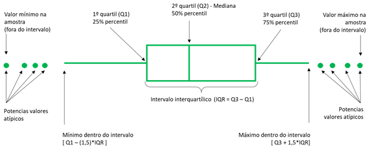

Figura 18: Exemplo de leitura de [boxplot](https://miro.medium.com/v2/1*r41SQj0LbdCV6rWoIos6mA.png)

### 3.3.4 Remuneração Média por Faixa Salarial

A distribuição dos arqueólogos por remuneração média revela um quadro de concentração salarial e perda de mobilidade ascendente. A maior parcela dos profissionais concentra-se na faixa de 2 a 3 salários mínimos, que funciona como um teto estrutural para a categoria. Paralelamente, a faixa de 1 a 2 salários mínimos dobrou de participação, passando de cerca de 10% para mais de 20% dos trabalhadores, sinalizando que uma parcela crescente de profissionais está sendo empurrada para remunerações mais baixas.

No meio da distribuição, as faixas de 3 a 7 salários mínimos encolheram significativamente, especialmente a de 5 a 7 SM, que caiu de 14% para menos de 5%, indicando que o arqueólogo bem remunerado está desaparecendo. No topo, há uma polarização: a faixa de 7 a 10 SM cresceu de forma estável, mas as faixas acima de 15 salários mínimos praticamente desapareceram da amostra.

O resultado é uma profissão com poucas oportunidades de ascensão salarial elevada, onde a maioria se amontoa nas faixas inferiores e apenas uma pequena fração consegue ultrapassar o patamar de 7 salários mínimos.

**Mostrar código executado**

```r
salario.2022 <- remunera_corrigido %>%
  dplyr::filter(Ano==2022 & Vl.Rem.Média.Nom>0) %>%
  mutate(
    faixa_SM = case_when(
      Vl.Rem.Média.Nom <= 1212 ~ "Até 1 salário mínimo",
      Vl.Rem.Média.Nom > 1212 & Vl.Rem.Média.Nom <= (1212*2) ~ "Entre 1 e 2 salários mínimos",
      Vl.Rem.Média.Nom > (1212*2) & Vl.Rem.Média.Nom <= (1212*3) ~ "Entre 2 e 3 salários mínimos",
      Vl.Rem.Média.Nom > (1212*3) & Vl.Rem.Média.Nom <= (1212*4) ~ "Entre 3 e 4 salários mínimos",
      Vl.Rem.Média.Nom > (1212*4) & Vl.Rem.Média.Nom <= (1212*5) ~ "Entre 4 e 5 salários mínimos",
      Vl.Rem.Média.Nom > (1212*5) & Vl.Rem.Média.Nom <= (1212*7) ~ "Entre 5 e 7 salários mínimos",
      Vl.Rem.Média.Nom > (1212*7) & Vl.Rem.Média.Nom <= (1212*10) ~ "Entre 7 e 10 salários mínimos",
      Vl.Rem.Média.Nom > (1212*10) & Vl.Rem.Média.Nom <= (1212*15) ~ "Entre 10 e 15 salários mínimos",
      Vl.Rem.Média.Nom > (1212*15) & Vl.Rem.Média.Nom <= (1212*20) ~ "Entre 15 e 20 salários mínimos",
      Vl.Rem.Média.Nom > (1212*20) ~ "Acima de 20 salários mínimos",
      TRUE ~ NA_character_),
    faixa_valor = case_when(
      Vl.Rem.Média.Nom <= 1212 ~ "Até R$ 1.212",
      Vl.Rem.Média.Nom > 1212 & Vl.Rem.Média.Nom <= (1212*2) ~ "R$ 1.212 a R$ 2.424",
      Vl.Rem.Média.Nom > (1212*2) & Vl.Rem.Média.Nom <= (1212*3) ~ "R$ 2.424 a R$ 3.636",
      Vl.Rem.Média.Nom > (1212*3) & Vl.Rem.Média.Nom <= (1212*4) ~ "R$ 3.636 a R$ 4.848",
      Vl.Rem.Média.Nom > (1212*4) & Vl.Rem.Média.Nom <= (1212*5) ~ "R$ 4.848 a R$ 6.060",
      Vl.Rem.Média.Nom > (1212*5) & Vl.Rem.Média.Nom <= (1212*7) ~ "R$ 6.060 a R$ 8.484",
      Vl.Rem.Média.Nom > (1212*7) & Vl.Rem.Média.Nom <= (1212*10) ~ "R$ 8.484 a R$ 12.120",
      Vl.Rem.Média.Nom > (1212*10) & Vl.Rem.Média.Nom <= (1212*15) ~ "R$ 12.120 a R$ 18.180",
      Vl.Rem.Média.Nom > (1212*15) & Vl.Rem.Média.Nom <= (1212*20) ~ "R$ 18.180 a R$ 24.240",
      Vl.Rem.Média.Nom > (1212*20) ~ "Acima de R$ 24.240",
      TRUE ~ NA_character_)) %>%
  select(Ano, Vl.Rem.Média.Nom, faixa_SM, faixa_valor) %>%
  na.omit()

resumo_salario.2022 <- salario.2022 %>%
group_by(faixa_SM, faixa_valor) %>%
  summarise(quantidade= n()) %>%
  ungroup() %>%
  mutate(porcentagem = round((quantidade / sum(quantidade) * 100),2)) %>%
  dplyr::select(faixa_SM, faixa_valor, quantidade, porcentagem) %>%
  arrange(desc(porcentagem))

tab.resumo_salario.2022 <- resumo_salario.2022 %>%
  dplyr::select(faixa_SM, faixa_valor, porcentagem) %>%
  gt() %>%
  tab_header(
    title = "Distribuição Salarial - Média/2022",
    subtitle = "Salário mínimo de R$ 1.212") %>%
  fmt_number(
    columns = porcentagem,
    decimals = 2, sep_mark = ".", dec_mark = ",") %>%
  text_transform(
    locations = cells_body(columns = porcentagem),
    fn = function(x) paste0(x, "%")) %>%
  cols_label(faixa_SM = gt::html("Faixa de<br>Renda"),
             faixa_valor = gt::html("Valor em<br>Salário Mínimo"),
             porcentagem = gt::html("% de<br>Arqueólogos")) |>
  cols_align(
  align = "center",
  columns = c(porcentagem, faixa_valor, faixa_SM)
)

salario.2023 <- remunera_corrigido %>%
  dplyr::filter(Ano==2023 & Vl.Rem.Média.Nom>0) %>%
  mutate(
    faixa_SM = case_when(
      Vl.Rem.Média.Nom <= 1320 ~ "Até 1 salário mínimo",
      Vl.Rem.Média.Nom > 1320 & Vl.Rem.Média.Nom <= (1320*2) ~ "Entre 1 e 2 salários mínimos",
      Vl.Rem.Média.Nom > (1320*2) & Vl.Rem.Média.Nom <= (1320*3) ~ "Entre 2 e 3 salários mínimos",
      Vl.Rem.Média.Nom > (1320*3) & Vl.Rem.Média.Nom <= (1320*4) ~ "Entre 3 e 4 salários mínimos",
      Vl.Rem.Média.Nom > (1320*4) & Vl.Rem.Média.Nom <= (1320*5) ~ "Entre 4 e 5 salários mínimos",
      Vl.Rem.Média.Nom > (1320*5) & Vl.Rem.Média.Nom <= (1320*7) ~ "Entre 5 e 7 salários mínimos",
      Vl.Rem.Média.Nom > (1320*7) & Vl.Rem.Média.Nom <= (1320*10) ~ "Entre 7 e 10 salários mínimos",
      Vl.Rem.Média.Nom > (1320*10) & Vl.Rem.Média.Nom <= (1320*15) ~ "Entre 10 e 15 salários mínimos",
      Vl.Rem.Média.Nom > (1320*15) & Vl.Rem.Média.Nom <= (1320*20) ~ "Entre 15 e 20 salários mínimos",
      Vl.Rem.Média.Nom > (1320*20) ~ "Acima de 20 salários mínimos",
      TRUE ~ NA_character_),
    faixa_valor = case_when(
      Vl.Rem.Média.Nom <= 1320 ~ "Até R$ 1.320",
      Vl.Rem.Média.Nom > 1320 & Vl.Rem.Média.Nom <= (1320*2) ~ "R$ 1.320 a R$ 2.640",
      Vl.Rem.Média.Nom > (1320*2) & Vl.Rem.Média.Nom <= (1320*3) ~ "R$ 2.640 a R$ 3.960",
      Vl.Rem.Média.Nom > (1320*3) & Vl.Rem.Média.Nom <= (1320*4) ~ "R$ 3.960 a R$ 5.280",
      Vl.Rem.Média.Nom > (1320*4) & Vl.Rem.Média.Nom <= (1320*5) ~ "R$ 5.280 a R$ 6.600",
      Vl.Rem.Média.Nom > (1320*5) & Vl.Rem.Média.Nom <= (1320*7) ~ "R$ 6.600 a R$ 9.240",
      Vl.Rem.Média.Nom > (1320*7) & Vl.Rem.Média.Nom <= (1320*10) ~ "R$ 9.240 a R$ 13.200",
      Vl.Rem.Média.Nom > (1320*10) & Vl.Rem.Média.Nom <= (1320*15) ~ "R$ 13.200 a R$ 19.800",
      Vl.Rem.Média.Nom > (1320*15) & Vl.Rem.Média.Nom <= (1320*20) ~ "R$ 19.800 a R$ 26.400",
      Vl.Rem.Média.Nom > (1320*20) ~ "Acima de R$ 26.400",
      TRUE ~ NA_character_)) %>%
  select(Ano, Vl.Rem.Média.Nom, faixa_SM, faixa_valor) %>%
  na.omit()

resumo_salario.2023 <- salario.2023 %>%
  group_by(faixa_SM, faixa_valor) %>%
  summarise(quantidade= n()) %>%
  ungroup() %>%
  mutate(porcentagem = round((quantidade / sum(quantidade) * 100),2)) %>%
  dplyr::select(faixa_SM, faixa_valor, quantidade, porcentagem) %>%
  arrange(desc(porcentagem))

tab.resumo_salario.2023 <- resumo_salario.2023 %>%
  dplyr::select(faixa_SM, faixa_valor, porcentagem) %>%
  gt() %>%
  tab_header(
    title = "Distribuição Salarial - Média/2023",
    subtitle = "Salário mínimo de R$ 1.320") %>%
  fmt_number(
    columns = porcentagem,
    decimals = 2, sep_mark = ".", dec_mark = ",") %>%
  text_transform(
    locations = cells_body(columns = porcentagem),
    fn = function(x) paste0(x, "%")) %>%
  cols_label(faixa_SM = gt::html("Faixa de<br>Renda"),
             faixa_valor = gt::html("Valor em<br>Salário Mínimo"),
             porcentagem = gt::html("% de<br>Arqueólogos")) |>
  cols_align(
  align = "center",
  columns = c(porcentagem, faixa_valor, faixa_SM)
)
```

```r
salario.2024 <- remunera_corrigido %>%
  dplyr::filter(Ano==2024 & Vl.Rem.Média.Nom>0) %>%
  mutate(
    faixa_SM = case_when(
      Vl.Rem.Média.Nom <= 1412 ~ "Até 1 salário mínimo",
      Vl.Rem.Média.Nom > 1412 & Vl.Rem.Média.Nom <= (1412*2) ~ "Entre 1 e 2 salários mínimos",
      Vl.Rem.Média.Nom > (1412*2) & Vl.Rem.Média.Nom <= (1412*3) ~ "Entre 2 e 3 salários mínimos",
      Vl.Rem.Média.Nom > (1412*3) & Vl.Rem.Média.Nom <= (1412*4) ~ "Entre 3 e 4 salários mínimos",
      Vl.Rem.Média.Nom > (1412*4) & Vl.Rem.Média.Nom <= (1412*5) ~ "Entre 4 e 5 salários mínimos",
      Vl.Rem.Média.Nom > (1412*5) & Vl.Rem.Média.Nom <= (1412*7) ~ "Entre 5 e 7 salários mínimos",
      Vl.Rem.Média.Nom > (1412*7) & Vl.Rem.Média.Nom <= (1412*10) ~ "Entre 7 e 10 salários mínimos",
      Vl.Rem.Média.Nom > (1412*10) & Vl.Rem.Média.Nom <= (1412*15) ~ "Entre 10 e 15 salários mínimos",
      Vl.Rem.Média.Nom > (1412*15) & Vl.Rem.Média.Nom <= (1412*20) ~ "Entre 15 e 20 salários mínimos",
      Vl.Rem.Média.Nom > (1412*20) ~ "Acima de 20 salários mínimos",
      TRUE ~ NA_character_),
    faixa_valor = case_when(
      Vl.Rem.Média.Nom <= 1412 ~ "Até R$ 1.412",
      Vl.Rem.Média.Nom > 1412 & Vl.Rem.Média.Nom <= (1412*2) ~ "R$ 1.412 a R$ 2.824",
      Vl.Rem.Média.Nom > (1412*2) & Vl.Rem.Média.Nom <= (1412*3) ~ "R$ 2.824 a R$ 4.236",
      Vl.Rem.Média.Nom > (1412*3) & Vl.Rem.Média.Nom <= (1412*4) ~ "R$ 4.236 a R$ 5.648",
      Vl.Rem.Média.Nom > (1412*4) & Vl.Rem.Média.Nom <= (1412*5) ~ "R$ 5.648 a R$ 7.060",
      Vl.Rem.Média.Nom > (1412*5) & Vl.Rem.Média.Nom <= (1412*7) ~ "R$ 7.060 a R$ 9.884",
      Vl.Rem.Média.Nom > (1412*7) & Vl.Rem.Média.Nom <= (1412*10) ~ "R$ 9.884 a R$ 14.120",
      Vl.Rem.Média.Nom > (1412*10) & Vl.Rem.Média.Nom <= (1412*15) ~ "R$ 14.120 a R$ 21.180",
      Vl.Rem.Média.Nom > (1412*15) & Vl.Rem.Média.Nom <= (1412*20) ~ "R$ 21.180 a R$ 28.240",
      Vl.Rem.Média.Nom > (1412*20) ~ "Acima de R$ 28.240",
      TRUE ~ NA_character_)) %>%
  select(Ano, Vl.Rem.Média.Nom, faixa_SM, faixa_valor) %>%
  na.omit()

resumo_salario.2024 <- salario.2024 %>%
  group_by(faixa_SM, faixa_valor) %>%
  summarise(quantidade= n()) %>%
  ungroup() %>%
  mutate(porcentagem = round((quantidade / sum(quantidade) * 100),2)) %>%
  dplyr::select(faixa_SM, faixa_valor, quantidade, porcentagem) %>%
  arrange(desc(porcentagem))

tab.resumo_salario.2024 <- resumo_salario.2024 %>%
  dplyr::select(faixa_SM, faixa_valor, porcentagem) %>%
  gt() %>%
  tab_header(
    title = "Distribuição Salarial - Média/2024",
    subtitle = "Salário mínimo de R$ 1.412") %>%
  fmt_number(
    columns = porcentagem,
    decimals = 2, sep_mark = ".", dec_mark = ",") %>%
  text_transform(
    locations = cells_body(columns = porcentagem),
    fn = function(x) paste0(x, "%")) %>%
  cols_label(faixa_SM = gt::html("Faixa de<br>Renda"),
             faixa_valor = gt::html("Valor em<br>Salário Mínimo"),
             porcentagem = gt::html("% de<br>Arqueólogos")) |>
  cols_align(
  align = "center",
  columns = c(porcentagem, faixa_valor, faixa_SM)
)

salario.2025 <- remunera_corrigido %>%
  dplyr::filter(Ano==2025 & Vl.Rem.Média.Nom>0) %>%
  mutate(
    faixa_SM = case_when(
      Vl.Rem.Média.Nom <= 1518 ~ "Até 1 salário mínimo",
      Vl.Rem.Média.Nom > 1518 & Vl.Rem.Média.Nom <= (1518*2) ~ "Entre 1 e 2 salários mínimos",
      Vl.Rem.Média.Nom > (1518*2) & Vl.Rem.Média.Nom <= (1518*3) ~ "Entre 2 e 3 salários mínimos",
      Vl.Rem.Média.Nom > (1518*3) & Vl.Rem.Média.Nom <= (1518*4) ~ "Entre 3 e 4 salários mínimos",
      Vl.Rem.Média.Nom > (1518*4) & Vl.Rem.Média.Nom <= (1518*5) ~ "Entre 4 e 5 salários mínimos",
      Vl.Rem.Média.Nom > (1518*5) & Vl.Rem.Média.Nom <= (1518*7) ~ "Entre 5 e 7 salários mínimos",
      Vl.Rem.Média.Nom > (1518*7) & Vl.Rem.Média.Nom <= (1518*10) ~ "Entre 7 e 10 salários mínimos",
      Vl.Rem.Média.Nom > (1518*10) & Vl.Rem.Média.Nom <= (1518*15) ~ "Entre 10 e 15 salários mínimos",
      Vl.Rem.Média.Nom > (1518*15) & Vl.Rem.Média.Nom <= (1518*20) ~ "Entre 15 e 20 salários mínimos",
      Vl.Rem.Média.Nom > (1518*20) ~ "Acima de 20 salários mínimos",
      TRUE ~ NA_character_),
    faixa_valor = case_when(
      Vl.Rem.Média.Nom <= 1518 ~ "Até R$ 1.518",
      Vl.Rem.Média.Nom > 1518 & Vl.Rem.Média.Nom <= (1518*2) ~ "R$ 1.518 a R$ 3.036",
      Vl.Rem.Média.Nom > (1518*2) & Vl.Rem.Média.Nom <= (1518*3) ~ "R$ 3.036 a R$ 4.554",
      Vl.Rem.Média.Nom > (1518*3) & Vl.Rem.Média.Nom <= (1518*4) ~ "R$ 4.554 a R$ 6.072",
      Vl.Rem.Média.Nom > (1518*4) & Vl.Rem.Média.Nom <= (1518*5) ~ "R$ 6.072 a R$ 7.590",
      Vl.Rem.Média.Nom > (1518*5) & Vl.Rem.Média.Nom <= (1518*7) ~ "R$ 7.590 a R$ 10.626",
      Vl.Rem.Média.Nom > (1518*7) & Vl.Rem.Média.Nom <= (1518*10) ~ "R$ 10.626 a R$ 15.180",
      Vl.Rem.Média.Nom > (1518*10) & Vl.Rem.Média.Nom <= (1518*15) ~ "R$ 15.180 a R$ 22.770",
      Vl.Rem.Média.Nom > (1518*15) & Vl.Rem.Média.Nom <= (1518*20) ~ "R$ 22.770 a R$ 30.360",
      Vl.Rem.Média.Nom > (1518*20) ~ "Acima de R$ 30.360",
      TRUE ~ NA_character_)) %>%
  select(Ano, Vl.Rem.Média.Nom, faixa_SM, faixa_valor) %>%
  na.omit()

resumo_salario.2025 <- salario.2025 %>%
  group_by(faixa_SM, faixa_valor) %>%
  summarise(quantidade= n()) %>%
  ungroup() %>%
  mutate(porcentagem = round((quantidade / sum(quantidade) * 100),2)) %>%
  dplyr::select(faixa_SM, faixa_valor, quantidade, porcentagem) %>%
  arrange(desc(porcentagem))

tab.resumo_salario.2025 <- resumo_salario.2025 %>%
  dplyr::select(faixa_SM, faixa_valor, porcentagem) %>%
  gt() %>%
  tab_header(
    title = "Distribuição Salarial - Média/2025",
    subtitle = "Salário mínimo de R$ 1.518") %>%
  fmt_number(
    columns = porcentagem,
    decimals = 2, sep_mark = ".", dec_mark = ",") %>%
  text_transform(
    locations = cells_body(columns = porcentagem),
    fn = function(x) paste0(x, "%")) %>%
  cols_label(faixa_SM = gt::html("Faixa de<br>Renda"),
             faixa_valor = gt::html("Valor em<br>Salário Mínimo"),
             porcentagem = gt::html("% de<br>Arqueólogos")) |>
  cols_align(
  align = "center",
  columns = c(porcentagem, faixa_valor, faixa_SM)
)
```

```r
html_2022 <- gt::as_raw_html(tab.resumo_salario.2022)
html_2023 <- gt::as_raw_html(tab.resumo_salario.2023)
html_2024 <- gt::as_raw_html(tab.resumo_salario.2024)
html_2025 <- gt::as_raw_html(tab.resumo_salario.2025)

htmltools::tagList(
  htmltools::tags$div(
    class = "tabelas-side-by-side",
    htmltools::tags$div(style = "flex: 1 1 0; min-width: 0;", htmltools::HTML(html_2022)),
    htmltools::tags$div(style = "flex: 1 1 0; min-width: 0;", htmltools::HTML(html_2023)),
    htmltools::tags$div(style = "flex: 1 1 0; min-width: 0;", htmltools::HTML(html_2024)),
    htmltools::tags$div(style = "flex: 1 1 0; min-width: 0;", htmltools::HTML(html_2025))
  )
)
```

Distribuição Salarial - Média/2022

Salário mínimo de R$ 1.212

| Faixa de Renda | Valor em Salário Mínimo | % de Arqueólogos |
| --- | --- | --- |
| Entre 2 e 3 salários mínimos | R$ 2.424 a R$ 3.636 | 25,48% |
| Entre 3 e 4 salários mínimos | R$ 3.636 a R$ 4.848 | 23,95% |
| Entre 4 e 5 salários mínimos | R$ 4.848 a R$ 6.060 | 14,83% |
| Entre 5 e 7 salários mínimos | R$ 6.060 a R$ 8.484 | 14,07% |
| Entre 1 e 2 salários mínimos | R$ 1.212 a R$ 2.424 | 9,89% |
| Entre 7 e 10 salários mínimos | R$ 8.484 a R$ 12.120 | 6,84% |
| Entre 15 e 20 salários mínimos | R$ 18.180 a R$ 24.240 | 2,28% |
| Até 1 salário mínimo | Até R$ 1.212 | 1,90% |
| Entre 10 e 15 salários mínimos | R$ 12.120 a R$ 18.180 | 0,76% |

Distribuição Salarial - Média/2023

Salário mínimo de R$ 1.320

| Faixa de Renda | Valor em Salário Mínimo | % de Arqueólogos |
| --- | --- | --- |
| Entre 2 e 3 salários mínimos | R$ 2.640 a R$ 3.960 | 31,99% |
| Entre 3 e 4 salários mínimos | R$ 3.960 a R$ 5.280 | 24,58% |
| Entre 1 e 2 salários mínimos | R$ 1.320 a R$ 2.640 | 12,12% |
| Entre 4 e 5 salários mínimos | R$ 5.280 a R$ 6.600 | 10,77% |
| Entre 7 e 10 salários mínimos | R$ 9.240 a R$ 13.200 | 8,42% |
| Entre 5 e 7 salários mínimos | R$ 6.600 a R$ 9.240 | 8,08% |
| Até 1 salário mínimo | Até R$ 1.320 | 1,35% |
| Entre 10 e 15 salários mínimos | R$ 13.200 a R$ 19.800 | 1,35% |
| Entre 15 e 20 salários mínimos | R$ 19.800 a R$ 26.400 | 1,35% |

Distribuição Salarial - Média/2024

Salário mínimo de R$ 1.412

| Faixa de Renda | Valor em Salário Mínimo | % de Arqueólogos |
| --- | --- | --- |
| Entre 2 e 3 salários mínimos | R$ 2.824 a R$ 4.236 | 27,62% |
| Entre 3 e 4 salários mínimos | R$ 4.236 a R$ 5.648 | 22,22% |
| Entre 1 e 2 salários mínimos | R$ 1.412 a R$ 2.824 | 20,00% |
| Entre 4 e 5 salários mínimos | R$ 5.648 a R$ 7.060 | 10,79% |
| Entre 7 e 10 salários mínimos | R$ 9.884 a R$ 14.120 | 8,57% |
| Entre 5 e 7 salários mínimos | R$ 7.060 a R$ 9.884 | 6,67% |
| Até 1 salário mínimo | Até R$ 1.412 | 2,86% |
| Acima de 20 salários mínimos | Acima de R$ 28.240 | 0,63% |
| Entre 10 e 15 salários mínimos | R$ 14.120 a R$ 21.180 | 0,63% |

Distribuição Salarial - Média/2025

Salário mínimo de R$ 1.518

| Faixa de Renda | Valor em Salário Mínimo | % de Arqueólogos |
| --- | --- | --- |
| Entre 2 e 3 salários mínimos | R$ 3.036 a R$ 4.554 | 27,53% |
| Entre 1 e 2 salários mínimos | R$ 1.518 a R$ 3.036 | 20,57% |
| Entre 3 e 4 salários mínimos | R$ 4.554 a R$ 6.072 | 18,35% |
| Entre 4 e 5 salários mínimos | R$ 6.072 a R$ 7.590 | 12,66% |
| Entre 7 e 10 salários mínimos | R$ 10.626 a R$ 15.180 | 8,86% |
| Entre 5 e 7 salários mínimos | R$ 7.590 a R$ 10.626 | 4,75% |
| Até 1 salário mínimo | Até R$ 1.518 | 3,16% |
| Entre 10 e 15 salários mínimos | R$ 15.180 a R$ 22.770 | 3,16% |
| Entre 15 e 20 salários mínimos | R$ 22.770 a R$ 30.360 | 0,63% |
| Acima de 20 salários mínimos | Acima de R$ 30.360 | 0,32% |

### 3.3.5 Distribuição por Sexo

A evolução da média salarial de dezembro por sexo entre 2022 a 2025 revelou um padrão oscilatório inesperado, com duas inversões de vantagem e variações de magnitude significativa. A trajetória pode ser descrita em quatro momentos distintos:

Em 2022, as arqueólogas apresentavam média salarial de R$ 5.708,83, contra R$ 5.085,01 dos arqueólogos - uma vantagem de R$ 623,82 que se manteve como a maior diferença do período. No ano seguinte, essa vantagem se reduziu para R$ 273,32 (R$ 5.563,63 vs. R$ 5.290,31), sugerindo que os homens estavam ganhando terreno de forma gradual.

A primeira inversão ocorreu em 2024: a média masculina saltou para R$ 5.615,93, enquanto a feminina recuou para R$ 5.358,61 - uma diferença de −R$ 257,32 em favor dos homens.

Contudo, a tendência não se consolidou. Em 2025, o padrão se reverteu de forma ainda mais acentuada: a média feminina disparou para R$ 6.144,29 (+14,6% em relação a 2024), enquanto a masculina avançou modestamente para R$ 5.648,15 (+0,6%). O resultado foi uma nova vantagem feminina de R$ 496,14.

Esse vaivém sugere que a remuneração por sexo se mostrou altamente sensível a fatores conjunturais ocorridos no biênio 2023-2024. A inversão de 2024 pode ter sido impulsionada por um conjunto específico de contratações masculinas em faixas salariais superiores, enquanto a reversão de 2025 indica que as arqueólogas se beneficiaram de reajustes ou novas contratações em patamares mais elevados.

A análise da distribuição salarial pode revelar novas informações desse padrão observado na média.

**Mostrar código executado**

```r
media_anual_dez_masc <- remunera_corrigido %>%
  dplyr::filter(Sexo=="MASCULINO" & vl.rem.dez.nom.corrigido>0) %>%
  group_by(Ano) %>%
  summarise_at(vars(vl.rem.dez.nom.corrigido), list(media_masculino = ~ round(mean(., na.rm = TRUE),2)))

media_anual_dez_fem <- remunera_corrigido %>%
  dplyr::filter(Sexo=="FEMININO" & vl.rem.dez.nom.corrigido>0) %>%
  group_by(Ano) %>%
  summarise_at(vars(vl.rem.dez.nom.corrigido), list(media_feminino = ~ round(mean(., na.rm = TRUE),2)))

media_sexos <- full_join(media_anual_dez_fem, media_anual_dez_masc, by= NULL)

media_sexos2 <- media_sexos %>%
  pivot_longer(-Ano, names_to = "Sexo", values_to = "Média_Dezembro") %>%
  mutate(Sexo = recode(Sexo,
                        media_feminino = "FEMININO",
                        media_masculino = "MASCULINO")) %>%
  mutate(Sexo = factor(Sexo,
                       levels = c("FEMININO", "MASCULINO")),
                Ano = as.factor(Ano))

media_sexos2 %>%
  group_by(Sexo) %>%
  e_charts(Ano, timeline = FALSE) %>%
  e_bar(Média_Dezembro, stack = FALSE) %>%
  e_flip_coords() %>%
  e_y_axis(inverse = TRUE, axisLabel = list(fontSize = 9)) %>%
  e_x_axis(
    axisLabel = list(
      fontSize = 10,
      formatter = htmlwidgets::JS("
        function(value) {
          return 'R$ ' + value.toFixed(2)
            .replace('.', ',')
            .replace(/(\\d)(?=(\\d{3})+(?!\\d))/g, '$1.');
        }
      ")
    ),
    axisLine = list(show = TRUE),
    splitLine = list(show = FALSE)
  ) %>%
  e_title(
    text = "Mercado de Trabalho Formal de Arqueólogos - RAIS 2022 a 2025",
    subtext = "Média Salarial de Dezembro por Sexo",
    left = "center",
    textStyle = list(fontSize = 15, fontWeight = "bold"),
    subtextStyle = list(fontSize = 12, fontWeight = "bold")
  ) %>%
  e_color(c("#D55E00", "#00868B")) %>%
  e_grid(containLabel = TRUE, left = "10%", right = "5%") %>%
  e_tooltip(
    extraCssText = "text-align: left;",
    trigger = "axis",
    formatter = htmlwidgets::JS("
      function(params) {
        var ano = params[0].axisValue;
        var result = 'Ano: ' + ano + '<br/>';
        params.forEach(function(p) {
          var valor = p.value[0];
          // Garantir que valor é número antes de chamar toFixed
          if (typeof valor === 'number') {
            var valorFormatado = 'R$ ' + valor.toFixed(2)
              .replace('.', ',')
              .replace(/(\\d)(?=(\\d{3})+(?!\\d))/g, '$1.');
          } else {
            var valorFormatado = 'R$ ' + parseFloat(valor).toFixed(2)
              .replace('.', ',')
              .replace(/(\\d)(?=(\\d{3})+(?!\\d))/g, '$1.');
          }
          result += p.marker + ' ' + p.seriesName + ': ' + valorFormatado + '<br/>';
        });
        return result;
      }
    ")
  )
```

[interactive chart not shown]

Figura 19: Média remuneratória de dezembro por sexo

Pela tabela abaixo, observa-se que a mediana alterna entre os sexos ao longo do período, com diferenças pequenas em 2023 e 2024. Apenas em 2025 que a vantagem feminina se torna expressiva (R$ 648,62 ou 14,4%), bem como a média feminina também ultrapassa a masculina - diferença já documentada na análise acima.

No quartil inferior (Q1), a vantagem feminina também se consolida em 2025, com as trabalhadoras recebendo cerca de 19% a mais que os homens nesse estrato (diferença de R$ 568,46) - indicando que, mesmo entre os menores salários, as arqueólogas estão em posição relativamente melhor. No terço superior (Q3), as mulheres mantêm uma diferença positiva e consistente ao longo de todo o período, mostrando que, quando alcançam o quartil superior, sua remuneração supera a dos homens nesse mesmo patamar.

A base remuneratória também reforça essa vantagem: o mínimo feminino saltou de R$ 393,17 para R$ 1.518 (+286% no acumulado) entre 2022 e 2025, enquanto o masculino cresceu apenas 55% (R$ 393,17 → R$ 610,89).

Uma hipótese para explicar a alternância observada nos extremos salariais é que os supersalários constituem eventos episódicos, e não atributos permanentes de indivíduos específicos. O máximo masculino de 2024 provavelmente corresponde a um contrato pontual de alto valor que não se repetiu em 2025. O máximo feminino, por sua vez, oscilou entre R$ 18.298,50 e R$ 27.103,79, sugerindo que as mulheres também acessam, mas não chegam a dominar os picos remuneratórios.

**Mostrar código executado**

```r
resumo_remunera_sexos <- remunera_corrigido %>%
  dplyr::filter(vl.rem.dez.nom.corrigido>0) |>
  mutate(Sexo = recode(Sexo,
                       "FEMININO" = "Feminino",
                       "MASCULINO" = "Masculino")) %>%
  group_by(Ano, Sexo) %>%
  summarise(
    Mínimo = min(vl.rem.dez.nom.corrigido, na.rm = TRUE),
    Q1 = quantile(vl.rem.dez.nom.corrigido, 0.25, na.rm = TRUE),
    Mediana = median(vl.rem.dez.nom.corrigido, na.rm = TRUE),
    Média = mean(vl.rem.dez.nom.corrigido, na.rm = TRUE),
    Q3 = quantile(vl.rem.dez.nom.corrigido, 0.75, na.rm = TRUE),
    Máximo = max(vl.rem.dez.nom.corrigido, na.rm = TRUE),
    .groups = "drop"
  ) %>%
  mutate(across(where(is.numeric), ~ round(., 2))) %>%
  pivot_longer(
    cols = c(Mínimo, Q1, Mediana, Média, Q3, Máximo),
    names_to = "Estatística",
    values_to = "Valor"
  ) %>%
  pivot_wider(
    names_from = Ano,
    values_from = Valor
  )

tabela_sexos <- resumo_remunera_sexos %>%
  gt(
    rowname_col = "Sexo",
    groupname_col = "Estatística") %>%
  tab_header(
    title = "Resumo Estatístico",
    subtitle = "Valores Remuneratórios de Dezembro por Sexo") %>%
  fmt_number(
    columns = where(is.numeric),
    decimals = 2,
    sep_mark = ".",
    dec_mark = ",",
    pattern = "R$ {x}"
  ) %>%
  tab_spanner(
    label = "Ano",
    columns = where(is.numeric)) %>%
  cols_align(
    align = "center",
    columns = where(is.numeric)) %>%
  tab_style(
    style = cell_text(weight = "bold"),
    locations = cells_row_groups())

tabela_sexos
```

Tabela 5: Medidas de posição das remunerações nominais de dezembro dos vínculos ativos por sexo

Resumo Estatístico

Valores Remuneratórios de Dezembro por Sexo

|  | Ano 2022 | Ano 2023 | Ano 2024 | Ano 2025 |
| --- | --- | --- | --- | --- |
| Mínimo |  |  |  |  |
| Feminino | R$ 393,17 | R$ 1.320,00 | R$ 799,40 | R$ 1.518,00 |
| Masculino | R$ 393,17 | R$ 523,56 | R$ 547,11 | R$ 610,89 |
| Q1 |  |  |  |  |
| Feminino | R$ 3.540,11 | R$ 3.196,81 | R$ 3.013,49 | R$ 3.564,68 |
| Masculino | R$ 3.451,96 | R$ 3.067,50 | R$ 3.196,84 | R$ 2.996,22 |
| Mediana |  |  |  |  |
| Feminino | R$ 4.395,34 | R$ 4.661,66 | R$ 4.652,41 | R$ 5.148,62 |
| Masculino | R$ 4.526,70 | R$ 4.453,31 | R$ 4.673,98 | R$ 4.500,00 |
| Média |  |  |  |  |
| Feminino | R$ 5.708,83 | R$ 5.563,63 | R$ 5.358,61 | R$ 6.144,29 |
| Masculino | R$ 5.085,01 | R$ 5.290,31 | R$ 5.615,93 | R$ 5.648,15 |
| Q3 |  |  |  |  |
| Feminino | R$ 7.054,72 | R$ 6.584,56 | R$ 6.300,58 | R$ 6.699,66 |
| Masculino | R$ 5.869,00 | R$ 6.126,40 | R$ 6.162,04 | R$ 6.313,59 |
| Máximo |  |  |  |  |
| Feminino | R$ 25.690,79 | R$ 27.103,79 | R$ 18.298,50 | R$ 24.420,84 |
| Masculino | R$ 25.298,00 | R$ 22.352,96 | R$ 33.710,08 | R$ 30.597,00 |

## 3.4 Análise dos Vínculos Desligados em 31/12

Os gráficos seguintes são relativos as declarações de trabalhadores que não permaneceram em seus postos de trabalho até o final do ano. Assim, a filtragem dos registros será dada pela coluna `Ind.Vínculo.Ativo.31.12 == "NÃO"`, em que o `NÃO` representa os vínculos desligados.

### 3.4.1 Motivo do Desligamento

A análise dos vínculos desligados revelou dinamismo na movimentação de desligamentos, cujos padrões se reconfiguraram em três fases distintas ao longo do período longitudinal.

Em 2023, o mercado de trabalho exibiu uma situação atípico de mobilidade voluntária: os pedidos de demissão quase dobraram em relação a 2022 (22 → 36), enquanto as demissões por iniciativa do empregador e os términos de contrato por prazo determinado recuaram (78 → 63 e 32 → 24). Esse padrão sugere que a retomada pós-pandemia de grandes projetos de licenciamento ambiental ampliou as oportunidades de escolha dos profissionais ou que a migração para o regime MEI (Microempreendedor Individual) atraiu arqueólogos para fora do mercado formal.

Em 2024, o padrão retornou ao nível de 2022, com queda expressiva nos pedidos de demissão por iniciativa do empregado (36 → 23). A reversão indica que o pico de 2023 foi um evento conjuntural, não uma tendência estrutural. A estabilização indica uma menor disponibilidade de oportunidades vantajosas para os trabalhadores.

Em 2025, o campo laboral se reconfigurou novamente: pedidos de encerramento de vínculos e demissões patronais voltaram a crescer, enquanto os términos de contrato por prazo determinado despencaram −59,4% em relação a 2024 (32 → 13). Essa queda abrupta sugere que houve menos contratos temporários formalizados ou convertidos em vínculos indeterminados.

Paralelamente, as transferências entre empregadores cresceram de forma constante, indicando uma maior articulação entre consultorias para alocação de profissionais especializados em projetos específicos. E as demissões por acordo mantiveram participação no quadriênio, sinalizando que a rescisão negociada também é um mecanismo utilizado na profissão.

**Mostrar código executado**

```r
desligados <- Arqueo.RAIS.2022_2025 %>%
  dplyr::filter(Ind.Vínculo.Ativo.31.12=='NÃO') %>%
  mutate(Motivo.Desligamento = recode(Motivo.Desligamento,
                           "DEM SEM JC" = "Rescisão sem Justa Causa - Empregador",
                           "DESL POR ACORDO" = "Rescisão por Acordo",
                           "DESL SEM JC" = "Rescisão sem Justa Causa - Empregado",
                           "FALECIMENTO" = "Falecimento",
                           "POSS OUT CAR" = "Posse em Outro Cargo Inacumulável",
                           "TERM CONTR" = "Término do Contrato de Trabalho",
                           "TRANS S/ONUS" = "Transferência de Empregado sem Ônus")) %>%
  group_by(Ano, Motivo.Desligamento) %>%
  summarise(quantidade= n()) %>%
  dplyr::select(Ano, Motivo.Desligamento, quantidade) %>%
  mutate(Motivo.Desligamento = factor(Motivo.Desligamento,
                           levels = c("Rescisão sem Justa Causa - Empregador",
                                      "Rescisão sem Justa Causa - Empregado",
                                      "Término do Contrato de Trabalho",
                                      "Transferência de Empregado sem Ônus",
                                      "Rescisão por Acordo",
                                      "Posse em Outro Cargo Inacumulável", "Falecimento"))) |>
  mutate(Ano = as.factor(Ano))

desligados |>
  group_by(Motivo.Desligamento) |>
  e_charts(Ano) |>
  e_bar(quantidade) |>
  e_title(
    text = "Mercado de Trabalho Formal de Arqueólogos - RAIS 2022 a 2025",
    subtext = "Distribuição dos Motivos do Desligamento",
    left = "center",
    textStyle = list(fontSize = 15, fontWeight = "bold"),
    subtextStyle = list(fontSize = 12, fontWeight = "bold")
  ) %>%
  e_tooltip(
    extraCssText = "text-align: left;",
    trigger = "item",
    formatter = htmlwidgets::JS("
      function(params) {
        return 'Ano: ' + params.name + '<br/>' +
               params.marker + ' ' + params.seriesName + ': ' + params.value[1];
      }
    ")
  )
```

[interactive chart not shown]

Figura 20: Declarações desligadas por motivo de saída

### 3.4.2 Desligamento por Sexo

O desligamento por sexo revela um contraste entre os gêneros que reflete, em parte, a própria evolução dos vínculos ativos. Os arqueólogos lideram numericamente as saídas do mercado formal, mas essa liderança vem encolhendo progressivamente ao longo do período - um reflexo direto do crescimento dos vínculos ativos masculinos, que mantém mais homens no mercado e, consequentemente, reduz o volume de desligamentos.

As arqueólogas, por outro lado, apresentaram um comportamento distinto. O aumento nos vínculos ativos femininos não se traduziu em redução proporcional nas saídas. Os desligamentos desse gênero sobem em ritmo acelerado (+46,8% no acumulado), indicando que a entrada de novas arqueólogas no mercado formal não está sendo acompanhada pela mesma taxa de retenção observada entre os homens.

Em 2025, os números absolutos de desligamentos se cruzam, com 69 saídas registradas para cada sexo. Contudo, interpretar esses valores absolutos isoladamente é enganoso, pois o estoque total de vínculos ativos cresceu 30,27% no quadriênio. Um volume estável de saídas sobre uma base maior significa, na verdade, menor rotatividade relativa. O melhor indicador comparável para essa análise é, portanto, a taxa de desligamento, conforme mostrado na Tabela 6.

**Mostrar código executado**

```r
sexo.desligado <- Arqueo.RAIS.2022_2025 %>%
  dplyr::filter(Ind.Vínculo.Ativo.31.12=='NÃO') %>%
  group_by(Ano, Sexo) %>%
  summarise(quant.sexo= n()) %>%
  ungroup() %>%
  dplyr::select(Ano, Sexo, quant.sexo) |>
  mutate(Ano = as.factor(Ano),
  Sexo = factor(Sexo,
                           levels = c("MASCULINO", "FEMININO")))

sexo.desligado %>%
  group_by(Sexo) %>%
  e_charts(Ano, timeline = FALSE) %>%
  e_bar(quant.sexo, stack = FALSE) %>%
  e_flip_coords() %>%
  e_y_axis(inverse = TRUE, axisLabel = list(fontSize = 9)) %>%
  e_x_axis(
    axisLabel = list(fontSize = 9),
    splitLine = list(show = FALSE), axisLine = list(show = TRUE)
  ) %>%
  e_title(
    text = "Mercado de Trabalho Formal de Arqueólogos - RAIS 2022 a 2025",
    subtext = "Distribuição dos Vínculos Desligados por Sexo",
    left = "center",
    textStyle = list(fontSize = 15, fontWeight = "bold"),
    subtextStyle = list(fontSize = 12, fontWeight = "bold")
  ) %>%
  e_color(c("#00868B", "#D55E00")) %>%
  e_grid(containLabel = TRUE, left = "10%", right = "5%") %>%
  e_tooltip(
    extraCssText = "text-align: left;",
    trigger = "axis",
    formatter = htmlwidgets::JS("
      function(params) {
        var ano = params[0].axisValue;
        var result = 'Ano: ' + ano + '<br/>';
        params.forEach(function(p) {
          result += p.marker + ' ' + p.seriesName + ': ' + p.value[0] + '<br/>';
        });
        return result;
      }
    ")
  )
```

[interactive chart not shown]

Figura 21: Declarações desligadas por sexo

Nesse recorte, o quadro se inverte. A taxa geral de desligamento recuou de 31,94% em 2022 para 26,49% em 2025, evidenciando que a rotatividade da categoria diminuiu em termos proporcionais, ainda que o número absoluto de saídas tenha permanecido praticamente estável em 138 registros nos dois extremos do período. Quando se desagrega por sexo, porém, os movimentos vão em sentidos opostos: a taxa masculina caiu de forma contínua, de 34,73% para 24,04%, enquanto a taxa feminina subiu, de 27,65% para 29,49%.

É por isso que o aparente empate observado em 2025 (69 desligamentos) mascara uma realidade distinta: essas saídas incidem sobre bases muito desiguais - 234 declarações femininas contra 287 masculinas. Em outras palavras, a entrada crescente de arqueólogas no mercado formal não tem sido acompanhada pela mesma capacidade de retenção que o mercado oferece aos arqueólogos, resultando em uma taxa de rotatividade feminina que, ao contrário da masculina, vem se agravando ao longo do período.

**Mostrar código executado**

```r
taxa_geral <- Arqueo.RAIS.2022_2025 %>%
  group_by(Ano) %>%
  summarise(
    Ativos     = sum(Ind.Vínculo.Ativo.31.12 == "SIM"),
    Desligados = sum(Ind.Vínculo.Ativo.31.12 == "NÃO"),
    .groups = "drop"
  ) %>%
  mutate(
    Total = Ativos + Desligados,
    Taxa  = round(Desligados / Total * 100, 2),
    Grupo = "Total"
  )

taxa_sexo <- Arqueo.RAIS.2022_2025 %>%
  group_by(Ano, Sexo) %>%
  summarise(
    Ativos     = sum(Ind.Vínculo.Ativo.31.12 == "SIM"),
    Desligados = sum(Ind.Vínculo.Ativo.31.12 == "NÃO"),
    .groups = "drop"
  ) %>%
  mutate(
    Total = Ativos + Desligados,
    Taxa  = round(Desligados / Total * 100, 2),
    Grupo = dplyr::recode(Sexo, "FEMININO" = "Feminino", "MASCULINO" = "Masculino")
  ) %>%
  dplyr::select(-Sexo)

tabela_taxa <- bind_rows(taxa_geral, taxa_sexo) %>%
  mutate(Grupo = factor(Grupo, levels = c("Total", "Feminino", "Masculino"))) %>%
  dplyr::select(Grupo, Ano, Ativos, Desligados, Total, Taxa) %>%
  arrange(Grupo, Ano) %>%
  gt(rowname_col = "Ano", groupname_col = "Grupo") %>%
  tab_header(
    title    = "Taxa de Desligamento",
    subtitle = "Vínculos encerrados sobre o total de declarações do ano-base"
  ) %>%
  cols_label(
    Ativos     = "Ativos em 31/12",
    Desligados = "Desligados",
    Total      = "Total declarado",
    Taxa       = gt::html("Taxa de<br>desligamento")
  ) %>%
  fmt_integer(columns = c(Ativos, Desligados, Total), sep_mark = ".") %>%
  fmt_number(columns = Taxa, decimals = 2, dec_mark = ",", pattern = "{x}%") %>%
  cols_align(align = "center", columns = c(Ativos, Desligados, Total, Taxa)) %>%
  tab_style(style = cell_text(weight = "bold"), locations = cells_row_groups()) %>%
  tab_style(
    style     = list(cell_text(weight = "bold", color = "#2c5f8a"),
                     cell_fill(color = "#eef4fb")),
    locations = cells_body(columns = Taxa)
  ) %>%
  tab_source_note(
    source_note = gt::md("Taxa = desligados ÷ (ativos + desligados) × 100")
  )

tabela_taxa
```

Tabela 6: Taxa de desligamento dos vínculos declarados - geral e por sexo

Taxa de Desligamento

Vínculos encerrados sobre o total de declarações do ano-base

|  | Ativos em 31/12 | Desligados | Total declarado | Taxa de desligamento |
| --- | --- | --- | --- | --- |
| Total |  |  |  |  |
| 2022 | 294 | 138 | 432 | 31,94% |
| 2023 | 341 | 134 | 475 | 28,21% |
| 2024 | 372 | 142 | 514 | 27,63% |
| 2025 | 383 | 138 | 521 | 26,49% |
| Feminino |  |  |  |  |
| 2022 | 123 | 47 | 170 | 27,65% |
| 2023 | 147 | 49 | 196 | 25,00% |
| 2024 | 165 | 68 | 233 | 29,18% |
| 2025 | 165 | 69 | 234 | 29,49% |
| Masculino |  |  |  |  |
| 2022 | 171 | 91 | 262 | 34,73% |
| 2023 | 194 | 85 | 279 | 30,47% |
| 2024 | 207 | 74 | 281 | 26,33% |
| 2025 | 218 | 69 | 287 | 24,04% |

Taxa = desligados ÷ (ativos + desligados) × 100

# 4 Novo CAGED

O Novo CAGED (Brasil. Ministério do Trabalho e Emprego, 2026c) é a base de dados do governo federal que registra mensalmente as admissões e desligamentos de trabalhadores vinculados ao regime da CLT. Sua publicação tempestiva o consolida como o principal instrumento de monitoramento do mercado de trabalho formal brasileiro. A fonte contempla exclusivamente vínculos celetistas, não incluindo contratações sob regime estatutário.

O indicador-chave para esta análise é o saldo de emprego, calculado pela fórmula `Saldo=Admitidos−Desligamento`. Embora a base não forneça o saldo diretamente, ele é derivado da coluna `saldomovimentação`, que registra separadamente cada admissão e desligamento. O saldo funciona como um termômetro do dinamismo no contrato laboral: valores positivos indicam criação de vagas, enquanto os números negativos apontam fechamento de postos de trabalho.

A tabela interativa abaixo exibe todas as declarações referentes à ocupação de arqueólogo no Novo CAGED de 2022 a 2025.

**Mostrar código executado**

```r
# Converte todas as colunas de texto para fator
caged_tabela <- Arqueo.CAGED.2022_2025 %>%
  mutate(across(where(is.character), as.factor)) |>
  mutate(anocompetênciamov = as.factor(anocompetênciamov))

DT::datatable(
  caged_tabela,
  filter     = 'top',
  extensions = 'Buttons',
  options = list(
    dom = 'Bfrtip',
    buttons = list(
      list(extend = 'copy',  text = 'Copiar'),
      list(extend = 'csv',   text = 'Baixar CSV',
           filename = 'Novo_CAGED_arqueologos_2022_2025'),
      list(extend = 'excel', text = 'Baixar Excel',
           filename = 'Novo_CAGED_arqueologos_2022_2025',
           title    = 'Novo CAGED — CBO 2511-10 — 2022 a 2025')
    ),
    language = list(
       search        = "Filtrar:",
       lengthMenu    = "Mostrar _MENU_ registros",
       info          = "Mostrando _START_ a _END_ de _TOTAL_ registros",
       infoEmpty     = "Nenhum registro",
       infoFiltered  = "(filtrados de _MAX_ registros)",
       zeroRecords   = "Nenhum registro encontrado",
       paginate      = list(previous = "Anterior", `next` = "Próximo",
                            first = "Primeiro", last = "Último")
    ),
    pageLength = 5,
    autoWidth  = TRUE,
    columnDefs = list(list(className = 'dt-nowrap', targets = "_all")),
    scrollX    = TRUE
  )
)
```

Tabela 7: Conjunto geral de dados do Novo CAGED 2022 a 2025

|  | anocompetênciamov | mêscompetênciamov | região | uf | município | seção | subclasse | saldomovimentação | cbo2002ocupação | categoria | graudeinstrução | idade | horascontratuais | raçacor | sexo | tipoempregador | tipoestabelecimento | tipomovimentação | tipodedeficiência | indtrabintermitente | indtrabparcial | salário | tamestabjan | indicadoraprendiz | origemdainformação | competênciadec | competênciaexc | indicadordeexclusão | indicadordeforadoprazo | … |
| --- | --- | --- | --- | --- | --- | --- | --- | --- | --- | --- | --- | --- | --- | --- | --- | --- | --- | --- | --- | --- | --- | --- | --- | --- | --- | --- | --- | --- | --- | --- |
| 1 | 2021 | Outubro | Norte | Amazonas | Am-Manaus | Comércio, Reparação de Veículos Automotores e Motocicletas | Comércio Atacadista de Suprimentos para Informática | Desligado | Arqueologo | Empregado - Geral, inclusive o empregado público da administração direta ou indireta contratado pela CLT | Superior Completo | 48 | 44 | Parda | Homem | CNPJ RAIZ | CNPJ | Desligamento por demissão sem justa causa | Não Deficiente | Não | Não | 3599.49 | De 50 a 99 | Não | eSocial | 202111 | 202201 | Sim | Sim | … |
| 2 | 2021 | Dezembro | Sudeste | São Paulo | Sp-Presidente Prudente | Comércio, Reparação de Veículos Automotores e Motocicletas | Comércio Varejista de Artigos Esportivos | Desligado | Arqueologo | Empregado - Geral, inclusive o empregado público da administração direta ou indireta contratado pela CLT | Médio Completo | 36 | 44 | Branca | Mulher | CNPJ RAIZ | CNPJ | Término contrato trabalho prazo determinado | Não Deficiente | Não | Não | 1649 | Zero | Não | eSocial | 202112 | 202201 | Sim | Não | … |
| 3 | 2022 | Janeiro | Sudeste | São Paulo | Sp-Santa Rita do Passa Quatro | Atividades Profissionais, Científicas e Técnicas | Pesquisa e Desenvolvimento Experimental em Ciências Sociais e Humanas | Admitido | Arqueologo | Empregado - Geral, inclusive o empregado público da administração direta ou indireta contratado pela CLT | Superior Completo | 31 | 44 | Não informada | Homem | CNPJ RAIZ | CNPJ | Admissão de Tipo Ignorado | Não Deficiente | Não | Não | 3300 | De 5 a 9 | Não | eSocial | 202201 |  |  | Não | … |
| 4 | 2022 | Janeiro | Sudeste | São Paulo | Sp-Sao Paulo | Atividades Profissionais, Científicas e Técnicas | Serviços de Engenharia | Admitido | Arqueologo | Empregado - Geral, inclusive o empregado público da administração direta ou indireta contratado pela CLT | Superior Completo | 29 | 44 | Parda | Mulher | CNPJ RAIZ | CNPJ | Admissão de Tipo Ignorado | Não Deficiente | Não | Não | 6500 | De 250 a 499 | Não | eSocial | 202201 |  |  | Não | … |
| 5 | 2022 | Janeiro | Centro-Oeste | Goiás | Go-Goiania | Atividades Profissionais, Científicas e Técnicas | Atividades de Estudos Geológicos | Desligado | Arqueologo | Empregado - Geral, inclusive o empregado público da administração direta ou indireta contratado pela CLT | Superior Completo | 40 | 44 | Parda | Homem | CNPJ RAIZ | CNPJ | Desligamento a pedido | Não Deficiente | Não | Não | 4250 | De 20 a 49 | Não | eSocial | 202201 |  |  | Não | … |
| 6 | 2022 | Janeiro | Centro-Oeste | Distrito Federal | Df-Brasilia | Atividades Administrativas e Serviços Complementares | Serviços Combinados de Escritório e Apoio Administrativo | Admitido | Arqueologo | Empregado - Geral, inclusive o empregado público da administração direta ou indireta contratado pela CLT | Médio Completo | 34 | 44 | Não informada | Homem | CNPJ RAIZ | CNPJ | Admissão de Tipo Ignorado | Não Deficiente | Não | Não | 1500 | De 10 a 19 | Não | eSocial | 202201 |  |  | Não | … |
| 7 | 2022 | Janeiro | Nordeste | Ceará | Ce-Fortaleza | Atividades Profissionais, Científicas e Técnicas | Pesquisa e Desenvolvimento Experimental em Ciências Sociais e Humanas | Admitido | Arqueologo | Empregado - Geral, inclusive o empregado público da administração direta ou indireta contratado pela CLT | Médio Completo | 24 | 44 | Não informada | Homem | CNPJ RAIZ | CNPJ | Admissão de Tipo Ignorado | Não Deficiente | Não | Não | 1320 | De 20 a 49 | Não | eSocial | 202201 |  |  | Não | … |
| 8 | 2022 | Janeiro | Sudeste | São Paulo | Sp-Batatais | Artes, Cultura, Esporte e Recreação | Atividades de Museus e de Exploração de Lugares e Prédios Históricos e Atrações Similares | Desligado | Arqueologo | Empregado - Contrato de trabalho intermitente | Superior Completo | 44 | 44 | Branca | Homem | CNPJ RAIZ | CNPJ | Desligamento a pedido | Não Deficiente | Sim | Não | 6500 | De 1 a 4 | Não | eSocial | 202201 |  |  | Não | … |
| 9 | 2022 | Janeiro | Centro-Oeste | Distrito Federal | Df-Brasilia | Atividades Administrativas e Serviços Complementares | Serviços Combinados de Escritório e Apoio Administrativo | Admitido | Arqueologo | Empregado - Geral, inclusive o empregado público da administração direta ou indireta contratado pela CLT | Médio Completo | 44 | 44 | Não informada | Homem | CNPJ RAIZ | CNPJ | Admissão de Tipo Ignorado | Não Deficiente | Não | Não | 1500 | De 10 a 19 | Não | eSocial | 202201 |  |  | Não | … |
| 10 | 2022 | Janeiro | Sudeste | Rio de Janeiro | Rj-Vassouras | Alojamento e Alimentação | Restaurantes e Similares | Admitido | Arqueologo | Empregado - Geral, inclusive o empregado público da administração direta ou indireta contratado pela CLT | Médio Completo | 38 | 44 | Branca | Homem | CNPJ RAIZ | CNPJ | Admissão de Tipo Ignorado | Não Deficiente | Não | Não | 1283.73 | De 1 a 4 | Não | eSocial | 202201 |  |  | Não | … |

[output cut: 1013 more lines]

## 4.1 Análise das Movimentações

Conforme comentado no item anterior, o saldo é um importante indicador para avaliar se o mercado de trabalho formal está em expansão ou enfrenta retração. Desse modo, o seu resultado permite mapear o desempenho das contratações de arqueólogos no quadriênio analisado. Assim, os gráficos subsequentes foram gerados com base nesse indicador, a fim de observar o seu comportamento em relação a algumas variáveis selecionadas.

### 4.1.1 Movimentação Anual

O saldo anual de contratações manteve-se positivo até 2024, indicando que o mercado de trabalho arqueológico criou mais vagas do que perdeu ao longo do período analisado (saldo acumulado de +64). O destaque é 2023, que registrou o maior volume de vagas abertas (+41) - um pico que corrobora com a hipótese de retomada de projetos paralisados durante a pandemia, potencializada pelo quadro político favorável ao licenciamento ambiental naquele ano.

Em 2024, o saldo permaneceu positivo, porém com ritmo de crescimento reduzido (+9 vagas abertas), sinalizando queda na geração de novos empregos. O decremento aponta que o impulso pós-pandemia perdeu força, culminando em um saldo negativo em 2025, único ano da série que registrou valor abaixo de zero (-13).

A análise sugere que o mercado entrou em uma fase de retração, com menor capacidade de absorção de novos profissionais.

**Mostrar código executado**

```r
saldo_anual <- Arqueo.CAGED.2022_2025 %>%
  dplyr::filter(anocompetênciamov != "2021") %>%
  group_by(anocompetênciamov, saldomovimentação) %>%
  summarise(quantidade= n()) %>%
  pivot_wider(names_from = saldomovimentação, values_from = quantidade, values_fill = 0) %>%
  mutate(Saldo = Admitido - Desligado) %>%
  pivot_longer(cols = c(Admitido, Desligado, Saldo),
               names_to = "saldomovimentação",
               values_to = "quantidade") %>%
  mutate(Ano_num = as.numeric(factor(anocompetênciamov,
                                     levels = c(2022, 2023, 2024, 2025))))

rotulos_finais <- saldo_anual %>%
  group_by(saldomovimentação) %>%
  slice_max(Ano_num, n = 1, with_ties = FALSE) %>%
  ungroup() %>%
  mutate(x_fim = Ano_num,
         y_fim = quantidade)

saldo_anual %>%
  group_by(saldomovimentação) %>%
  e_charts(anocompetênciamov) %>%
  e_line(quantidade,
         smooth = FALSE,
         symbol = "circle",
         symbolSize = 8,
         lineStyle = list(width = 0.9)) %>%
  e_x_axis(
    type = "category",
    axisLabel = list(fontSize = 10),
    axisTick = list(alignWithLabel = TRUE)
  ) %>%
  e_y_axis(
  axisLabel = list(
    fontSize = 11,
    rich = list(
      red = list(color = "red")
    ),
    formatter = htmlwidgets::JS("
      function(value) {
        var formatted = Math.abs(value).toLocaleString('pt-BR');
        if (value < 0) {
          return '{red|-' + formatted + '}';
        } else {
          return formatted;
        }
      }
    ")
  ),
  splitLine = list(show = TRUE),
  axisLine = list(show = TRUE)
  ) |>
  e_title(
    text = "Mercado de Trabalho Formal de Arqueólogos - Novo CAGED 2022 a 2025",
    subtext = "Distribuição Anual das Movimentações",
    left = "center",
    textStyle = list(fontSize = 15, fontWeight = "bold"),
    subtextStyle = list(fontSize = 12, fontWeight = "bold")
  ) %>%
  e_color(c("#377EB8", "#E41A1C", "#4DAF4A")) %>%
  e_mark_line(
    serie = "Saldo",
    data = list(yAxis = -0),
    lineStyle = list(color = "red", width = 2, type = "solid"),
    symbol = "none",
    label = list(show = FALSE),
    tooltip = list(show = FALSE)
  ) %>%
  e_grid(containLabel = TRUE, left = "10%", right = "15%") %>%
  e_tooltip(
    extraCssText = "text-align: left;",
    trigger = "item",
    formatter = htmlwidgets::JS("
      function(params) {
        return 'Ano: ' + params.name + '<br/>' +
               params.marker + ' ' + params.seriesName + ': ' + params.value[1];
      }
    "),
    axisPointer = list(type = "cross")
  )
```

[interactive chart not shown]

Figura 22: Movimentações anuais

### 4.1.2 Movimentação Mensal

Pela distribuição mensal do saldo, fevereiro é o mês apontado com o pior desempenho de contração, com postos de trabalhos fechados que supera os demais meses (saldo acumulado de -29). As festividades do carnaval podem ser um dos fatores para essa sazonalidade identificada - contratos aguardando o início das obras.

Março segue a mesma tendência de seu predecessor, com saldo acumulado de -7, prolongando o período de menor dinamismo. É possível supor que o primeiro trimestre do ano é uma época de retração na oferta de emprego formal para os arqueólogos.

Junho emerge como o mês mais consistente em geração de vagas, registrando desempenho positivo em todos os anos analisados (saldo acumulado de +14). Já agosto apresentou o mesmo resultado que junho, mas sinaliza tendência de decréscimo na linha temporal.

**Mostrar código executado**

```r
saldo_mensal <- Arqueo.CAGED.2022_2025 %>%
  dplyr::filter(anocompetênciamov != "2021") %>%
  group_by(anocompetênciamov, mêscompetênciamov, saldomovimentação) %>%
  summarise(quantidade = n(), .groups = "drop") %>%
  pivot_wider(names_from = saldomovimentação, values_from = quantidade, values_fill = 0) %>%
  mutate(Saldo = Admitido - Desligado) %>%
  pivot_longer(cols = c(Admitido, Desligado, Saldo),
               names_to = "saldomovimentação",
               values_to = "quantidade") %>%
  mutate(Ano_num = as.numeric(factor(anocompetênciamov,
                                     levels = c(2022, 2023, 2024, 2025)))) %>%
  mutate(mêscompetênciamov = factor(mêscompetênciamov,
                         levels = c("Janeiro", "Fevereiro", "Março", "Abril", "Maio",
                                    "Junho", "Julho", "Agosto", "Setembro",
                                    "Outubro", "Novembro", "Dezembro")))

p_mensal <- saldo_mensal %>%
  mutate(saldomovimentação = factor(saldomovimentação,
                                    levels = c("Admitido", "Desligado", "Saldo"))) %>%
  ggplot(aes(x = Ano_num, y = quantidade,
             group = saldomovimentação, color = saldomovimentação,
             text = paste0(
               "Ano: ", c(2022, 2023, 2024, 2025)[Ano_num], "<br>",
               saldomovimentação, ": ", quantidade
             ))) +
  geom_line(linewidth = 0.9) +
  geom_point(size = 2.5) +
  geom_hline(yintercept = 0, color = "red", linewidth = 0.7) +
  facet_wrap(~ mêscompetênciamov, ncol = 4, nrow = 3, scales = "free_x") + # ← só x livre
  scale_x_continuous(
    breaks = 1:4, labels = c(2022, 2023, 2024, 2025),
    expand = expansion(mult = c(0.05, 0.15))
  ) +
  scale_y_continuous(expand = expansion(mult = c(0, 0.1))) +
  scale_color_manual(
    values = c("Admitido" = "#1874CD", "Desligado" = "#CD2626", "Saldo" = "#008B45"),
    name = NULL
  ) +
  labs(x = "", y = "") +
  theme_bw() +
  theme(
    axis.text.x        = element_text(angle = 0, hjust = 0.5, size = 8),
    axis.text.y        = element_text(size = 8),
    panel.grid.major.x = element_blank(),
    panel.grid.minor   = element_blank(),
    strip.background   = element_rect(fill = "lightgray"),
    strip.text         = element_text(face = "bold", size = 9),
    legend.position    = "bottom",
    legend.background  = element_rect(fill = "white", color = "gray50"),
    plot.title         = element_blank(),
    plot.subtitle      = element_blank(),
    panel.spacing.x    = unit(0.3, "cm"),
    panel.spacing.y    = unit(0.8, "cm"),
    plot.margin        = margin(t = 5, r = 10, b = 5, l = 10, unit = "pt")
  )

fig <- ggplotly(p_mensal, tooltip = "text", height = 780) %>%
  layout(
    legend = list(
      title       = list(text = ""),
      orientation = "h",
      x           = 0.5,
      xanchor     = "center",
      y           = -0.12,
      yanchor     = "top"
    ),
    margin = list(t = 20, l = 50, r = 30, b = 130),
    hoverlabel = list(
      bgcolor     = "rgba(255,255,255,0.9)",
      bordercolor = "rgba(0,0,0,0)",
      font        = list(color = "black")
    )
  ) %>%
  config(
    responsive      = TRUE,
    displayModeBar  = FALSE
  )

series_colors <- c("Admitido" = "#1874CD", "Desligado" = "#CD2626", "Saldo" = "#008B45")
for (i in seq_along(fig$x$data)) {
  trace_name <- fig$x$data[[i]]$name
  if (!is.null(trace_name) && trace_name %in% names(series_colors)) {
    fig$x$data[[i]]$hoverlabel <- list(
      bgcolor     = "rgba(255,255,255,0.9)",
      bordercolor = series_colors[trace_name],
      font        = list(color = "black", size = 12)
    )
  }
}

y_axes <- grep("^yaxis", names(fig$x$layout), value = TRUE)
for (ax in y_axes) {
  ticks <- fig$x$layout[[ax]]$tickvals
  if (!is.null(ticks)) {
    colored <- sapply(ticks, function(v) {
      if (v < 0) paste0('<span style="color:red">', v, '</span>') else as.character(v)
    })
    fig$x$layout[[ax]]$ticktext <- colored
    fig$x$layout[[ax]]$tickfont <- list(size = 10)
  }
}

titulo_html <- tags$div(
  class = "titulo-grafico",
  style = "text-align: center; margin-bottom: 6px; width: 100%;",
  tags$p(
    "Mercado de Trabalho Formal de Arqueólogos - Novo CAGED 2022 a 2025",
    style = "font-size: 15px; font-weight: bold; margin: 0; text-align: center;"
  ),
  tags$p(
    "Distribuição Mensal das Movimentações",
    style = "font-size: 12px; font-weight: bold; margin: 0; color: #555; text-align: center;"
  )
)

browsable(tagList(titulo_html, fig))
```

Mercado de Trabalho Formal de Arqueólogos - Novo CAGED 2022 a 2025

Distribuição Mensal das Movimentações

[interactive chart not shown]

Figura 23: Movimentações mensais

### 4.1.3 Movimentação por Região

O Nordeste se consolida como polo de expansão sustentada, registrando saldo positivo em todos os anos analisados.

A Região Sul apresenta um cenário oposto: saldo negativo persistente, revelando que os estabelecimentos sulistas encerram contratos em volume superior ao de novas admissões.

O Centro-Oeste exibe um padrão mais volátil. Em 2023 concentrou o maior volume de vagas abertas - um pico que provavelmente reflete grandes projetos de infraestrutura ou licenciamentos ambientais específicos da região. Contudo, nos anos subsequentes, o saldo recuou acentuadamente, indicando que os postos criados eram majoritariamente temporários e não se converteram em vínculos duradouros.

A Região Norte sinaliza que as empresas daquela macrorregião possuem a menor capacidade para absorver novos profissionais no mercado formal.

O Sudeste registrou uma queda abrupta em 2025 (saldo de -17) após obter desempenho positivo nos anos anteriores, situação que pode indicar encerramento de projetos de grande porte naquela região.

**Mostrar código executado**

```r
saldo_região <- Arqueo.CAGED.2022_2025 %>%
  dplyr::filter(anocompetênciamov != "2021") %>%
  group_by(anocompetênciamov, região, saldomovimentação) %>%
  summarise(quantidade = n()) %>%
  pivot_wider(names_from = saldomovimentação, values_from = quantidade, values_fill = 0) %>%
  mutate(Saldo = Admitido - Desligado) %>%
  pivot_longer(cols = c(Admitido, Desligado, Saldo),
               names_to = "saldomovimentação",
               values_to = "quantidade") %>%
  mutate(Ano_num = as.numeric(factor(anocompetênciamov,
                                     levels = c(2022, 2023, 2024, 2025)))) %>%
  mutate(região = factor(região,
                         levels = c("Norte", "Nordeste", "Centro-Oeste",
                                    "Sudeste", "Sul")))

p_regiao <- saldo_região %>%
  mutate(saldomovimentação = factor(saldomovimentação,
                                    levels = c("Admitido", "Desligado", "Saldo"))) %>%
  ggplot(aes(x = Ano_num, y = quantidade,
             group = saldomovimentação, color = saldomovimentação,
             text = paste0(
               "Ano: ", c(2022, 2023, 2024, 2025)[Ano_num], "<br>",
               saldomovimentação, ": ", quantidade
             ))) +
  geom_line(linewidth = 0.9) +
  geom_point(size = 2.5) +
  geom_hline(yintercept = 0, color = "red", linewidth = 0.7) +
  facet_wrap(~ região, ncol = 3, nrow = 2, scales = "free_x") +
  scale_x_continuous(
    breaks = 1:4, labels = c(2022, 2023, 2024, 2025),
    expand = expansion(mult = c(0.05, 0.15))
  ) +
  scale_y_continuous(
    expand = expansion(mult = c(0, 0.1))) +
  scale_color_manual(
    values = c("Admitido" = "#1874CD", "Desligado" = "#CD2626", "Saldo" = "#008B45"),
    name = NULL
  ) +
  labs(x = "", y = "") +
  theme_bw() +
  theme(
    axis.text.x        = element_text(angle = 0, hjust = 0.5, size = 8),
    axis.text.y        = element_text(size = 8),
    panel.grid.major.x = element_blank(),
    panel.grid.minor   = element_blank(),
    strip.background   = element_rect(fill = "lightgray"),
    strip.text         = element_text(face = "bold", size = 9),
    legend.position    = "bottom",
    legend.background  = element_rect(fill = "white", color = "gray50"),
    plot.title         = element_blank(),
    plot.subtitle      = element_blank(),
    panel.spacing.x    = unit(0.3, "cm"),
    panel.spacing.y    = unit(0.8, "cm"),
    plot.margin        = margin(t = 5, r = 10, b = 5, l = 10, unit = "pt")
  )

fig <- ggplotly(p_regiao, tooltip = "text", height = 780) %>%
  layout(
    legend = list(
      title       = list(text = ""),
      orientation = "h",
      x           = 0.5,
      xanchor     = "center",
      y           = -0.12,
      yanchor     = "top"
    ),
    margin = list(t = 20, l = 50, r = 30, b = 130),
    hoverlabel = list(
      bgcolor     = "rgba(255,255,255,0.9)",
      bordercolor = "rgba(0,0,0,0)",
      font        = list(color = "black")
    )
  ) %>%
  config(
    responsive      = TRUE,
    displayModeBar  = FALSE
  )

series_colors <- c("Admitido" = "#1874CD", "Desligado" = "#CD2626", "Saldo" = "#008B45")
for (i in seq_along(fig$x$data)) {
  trace_name <- fig$x$data[[i]]$name
  if (!is.null(trace_name) && trace_name %in% names(series_colors)) {
    fig$x$data[[i]]$hoverlabel <- list(
      bgcolor     = "rgba(255,255,255,0.9)",
      bordercolor = series_colors[trace_name],
      font        = list(color = "black", size = 12)
    )
  }
}

y_axes <- grep("^yaxis", names(fig$x$layout), value = TRUE)
for (ax in y_axes) {
  ticks <- fig$x$layout[[ax]]$tickvals
  if (!is.null(ticks)) {
    colored <- sapply(ticks, function(v) {
      if (v < 0) paste0('<span style="color:red">', v, '</span>') else as.character(v)
    })
    fig$x$layout[[ax]]$ticktext <- colored
    fig$x$layout[[ax]]$tickfont <- list(size = 10)
  }
}

titulo_html <- tags$div(
  class = "titulo-grafico",
  style = "text-align: center; margin-bottom: 6px; width: 100%;",
  tags$p(
    "Mercado de Trabalho Formal de Arqueólogos - Novo CAGED 2022 a 2025",
    style = "font-size: 15px; font-weight: bold; margin: 0; text-align: center;"
  ),
  tags$p(
    "Distribuição das Movimentações por Região",
    style = "font-size: 12px; font-weight: bold; margin: 0; color: #555; text-align: center;"
  )
)

browsable(tagList(titulo_html, fig))
```

Mercado de Trabalho Formal de Arqueólogos - Novo CAGED 2022 a 2025

Distribuição das Movimentações por Região

[interactive chart not shown]

Figura 24: Movimentações regionais

### 4.1.4 Movimentação por Estados

Assim como descrito no subitem 3.2.2, a distribuição das movimentações por unidade federativa também é fortemente assimétrica: nem todos os estados registraram saldo no período analisado, e alguns apresentaram apenas um ou dois eventos. Para viabilizar a comparação, os dados foram consolidados apenas para as UFs que obtiveram saldo em pelo menos um ano, possibilitando gerar um saldo acumulado que sintetize o desempenho de cada estado no quadriênio analisado.

Pernambuco se destaca como o principal polo de geração de vagas, com saldo acumulado de +42 postos de trabalho criados - o maior do país. O estado alcançou saldo positivo em todos os quatro anos, indicando que as empresas daquela unidade federativa mantém forte presença em projetos de licenciamento ambiental com exigências contratuais pelo regime celetista.

Na sequência encontra-se São Paulo, com saldo acumulado de +10 vagas, mas com um padrão atípico em 2025. O estado concentra o maior volume absoluto de movimentações (131 admissões e 121 desligamentos no período), mas em 2025 registrou um saldo fortemente negativo de −15. Esse desempenho sugere encerramento de projetos de grande porte ou reestruturação de consultorias que mantinham contratos em massa. A queda abrupta contrasta com os anos anteriores (2022: +12; 2023: +9; 2024: +4), revelando desaceleração progressiva seguida de reversão.

Goiás apresenta um padrão mais volátil: em 2023, registrou saldo de +24 vagas abertas - a maior quantidade individual entre os estados, mas em 2024 sofreu retração de −17 postos, resultando em saldo acumulado de −1. O comportamento sugere que o pico de 2023 foi impulsionado por projetos temporários (grandes obras de infraestrutura ou licenciamentos pontuais) que se encerraram no ano seguinte, sem se converterem em vínculos duradouros.

Por fim, o Ceará lidera o ranking de saldo negativo acumulado (−16 postos no período). O desequilíbrio se concentrou em 2022, quando o estado declarou 23 desligamentos contra apenas 6 admissões - uma retração de −17 em um único ano. Esse padrão indica que contratos temporários ou consultorias locais encerraram operações naquele ano sem reposição imediata.

**Mostrar código executado**

```r
saldo_estados <- Arqueo.CAGED.2022_2025 %>%
  dplyr::filter(anocompetênciamov != "2021") %>%
  mutate(uf= recode(uf, "Minas gerais" = "Minas Gerais")) |>
  group_by(anocompetênciamov, uf, saldomovimentação) %>%
  summarise(quantidade = n(), .groups = "drop") %>%
  pivot_wider(names_from = saldomovimentação, values_from = quantidade, values_fill = 0) %>%
  mutate(Saldo = Admitido - Desligado) %>%
  pivot_longer(cols = c(Admitido, Desligado, Saldo),
               names_to = "saldomovimentação",
               values_to = "quantidade") %>%
  pivot_wider(
    names_from = anocompetênciamov,
    values_from = quantidade) %>%
  arrange(uf)

saldo_acumulado_estados <- saldo_estados %>%
  dplyr::filter(saldomovimentação== "Saldo") %>%
  dplyr::filter(!if_all(c(`2022`, `2023`, `2024`, `2025`), is.na)) %>%
  rowwise() %>%
  mutate(saldo_acumulado= sum(c(`2022`, `2023`, `2024`, `2025`), na.rm = TRUE)) %>%
  ungroup() %>%
  arrange(saldo_acumulado) |>
  mutate(status= if_else(saldo_acumulado >=0, 'positivo', 'negativo'))

saldo_acumulado_estados %>%
  arrange(saldo_acumulado) %>%
  e_charts(uf) %>%
  e_bar(
    saldo_acumulado,
    name      = "Saldo",
    legend    = FALSE,
    itemStyle = list(
      color = htmlwidgets::JS(
        "function(params) {
          return params.value[0] >= 0 ? '#3B6D11' : '#E24B4A';
        }"
      )
    )
  ) %>%
  e_flip_coords() %>%
  e_x_axis(
  axisLabel = list(
    fontSize = 11,
    rich = list(
      red = list(color = "red")
    ),
    formatter = htmlwidgets::JS("
      function(value) {
        var formatted = Math.abs(value).toLocaleString('pt-BR');
        if (value < 0) {
          return '{red|-' + formatted + '}';
        } else {
          return formatted;
        }
      }
    ")
  ),
    splitLine = list(show = FALSE),
    axisLine  = list(show = TRUE)
  ) %>%
  e_y_axis(
    axisLabel = list(fontSize = 9)
  ) %>%
  e_mark_line(
    data      = list(xAxis = 0),
    lineStyle = list(color = "grey50", width = 0.8, type = "solid"),
    symbol    = "none",
    label     = list(show = FALSE),
    silent    = TRUE
  ) %>%
  e_grid(
    containLabel = TRUE,
    left         = "10%",
    right        = "15%"
  ) %>%
  e_title(
    text         = "Mercado de Trabalho Formal de Arqueólogos - Novo CAGED 2022 a 2025",
    subtext      = "Distribuição das Movimentações por Estados - Saldo Acumulado",
    textStyle    = list(fontSize = 15, fontWeight = "bold"),
    subtextStyle = list(fontSize = 12, fontWeight = "bold")
  ) %>%
  e_tooltip(
    extraCssText = "text-align: left;",
    trigger = "item",
    formatter = htmlwidgets::JS("
      function(params) {
        return 'Estado: ' + params.name + '<br/>' +
               params.marker + ' ' + params.seriesName + ': ' + params.value[0];
      }
    "),
    axisPointer = list(type = "cross")
  )
```

[interactive chart not shown]

Figura 25: Saldo acumulado dos estados

### 4.1.5 Movimentação por Sexo

Ambos os gêneros apresentaram saldo positivo entre 2022 e 2024, indicando criação líquida de vagas abertas, mas o cenário se inverteu em 2025, quando ambos registraram retração.

As arqueólogas se destacaram na ocupação dos postos criados ao longo do período, com saldo acumulado de +30. Contudo, o padrão de desligamentos femininos cresceu de forma consistente entre 2022 e 2024, culminando em saldo negativo em 2025.

Os homens, por sua vez, concentram o maior volume absoluto de movimentações: 296 admissões e 275 desligamentos no período analisado (saldo acumulado de +21).

**Mostrar código executado**

```r
saldo_sexo <- Arqueo.CAGED.2022_2025 %>%
  dplyr::filter(anocompetênciamov != "2021") %>%
  group_by(anocompetênciamov, sexo, saldomovimentação) %>%
  summarise(quantidade = n(), .groups = "drop") %>%
  pivot_wider(names_from = saldomovimentação, values_from = quantidade, values_fill = 0) %>%
  mutate(Saldo = Admitido - Desligado) %>%
  pivot_longer(cols = c(Admitido, Desligado, Saldo),
               names_to = "saldomovimentação",
               values_to = "quantidade") %>%
  mutate(Ano_num = as.numeric(factor(anocompetênciamov,
                                     levels = c(2022, 2023, 2024, 2025)))) %>%
  mutate(sexo = recode(sexo,
                            "Homem"= "Masculino",
                            "Mulher"= "Feminino"))

p_sexo <- saldo_sexo %>%
  mutate(saldomovimentação = factor(saldomovimentação,
                                    levels = c("Admitido", "Desligado", "Saldo"))) %>%
  ggplot(aes(x = Ano_num, y = quantidade,
             group = saldomovimentação, color = saldomovimentação,
             text = paste0(
               "Ano: ", c(2022, 2023, 2024, 2025)[Ano_num], "<br>",
               saldomovimentação, ": ", quantidade
             ))) +
  geom_line(linewidth = 0.9) +
  geom_point(size = 2.5) +
  geom_hline(yintercept = 0, color = "red", linewidth = 0.7) +
  facet_grid(cols = vars(sexo)) +
  scale_x_continuous(
    breaks = 1:4, labels = c(2022, 2023, 2024, 2025),
    expand = expansion(mult = c(0.05, 0.15))
  ) +
  scale_y_continuous(
    expand = expansion(mult = c(0, 0.1))) +
  scale_color_manual(
    values = c("Admitido" = "#1874CD", "Desligado" = "#CD2626", "Saldo" = "#008B45"),
    name = NULL
  ) +
  labs(x = "", y = "") +
  theme_bw() +
  theme(
    axis.text.x        = element_text(angle = 0, hjust = 0.5, size = 8),
    axis.text.y        = element_text(size = 8),
    panel.grid.major.x = element_blank(),
    panel.grid.minor   = element_blank(),
    strip.background   = element_rect(fill = "lightgray"),
    strip.text         = element_text(face = "bold", size = 9),
    legend.position    = "bottom",
    legend.background  = element_rect(fill = "white", color = "gray50"),
    plot.title         = element_blank(),
    plot.subtitle      = element_blank(),
    panel.spacing.x    = unit(1.2, "cm"),
    panel.spacing.y    = unit(0.8, "cm"),
    plot.margin        = margin(t = 5, r = 10, b = 5, l = 10, unit = "pt")
  )

fig <- ggplotly(p_sexo, tooltip = "text", height = 780) %>%
  layout(
    legend = list(
      title       = list(text = ""),
      orientation = "h",
      x           = 0.5,
      xanchor     = "center",
      y           = -0.12,
      yanchor     = "top"
    ),
    margin = list(t = 20, l = 50, r = 30, b = 130),
    hoverlabel = list(
      bgcolor     = "rgba(255,255,255,0.9)",
      bordercolor = "rgba(0,0,0,0)",
      font        = list(color = "black")
    )
  ) %>%
  config(
    responsive      = TRUE,
    displayModeBar  = FALSE
  )

series_colors <- c("Admitido" = "#1874CD", "Desligado" = "#CD2626", "Saldo" = "#008B45")
for (i in seq_along(fig$x$data)) {
  trace_name <- fig$x$data[[i]]$name
  if (!is.null(trace_name) && trace_name %in% names(series_colors)) {
    fig$x$data[[i]]$hoverlabel <- list(
      bgcolor     = "rgba(255,255,255,0.9)",
      bordercolor = series_colors[trace_name],
      font        = list(color = "black", size = 12)
    )
  }
}

y_axes <- grep("^yaxis", names(fig$x$layout), value = TRUE)
for (ax in y_axes) {
  ticks <- fig$x$layout[[ax]]$tickvals
  if (!is.null(ticks)) {
    ticks <- sapply(ticks, function(v) if (abs(v) < 1e-9) 0 else v)
    fig$x$layout[[ax]]$tickvals <- ticks
    colored <- sapply(ticks, function(v) {
      if (v < 0) paste0('<span style="color:red">', v, '</span>') else as.character(v)
    })
    fig$x$layout[[ax]]$ticktext <- colored
    fig$x$layout[[ax]]$tickfont <- list(size = 10)
  }
}

titulo_html <- tags$div(
  class = "titulo-grafico",
  style = "text-align: center; margin-bottom: 6px; width: 100%;",
  tags$p(
    "Mercado de Trabalho Formal de Arqueólogos - Novo CAGED 2022 a 2025",
    style = "font-size: 15px; font-weight: bold; margin: 0; text-align: center;"
  ),
  tags$p(
    "Distribuição das Movimentações por Sexo",
    style = "font-size: 12px; font-weight: bold; margin: 0; color: #555; text-align: center;"
  )
)

browsable(tagList(titulo_html, fig))
```

Mercado de Trabalho Formal de Arqueólogos - Novo CAGED 2022 a 2025

Distribuição das Movimentações por Sexo

[interactive chart not shown]

Figura 26: Movimentações por sexo

## 4.2 Remuneração dos Admitidos

As tabelas a seguir são referentes a movimentação de admitidos, com remoção do registro `Variavel` da coluna `unidadesaláriocódigo` por conter dados nulos.

### 4.2.1 Unidades de Pagamento

A base do Novo CAGED contém dados da unidade salarial contratada do vínculo celetista. Por meio dessa variável, é possível obter registros segmentados por modalidade de pagamento (hora, dia e mês).

Ao consolidar as informações em um resumo estatístico tabular, nota-se que são poucas as contratações pagas por dia. Essa categoria não teve dados declarados em 2022 e, devido à pequena quantidade de informações preenchidas, as medidas de posição mostraram-se uniformes ao longo do registro longitudinal.

Os salários pagos por hora também apresentam poucas declarações. *Outliers* são vistos nos anos de 2024 e 2025, com o valor máximo apresentando números atípicos na casa dos milhares, gerando distorções no resultado da média. Esse valor se mantém nos dois anos, apontando erro de preenchimento - o dado possui característica de remuneração mensal lançado no campo de salário-hora.

Já na modalidade mensal - que concentra o maior número de contratações -, o número de declarações registrou crescimento em 2022 e 2023, mas nos anos subsequentes apresentou decremento no pagamento por essa categoria.

Em quase toda a distribuição salarial, há oscilações interanuais, isto é, variações que, em determinado ano, registram alta e, no seguinte, registram queda.

**Mostrar código executado**

```r
resumo_unidades_salariais <- Arqueo.CAGED.2022_2025 %>%
  dplyr::filter(anocompetênciamov != "2021") %>%
  dplyr::filter(saldomovimentação == "Admitido" & unidadesaláriocódigo != "Variavel") %>%
  mutate(unidadesaláriocódigo = factor(unidadesaláriocódigo,
                                       levels = c("Hora", "Dia", "Mês"))) %>%
  group_by(anocompetênciamov, unidadesaláriocódigo) %>%
  summarise(
    Quantidade = n(),
    Mínimo     = min(valorsaláriofixo,    na.rm = TRUE),
    Mediana    = median(valorsaláriofixo, na.rm = TRUE),
    Média      = mean(valorsaláriofixo,   na.rm = TRUE),
    Máximo     = max(valorsaláriofixo,    na.rm = TRUE),
    .groups = "drop") %>%
  arrange(anocompetênciamov, unidadesaláriocódigo) %>%
  pivot_longer(
    cols      = c(Quantidade, Mínimo, Mediana, Média, Máximo),
    names_to  = "Estatística",
    values_to = "Valor") %>%
  mutate(Estatística = factor(Estatística,
                              levels = c("Quantidade", "Mínimo", "Mediana",
                                         "Média", "Máximo"))) %>%
  pivot_wider(
    names_from  = anocompetênciamov,
    values_from = Valor) %>%
  arrange(unidadesaláriocódigo, Estatística)

colunas_anos <- resumo_unidades_salariais %>%
  select(where(is.numeric)) %>%
  names()

linhas_qtd <- which(resumo_unidades_salariais$Estatística == "Quantidade")

linhas_monetario <- which(resumo_unidades_salariais$Estatística != "Quantidade")

tabela_unidades_salariais <- resumo_unidades_salariais %>%
  gt(rowname_col   = "Estatística",
     groupname_col = "unidadesaláriocódigo") %>%
  tab_header(
    title    = "Resumo Estatístico",
    subtitle = "Unidades Salariais de Pagamento dos Admitidos") %>%
  tab_spanner(
    label   = "Ano",
    columns = all_of(colunas_anos)) %>%

  fmt_number(
    columns  = all_of(colunas_anos),
    rows     = Estatística %in% c("Mínimo", "Mediana", "Média", "Máximo"),
    decimals = 2,
    sep_mark = ".",
    dec_mark = ",") %>%
  fmt_currency(
    columns  = all_of(colunas_anos),
    rows     = Estatística %in% c("Mínimo", "Mediana", "Média", "Máximo"),
    currency = "BRL",
    decimals = 2,
    sep_mark = ".",
    dec_mark = ",") %>%

  fmt_integer(
    columns  = all_of(colunas_anos),
    rows     = Estatística == "Quantidade",
    sep_mark = ".") %>%
  cols_align(align = "center", columns = all_of(colunas_anos)) %>%

  tab_style(
    style     = cell_text(weight = "bold"),
    locations = cells_row_groups()) %>%

  tab_style(
    style = list(
      cell_text(weight = "bold", color = "#2c5f8a"),
      cell_fill(color = "#eef4fb")),
    locations = cells_body(
      columns = all_of(colunas_anos),
      rows    = Estatística == "Quantidade")) %>%

  tab_style(
    style = cell_borders(
      sides  = "bottom",
      color  = "#aaaaaa",
      weight = px(1.5)),
    locations = cells_body(rows = Estatística == "Quantidade")) %>%
  sub_missing(
    columns      = all_of(colunas_anos),
    missing_text = "-")

tabela_unidades_salariais
```

Tabela 8: Medidas de posição das unidades salarias da movimentação de admitidos

Resumo Estatístico

Unidades Salariais de Pagamento dos Admitidos

|  | Ano 2022 | Ano 2023 | Ano 2024 | Ano 2025 |
| --- | --- | --- | --- | --- |
| Hora |  |  |  |  |
| Quantidade | 8 | 9 | 10 | 5 |
| Mínimo | R$9,15 | R$13,17 | R$11,03 | R$6,90 |
| Mediana | R$15,90 | R$23,75 | R$19,30 | R$9,15 |
| Média | R$16,38 | R$24,02 | R$521,62 | R$377,04 |
| Máximo | R$32,50 | R$35,00 | R$1.837,27 | R$1.837,27 |
| Dia |  |  |  |  |
| Quantidade | - | 5 | 4 | 3 |
| Mínimo | - | R$43,40 | R$47,06 | R$50,60 |
| Mediana | - | R$43,40 | R$47,06 | R$50,60 |
| Média | - | R$43,40 | R$47,21 | R$50,60 |
| Máximo | - | R$43,40 | R$47,66 | R$50,60 |
| Mês |  |  |  |  |
| Quantidade | 125 | 154 | 107 | 89 |
| Mínimo | R$1.200,00 | R$1.200,00 | R$1.360,95 | R$1.518,00 |
| Mediana | R$3.700,00 | R$3.135,00 | R$3.500,00 | R$3.338,00 |
| Média | R$3.638,10 | R$3.417,38 | R$3.882,54 | R$3.625,86 |
| Máximo | R$22.000,00 | R$14.000,00 | R$30.000,00 | R$13.151,00 |

### 4.2.2 Valores Salariais

A distribuição remuneratória dos arqueólogos admitidos apresenta assimetria acentuada, tornando a mediana o indicador mais confiável para representar o profissional típico. A média, distorcida por *outliers* extremos, superestima sistematicamente o salário real da maioria.

A presença de um valor máximo de R$ 404.199,41 declarado em 2024 e 2025 - um *outlier* que possui correspondência com um contrato horista de altíssimo valor destacado na Tabela 8 - infla a média de forma desporporcional, que chegou a R$ 12.964,12 em 2024, valor quase quatro vezes superior à mediana daquele ano.

A mediana apresentou oscilações interanuais e trajetória de queda no período (R$ 3.636,60 em 2022 para R$ 3.322,28 em 2025 - variação acumulada de -8,6%), enquanto o valor mínimo foi a única medida com crescimento consistente ao longo de todo o período.

**Mostrar código executado**

```r
resumo_remunera_caged <- Arqueo.CAGED.2022_2025 %>%
     dplyr::filter(anocompetênciamov != "2021") %>%
     dplyr::filter(saldomovimentação == "Admitido" & unidadesaláriocódigo != "Variavel") %>%
     group_by(anocompetênciamov) %>%
     summarise(
       Mínimo = min(salário, na.rm = TRUE),
       Mediana = median(salário, na.rm = TRUE),
       Média = mean(salário, na.rm = TRUE),
       Máximo = max(salário, na.rm = TRUE)) %>%
      mutate(across(where(is.numeric), ~ round(., 2)))

tabela_remunera_caged <- resumo_remunera_caged %>%
  pivot_longer(-anocompetênciamov, names_to = "Estatística", values_to = "Valor") %>%
  pivot_wider(names_from = anocompetênciamov, values_from = Valor)

tabela_remunera_caged2 <- tabela_remunera_caged %>%
  gt() %>%
  tab_header(
    title = "Resumo Estatístico",
    subtitle = "Valores Remuneratórios da Movimentação de Admitidos"
  ) %>%
  fmt_number(columns = where(is.numeric), decimals = 2,
             sep_mark = ".", dec_mark = ",", pattern = "R$ {x}") %>%
  cols_label(
    Estatística = ""
  ) %>%
  tab_spanner(
    label = "Ano",
    columns = where(is.numeric))

tabela_remunera_caged2
```

Tabela 9: Medidas de posição do salário dos admitidos

Resumo Estatístico

Valores Remuneratórios da Movimentação de Admitidos

|  | Ano 2022 | Ano 2023 | Ano 2024 | Ano 2025 |
| --- | --- | --- | --- | --- |
| Mínimo | R$ 1.200,00 | R$ 1.200,00 | R$ 1.360,95 | R$ 1.518,00 |
| Mediana | R$ 3.636,60 | R$ 3.135,00 | R$ 3.660,18 | R$ 3.322,28 |
| Média | R$ 3.636,02 | R$ 3.429,44 | R$ 12.964,12 | R$ 7.649,46 |
| Máximo | R$ 22.000,00 | R$ 14.000,00 | R$ 404.199,41 | R$ 404.199,41 |

### 4.2.3 Valores Salariais por Sexo

Acerca da distribuição salarial por gênero, merece destaque o valor máximo de R$ 404.199,41, repetido de forma idêntica em três registros distintos (Feminino/2024, Masculino/2024 e Masculino/2025). Trata-se de um erro de declaração com mecanismo identificável - ver Tabela 7. Os três registros compartilham as mesmas características: unidade salarial registrada como hora, jornada de 44 horas semanais e salário-hora declarado de R$ 1.837,27.

No sistema do Novo CAGED, o campo `salário` é calculado automaticamente a partir da unidade informada pelo empregador. O erro, portanto, ocorreu a montante: um valor de natureza mensal foi inserido equivocadamente no campo destinado ao salário-hora. Quando o sistema converteu esse valor para a equivalência mensal, o resultado foi inflado para a cifra anômala observada. Diante dessa situação, a análise das médias de 2024 e 2025 estão comprometidas, impossibilitando formular uma conclusão desse indicador.

Afastando o viés do *outlier*, a mediana revela o padrão real. Em 2022, a mediana feminina de R$ 4.000 superava a masculina de R$ 3.509,75 em +13,9% - uma diferença expressiva. Em 2023, essa vantagem se reduziu para +4,5% (R$ 3.135 contra R$ 3.000), e em 2024 houve uma inversão, com os homens ficando −6,4% acima (R$ 3.740 contra R$ 3.500). Já em 2025, a paridade quase se restabelece, com as mulheres ligeiramente à frente por margem mínima de +0,5% (R$ 3.338 contra R$ 3.322,27). No conjunto, a mediana feminina prevalece na maior parte do período, sugerindo que as arqueólogas admitidas tendem a acessar postos com remuneração um pouco mais elevado.

No terço superior (Q3), a disputa é mais equilibrada e oscilante. As mulheres partiram de uma vantagem de +15% em 2022 (R$ 4.680 contra R$ 4.070), mas perderam a liderança em 2023 (−4,3%), retomaram marginalmente em 2024 (+1,6%) e voltaram a ceder em 2025 (−5,6%). Essa alternância indica que, nos postos mais bem remunerados entre os admitidos, não há um padrão estável de domínio de um sexo - a composição das vagas abertas a cada ano parece ser o fator decisivo.

**Mostrar código executado**

```r
resumo_salario_sexo_caged <- Arqueo.CAGED.2022_2025 %>%
  dplyr::filter(anocompetênciamov != "2021") %>%
  dplyr::filter(saldomovimentação == "Admitido" & unidadesaláriocódigo != "Variavel") %>%
  mutate(sexo = recode(sexo,
                       "Mulher" = "Feminino",
                       "Homem" = "Masculino")) %>%
  group_by(anocompetênciamov, sexo) %>%
  summarise(
    Mínimo = min(salário, na.rm = TRUE),
    Q1 = quantile(salário, 0.25, na.rm = TRUE),
    Mediana = median(salário, na.rm = TRUE),
    Média = mean(salário, na.rm = TRUE),
    Q3 = quantile(salário, 0.75, na.rm = TRUE),
    Máximo = max(salário, na.rm = TRUE),
    .groups = "drop"
  ) %>%
  mutate(across(where(is.numeric), ~ round(., 2))) %>%
  pivot_longer(
    cols = c(Mínimo, Q1, Mediana, Média, Q3, Máximo),
    names_to = "Estatística",
    values_to = "Valor") %>%
  pivot_wider(
    names_from = anocompetênciamov,
    values_from = Valor)


tabela_sexos_salario_caged <- resumo_salario_sexo_caged %>%
  gt(
    rowname_col = "sexo",
    groupname_col = "Estatística") %>%
  tab_header(
    title = "Resumo Estatístico",
    subtitle = "Valores Remuneratórios dos Admitidos por Sexo") %>%
  fmt_number(
    columns = where(is.numeric),
    decimals = 2,
    sep_mark = ".",
    dec_mark = ",",
    pattern = "R$ {x}"
  ) %>%
  tab_spanner(
    label = "Ano",
    columns = where(is.numeric)) %>%
  cols_align(
    align = "center",
    columns = where(is.numeric)) %>%
  tab_style(
    style = cell_text(weight = "bold"),
    locations = cells_row_groups())

tabela_sexos_salario_caged
```

Tabela 10: Medidas de posição do salário dos admitidos por sexo

Resumo Estatístico

Valores Remuneratórios dos Admitidos por Sexo

|  | Ano 2022 | Ano 2023 | Ano 2024 | Ano 2025 |
| --- | --- | --- | --- | --- |
| Mínimo |  |  |  |  |
| Feminino | R$ 1.212,00 | R$ 1.302,00 | R$ 1.409,94 | R$ 1.518,00 |
| Masculino | R$ 1.200,00 | R$ 1.200,00 | R$ 1.360,95 | R$ 1.518,00 |
| Q1 |  |  |  |  |
| Feminino | R$ 2.948,70 | R$ 2.878,48 | R$ 1.958,50 | R$ 2.013,00 |
| Masculino | R$ 1.625,00 | R$ 1.969,99 | R$ 1.700,00 | R$ 2.000,00 |
| Mediana |  |  |  |  |
| Feminino | R$ 4.000,00 | R$ 3.135,00 | R$ 3.500,00 | R$ 3.338,00 |
| Masculino | R$ 3.509,75 | R$ 3.000,00 | R$ 3.740,00 | R$ 3.322,27 |
| Média |  |  |  |  |
| Feminino | R$ 3.933,96 | R$ 3.615,07 | R$ 15.480,08 | R$ 3.599,20 |
| Masculino | R$ 3.473,20 | R$ 3.290,22 | R$ 10.489,41 | R$ 11.154,49 |
| Q3 |  |  |  |  |
| Feminino | R$ 4.680,00 | R$ 4.000,00 | R$ 4.640,50 | R$ 4.300,00 |
| Masculino | R$ 4.070,00 | R$ 4.180,00 | R$ 4.568,67 | R$ 4.554,00 |
| Máximo |  |  |  |  |
| Feminino | R$ 7.800,00 | R$ 14.000,00 | R$ 404.199,41 | R$ 13.151,00 |
| Masculino | R$ 22.000,00 | R$ 7.860,01 | R$ 404.199,41 | R$ 404.199,41 |

# 5 Interligando Dados e Construindo Narrativas

A análise dos dados da RAIS e do Novo CAGED para o período de 2022 a 2025 permitiu mapear a dinâmica atual do mercado de trabalho formal da arqueologia no Brasil. O objetivo deste levantamento não foi esgotar todas as possibilidades analíticas desses registros administrativos, mas sim apresentar os principais padrões identificados por meio de gráficos interativos e tabelas. Para garantir transparência e reprodutibilidade, o script em R foi disponibilizado em cada painel, permitindo que outros pesquisadores verifiquem os procedimentos e explorem variáveis adicionais não contempladas aqui - ver Seção 6.

O panorama revelado mostra um mercado de trabalho marcado por avanços pontuais seguido de retração. A arqueologia formal demonstra alta sensibilidade a eventos conjunturais: as contratações crescem quando grandes projetos de licenciamento ambiental demandam vínculos celetistas, e encolhem quando obras são paralisadas ou concluídas, provocando perda da capacidade de retenção da força de trabalho. O biênio 2023–2024 ilustra bem essa oscilação: 2023 registrou um boom de contratações e maior poder de escolha para os profissionais, enquanto 2024 trouxe uma reversão desse cenário.

Geograficamente, a contratação de arqueólogos permanece concentrada na Região Sudeste. Contudo, o Nordeste emerge como polo de expansão, com destaque para Pernambuco, onde empresas locais vêm ampliando a oferta de empregos formais. Em contrapartida, a Região Norte apresenta as menores oportunidades de trabalho, com seus estabelecimentos contendo poucos contratos que exigem vínculos celetista, embora esse cenário venha se alterando paulatinamente.

O perfil de qualificação exigido pelo mercado formal revela uma dinâmica estrutural importante. A maioria das vagas demanda apenas graduados, com procura limitada por pós-graduados - mestres e doutores são poucos requisitados nos anúncios e contratos celetistas. Esse padrão favorece a contratação de profissionais experientes em campo, mas sem titulação superior, criando um mercado que valoriza prática e disponibilidade mais do que credenciais acadêmicas avançadas.

Essa lógica explica a concentração etária observada: a faixa de 30 a 39 anos é a mais numerosa no emprego formal. Trata-se de profissionais que se graduaram entre o final dos anos 2000 e meados da década de 2010 - período de expansão dos cursos de graduação em Arqueologia no Brasil. Com experiência acumulada em trabalhos de campo, mas sem mestrado ou doutorado, esse contingente tornou-se o alvo preferencial das consultorias privadas, que encontram nele um equilíbrio entre experiência e custo. A tendência natural é que esse grupo, à medida que envelheça, migre progressivamente para a faixa de 40 a 49 anos, ampliando o volume desse grupo na próxima década.

Já a presença reduzida de profissionais acima de 40 anos resulta de múltiplos fatores. Há quem transite para a abertura de suas próprias consultorias, quem migre para cargos de gestão, quem se aposente ou quem simplesmente mude de carreira. Soma-se a isso o fator histórico-educacional: as faixas mais antigas são naturalmente menores comparado ao crescimento de formados na área.

Situação um pouco diferente para os jovens arqueólogos recém-formados, que não acompanham a expansão da profissão. Há baixa contratação dessa faixa, o que empurra essa categoria a buscar experiências fora do mercado formal. Como os jovens profissionais possuem menor reposição, a tendência é de envelhecimento na composição da força de trabalho formal.

Os pós-graduados, por sua vez, sem espaço no setor privado, que raramente valoriza a titulação superior com salários proporcionais, acabam migrando para a carreira acadêmica ou se formalizando como prestadores de serviço autônomo, muitas vezes via MEI. Assim, a pós-graduação não se converte, no mercado formal, em vantagem competitiva para o vínculo celetista.

No recorte por gênero, os registros administrativos consultados revelam uma composição que exige leitura cuidadosa e contextualizada. Em 2025, os homens concentraram 56,9% dos vínculos formais, contra 43,1% das mulheres. Dentro desse universo formal, contudo, as arqueólogas ocupam posição mais favorável no centro e na base da distribuição salarial.

Essa leitura, porém, descreve apenas o mercado formal. Duas pesquisas amostrais recentes, aplicadas diretamente à comunidade arqueológica, permitem situar esse achado em escala mais ampla - e ambas convergem para a mesma direção.

O primeiro levantamento, conduzido pelo Projeto Perfis com 506 respondentes e divulgado por Caromano *et al.* (2025) - mostram que 54% dos profissionais que atuam em arqueologia no Brasil se identificam como mulheres cisgênero, contra 42% de homens cisgênero; os demais se identificam como pessoas não binárias, outros e não responderam. A proporção é coerente com a estimativa populacional de 2.117 profissionais, dos quais aproximadamente 1.112 seriam mulheres (GASPAR et al., 2020).

O segundo levantamento, realizado pelo Grupo de Trabalho de Licenciamento Ambiental da Sociedade de Arqueologia Brasileira (GTLA‑SAB) junto a 205 profissionais que atuam especificamente nesse mercado, chega a um resultado que espelha quase exatamente o dos registros administrativos: entre os profissionais autônomos no licenciamento ambiental, 54,7% são homens cisgênero e 41,9% são mulheres cisgênero (Wittmann et al., 2025). Os próprios autores comentam que as arqueólogas não se destacam proporcionalmente ao tamanho populacional que representam na comunidade.

A convergência entre três fontes construídas por métodos que não se comunicam - registros administrativos preenchidos pelo empregador, questionário aberto à comunidade profissional e questionário dirigido ao nicho do licenciamento ambiental - descrevem o mesmo desenho:

| Fonte | O que mede | Homens | Mulheres |
| --- | --- | --- | --- |
| Gaspar *et al.* (2020) | Comunidade arqueológica (n= 2.117) | 47,3% | 52,5% |
| Caromano *et al.* (2025) | Amostra da comunidade (n= 506) | 42% | 54% |
| RAIS (2025) | Vínculos formais ativos (n= 383) | 56,9% | 43,1% |
| GTLA-SAB (2025) | Autônomos no licenciamento (n= 148) | 54,7% | 41,9% |

As arqueólogas são, portanto, maioria na profissão e minoria nas relações de trabalho. A dissociação entre essas duas posições se materializa na pesquisa do Projeto Perfis: apenas 13% das mulheres declararam possuir vínculo celetista, contra 23% dos homens; e 11% delas se declararam desempregadas, frente a 8% deles.

Esse contraste reposiciona a interpretação da diferença salarial observada nas seções anteriores. É verdade que, entre os vínculos formais captados pela RAIS, as arqueólogas apresentaram remuneração mediana superior à dos arqueólogos em 2025. Porém, essa medida descreve um subconjunto selecionado: as profissionais que conseguiram emprego formal. Quando se observa o universo da categoria, o enquadramento muda: Caromano *et al.* (2025) registram que as mulheres predominam justamente na faixa de renda de 1 a 2 salários mínimos, superando os homens apenas de forma marginal nas faixas de 5 e 9 salários mínimos. A vantagem salarial feminina detectada nos registros administrativos, portanto, não representa a realidade da maioria das arqueólogas brasileiras; ela descreve a exceção do funil seletivo - a parcela que logrou ingressar e permanecer no mercado formal.

A comparação entre as fontes permite dimensionar esse funil seletivo. Com 383 vínculos ativos em 2025 e um universo profissional estimado em 2.117 arqueólogos (GASPAR et al., 2020) - estimativa de 2018, a mais recente disponível -, o mercado formal alcança cerca de um quinto da categoria. Tudo o que este artigo descreve refere-se a essa fração. Mais de quatro quintos da profissão permanecem invisíveis aos registros administrativos da ocupação de arqueólogo, dispersos entre MEIs, trabalhadores com código CBO distinto, consultores autônomos, docentes, profissionais em transição e desempregados.

Delimitado esse quadro, a vantagem salarial feminina observada no mercado formal permanece como questão em aberto. Essa situação possibilita testar hipóteses que este mesmo conjunto de dados permite investigar, mas que não foram contemplados neste estudo. É possível, por exemplo, que as mulheres estejam mais concentradas em vínculos do setor público e de instituições de ensino e pesquisa, cujas remunerações tendem a superar as praticadas pelas consultorias privadas. Outra possibilidade é o maior tempo médio de emprego, acumulando progressões e estabilidade que elevam seus rendimentos. Pode-se também supor que estejam distribuídas de forma distinta entre as regiões do país, com presença mais acentuada em empresas sediadas em áreas economicamente mais dinâmicas. O cruzamento sistemático dessas variáveis com o sexo constitui a próxima etapa natural desta investigação e é justamente o que permitirá substituir conjecturas por evidências sobre as causas da diferença salarial observada.

Quanto à menor inserção feminina no mercado formal - agravada pelo aumento constante de desligamentos entre arqueólogas -, as limitações das bases administrativas impõem a necessidade de estudos amostrais sistemáticos para capturar dados de quem atua fora dos vínculos da ocupação de arqueólogo, onde se concentra a maior parcela da força de trabalho. Nesse sentido, a pesquisa de Machado e Mageste (2024) propôs uma metodologia para mapear arqueólogos que atuam como MEI. Contudo, a replicação dessa abordagem encontra um obstáculo objetivo: desde novembro de 2023, a Receita Federal descontinuou o campo “nome fantasia” nos [registros de MEI](https://www.gov.br/empresas-e-negocios/pt-br/empreendedor/perguntas-frequentes/como-e-feita-a-formalizacao-do-mei/posso-cadastrar-no-nome-fantasia), inviabilizando a estratégia de identificação baseada nesse atributo.

Cabe registrar as limitações inerentes às próprias pesquisas amostrais utilizadas. O questionário do Projeto Perfis esteve aberto entre junho e dezembro de 2022; o do GTLA‑SAB, entre maio e agosto de 2023. Ambos aplicados no formato digital, por convites via e-mail e divulgação em redes sociais. Contudo, sem continuidade temporal, pesquisas amostrais captam apenas retratos pontuais, não trajetórias. E sem elas, os registros administrativos descrevem somente a minoria formalizada. As duas fontes são complementares e indispensáveis: os microdados oficiais fornecem a série temporal e a granularidade do emprego formal; as pesquisas amostrais revelam o que acontece fora dele.

Diante desse cenário, torna-se imperativo que pesquisas amostrais sejam realizadas de forma contínua, representativa e padronizada, constituindo um repositório histórico longitudinal. Somente com dados periódicos - tanto sobre o mercado formal quanto fora dele - será possível compreender a dinâmica temporal do trabalho arqueológico no Brasil, incluindo os fatores que condicionam a retenção, a transição e a precarização diferencial entre gêneros.

Em termos de poder de compra, o crescimento salarial nominal observado no quadriênio não se traduziu necessariamente em ganho real. Um arqueólogo que recebia R$ 4.000 em 2022 estava na faixa de três a quatro salários mínimos; se esse mesmo profissional passa a receber R$ 4.500 em 2025, sua remuneração cai para a faixa de dois a três salários mínimos, dado o reajuste salarial nacional. Em posições relativas ao salário mínimo, houve rebaixamento de faixa, não ascensão. Nesse sentido, a categoria vivencia desvalorização salarial, com a maioria recebendo menos de 3 salários mínimos e com poucas perspectivas de acesso a remunerações elevadas.

A dependência do licenciamento ambiental é o fio condutor que atravessa todas essas dinâmicas. O crescimento de vínculos e salários nominais concentra-se no setor privado, especialmente nas consultorias que atendem demandas de obras licenciáveis. Exceções existem, mas ainda não configuram novas fronteiras de empregabilidade. O setor público, por outro lado, responde por uma participação minoritária, com poucos concursos e baixa absorção de profissionais - um contrassenso diante da densidade do patrimônio arqueológico brasileiro e da necessidade de gestão desses bens culturais. A predominância de projetos de curta duração gera um ciclo de alta rotatividade que impede a construção de estabilidade para a maioria dos trabalhadores.

Diante desse quadro, a mobilização coletiva emerge como caminho necessário. O levantamento do GTLA‑SAB (Wittmann et al., 2025) revela que entre os profissionais autônomos que atuam no licenciamento ambiental, 74% apontaram a ausência de um sindicato ou conselho profissional como o principal problema da categoria. Essa percepção é acompanhada por queixas sobre salários e diárias insuficientes, instabilidade no emprego e acúmulo de funções. A convergência desses diagnósticos aponta para uma lacuna institucional: sem uma entidade de representação coletiva, a categoria carece de instrumentos para negociar pisos salariais, padronizar condições de trabalho e pressionar por políticas públicas de contratação.

É precisamente por isso que o sindicato se apresenta como a instância institucional mais adequada para articular essas demandas. Por meio dele, é possível construir estratégias para ampliar a presença de arqueólogos em instituições públicas, diversificar as fontes de contratação - incluindo editais de fomento cultural como a Política Nacional Aldir Blanc de Fomento à Cultura ([PNAB](https://www.gov.br/cultura/pt-br/assuntos/acoes-programas-e-politicas/politica-nacional-aldir-blanc-de-fomento-a-cultura)) -, propor e defender pisos salariais mínimos, fortalecer a transição de contratos informais para vínculos celetistas e instituir a realização periódica de pesquisas amostrais que monitorem a dinâmica do mercado. Sem essa articulação coletiva, a profissão continuará crescendo em número de vínculos, mas sem traduzir esse crescimento em segurança, estabilidade e valorização real para seus profissionais.

# 6 Notas Metodológicas

Esta seção tem por objetivo explicitar o cálculo de cada indicador derivado no estudo, de modo que qualquer leitor possa reproduzir as contas utilizando exclusivamente os números já apresentados nos gráficos tabelas, sem necessidade de consultar o script de processamento.

A intenção é garantir transparência e reprodutibilidade: cada nota metodológica é estruturada em três partes. Primeiro, a pergunta que o indicador pretende responder. Em seguida, apresenta-se a fórmula utilizada, com a definição de cada termo e a indicação das colunas ou agregados envolvidos. Por fim, fornece-se um exemplo prático com dados extraídos do próprio estudo, demonstrando a operação passo a passo.

Dessa forma, o leitor pode tomar os valores publicados, aplicar a fórmula indicada e chegar ao mesmo resultado reportado, conferindo autonomamente a consistência de cada indicador.

## 6.1 O que está sendo contado

**A unidade de análise é o vínculo de trabalho formal, e não a pessoa física do trabalhador**

Um mesmo arqueólogo que tenha mantido dois contratos simultâneos ou sequenciais no mesmo ano aparecerá duas vezes na base de dados. Inversamente, arqueólogos que atuam como pessoa jurídica (MEI), bolsistas, autônomos ou que foram registrados sob códigos de ocupação distintos do código específico de arqueólogo (código CBO 2511-10) simplesmente não aparecem nos recortes apresentados. Assim, quando o estudo reporta *383 vínculos ativos em 2025*, está se referindo a 383 contratos formais de trabalho declarados sob o código de arqueólogo naquele ano - e não a *383 profissionais distintos em atividade no país*.

Duas métricas fundamentais são utilizadas ao longo da análise, e é crucial não confundi-las:

- **Estoque (RAIS):** trata-se de uma fotografia tirada em 31 de dezembro de cada ano. Representa o número de contratos que estavam formalmente ativos naquela data específica, independentemente de quando tenham sido iniciados. É uma medida estática - um retrato do que estava em exercício no fechamento do ano.
- **Fluxo (Novo CAGED):** refere-se ao movimento mensal de abertura e encerramento de contratos ao longo do ano. Cada admissão e cada desligamento são registrados no mês em que ocorrem, gerando um saldo mensal (admissões menos desligamentos) que pode ser positivo ou negativo.

|  | RAIS | Novo CAGED |
| --- | --- | --- |
| Tipo de informação | Estoque (posição em 31/12) | Fluxo (movimentação mensal) |
| Pergunta central | Quantos empregos formais existiam e quais suas características? | Quantas contratações e demissões ocorreram no mês? |
| Periodicidade | Anual | Mensal |
| Regime coberto | CLT + estatutário + militares | Apenas CLT |
| Unidade de análise | Vínculo ativo em 31/dez | Movimentação (admissão ou demissão) |

Essas duas medidas operam em lógicas distintas e não se somam nem se comparam diretamente. O estoque de um ano é o resultado acumulado de todos os fluxos positivos e negativos que o precederam, além de eventuais reclassificações e correções. Por isso, é perfeitamente possível - e de fato ocorreu em 2025 - que o estoque de vínculos cresça enquanto o fluxo anual do CAGED seja negativo. Isso acontece quando o número de contratos encerrados no ano supera o de novas admissões, mas o saldo acumulado dos anos anteriores ainda sustenta um estoque maior do que o do ano anterior.

Em resumo: a RAIS diz sobre quem está empregado; o Novo CAGED diz sobre quem entra e sai do emprego. São bases complementares, mas nunca intercambiáveis.

Para mais informações, recomenda-se a leitura da RAIS 50 anos (Corseuil; Mation; Pateo, 2026).

## 6.2 Percentual de participação

**Responde:** qual a proporção que determinado grupo representa em relação ao total de vínculos daquele ano-base?

O percentual de participação é o indicador utilizado para todas as distribuições apresentadas no estudo. Ele expressa o peso relativo de cada subgrupo dentro do universo total de vínculos de um mesmo ano.

```
participação (%) = (quantidade do grupo ÷ total do ano) × 100
```

**Exemplo.** Em 2025, 65 vínculos apresentaram remuneração média entre 1 e 2 salários mínimos, num total de 316 vínculos com remuneração declarada:

```
(65 ÷ 316) × 100 = 20,57%
```

**O detalhe que muda a leitura:** o divisor é sempre o total de vínculos **daquele ano específico** - nunca a soma dos quatro anos do quadriênio. Por isso, os percentuais de cada ano fecham em 100% de forma independente. Essa abordagem tem implicação prática importante: um grupo pode *perder* participação percentual mesmo quando seu número absoluto cresce, desde que os demais grupos tenham crescido em ritmo mais acelerado. Inversamente, um grupo pode ganhar participação mesmo sem crescimento absoluto, se os outros encolherem.

A leitura correta exige, portanto, comparar simultaneamente a variação percentual e a variação absoluta para evitar interpretações equivocadas.

## 6.3 Onde o vínculo é contado no mapa

**Responde:** o que a distribuição por estado e por região está de fato mostrando?

**A localização geográfica de cada vínculo é determinada pelo endereço do contratante, e não pelo domicílio do trabalhador nem pelo local onde a pesquisa arqueológica é executada.**

A RAIS e o Novo CAGED localizam cada vínculo pelo endereço do estabelecimento declarado no CNPJ do empregador. É o escritório que assina a carteira, e não o canteiro de obras, a área de prospecção ou a cidade onde o profissional mora.

O cálculo é o mesmo percentual de participação da Seção 6.2:

```
participação da UF (%) = (vínculos da UF ÷ total do ano) × 100
```

**Exemplo.** Em 2025, Pernambuco reunia 63 dos 383 vínculos ativos - 16,4% do país, a segunda maior participação. Desses 63, **61 estão registrados em Recife**:

```
(61 ÷ 63) × 100 = 96,8%
```

Praticamente todo o resultado pernambucano vem de estabelecimentos sediados na capital. Isso não significa que a arqueologia pernambucana se faça em Recife: significa que as empresas que contratam têm ali o seu endereço fiscal. As equipes que essas empresas mantêm em campo podem estar em qualquer município do estado - ou fora dele.

**O detalhe que muda a leitura.** O mapa deste artigo mostra **onde o emprego é contratado**, não onde o trabalho é executado. As duas localizações podem coincidir quando o profissional atua na mesma cidade da sede da empresa. Mas divergem sempre que há deslocamento para campo - que é, justamente, a situação mais comum em projetos de licenciamento ambiental, nos quais as equipes são mobilizadas temporariamente para áreas de prospecção, salvamento e monitoramento que raramente coincidem com o endereço fiscal do empregador. Por isso, ao interpretar a distribuição geográfica dos vínculos neste estudo, é preciso ter em mente que o mapa retrata a localização das empresas contratantes - e não o território onde o fazer arqueológico de fato acontece.

**Dados não preenchidos da localização do trabalho executado.** A RAIS prevê um campo de município de trabalho, distinto do município do estabelecimento, mas ele **não vem sendo preenchido pelos empregadores** nos arquivos utilizados: nos 383 vínculos ativos de 2025, nenhum registro traz essa informação. A base oferece essa informação, no entanto, ela não é declarada pelos empregadores.

## 6.4 Variação no quadriênio: duas formas, dois significados

**Responde:** quanto uma medida mudou entre o começo e o fim do período?

Quando a variável é uma **quantidade** ou um **valor absoluto** (número de vínculos, remuneração em reais), utiliza-se a variação percentual:

```
variação (%) = (valor final ÷ valor inicial − 1) × 100
```

**Exemplo.** Vínculos ativos passaram de 294 em 2022 para 383 em 2025:

```
(383 ÷ 294 − 1) × 100 = 30,27%
```

Quando a variável é um **percentual** (proporção dentro de uma distribuição), a comparação correta é a subtração simples entre os dois percentuais. O resultado é expresso em **pontos percentuais** (p.p.):

```
variação (p.p.) = percentual final − percentual inicial
```

**Exemplo.** A faixa de 5 a 7 salários mínimos caiu de 14,07% dos vínculos em 2022 para 4,75% em 2025:

```
4,75 − 14,07 = −9,3 pontos percentuais
```

**Por que a distinção importa.** Essa mesma queda também pode ser descrita como variação relativa:

```
(4,75 ÷ 14,07 − 1) × 100 = −66,2%
```

As duas leituras estão corretas, mas dizem coisas diferentes. A queda de 9,3 pontos percentuais informa que a faixa encolheu em 9,3 pontos na distribuição total. Já a queda de 66,2% expressa que a faixa perdeu dois terços do tamanho que tinha - ou seja, restringiu-se a um terço do seu volume original. Confundir uma com a outra - por exemplo, afirmar que “a faixa caiu 9,3%” quando na verdade se quer dizer que caiu 9,3 pontos percentuais - é o erro mais comum na interpretação desse tipo de tabela e pode levar a conclusões drasticamente equivocadas.

**Arredondamento.** Alguns percentuais apresentados no artigo são arredondados para uma casa decimal, seguindo a regra usual: dígitos iguais ou superiores a 5 arredondam-se para cima. Assim, 13,96% é apresentado como 14%, e não como 13,9%. Os valores monetários mantêm duas casas decimais. Todos os cálculos, porém, são realizados com os valores completos, sendo o arredondamento aplicado apenas na etapa de exibição. Por isso, a soma dos percentuais arredondados de uma tabela pode eventualmente apresentar diferença de alguns centésimos em relação ao total de 100% indicado.

## 6.5 Diferença relativa entre dois grupos

**Responde:** quanto um grupo recebe a mais, ou a menos, que outro no mesmo momento?

É a conta usada em *Valores Salariais por Sexo* e no recorte de sexo da RAIS. Este indicador **compara dois grupos em um mesmo ano-base**, em vez de comparar o mesmo grupo em dois momentos distintos. A aritmética é idêntica à da variação temporal, mas o significado é diferente. A expressão é.

```
diferença (%) = (valor do grupo A ÷ valor do grupo B − 1) × 100
```

No presente artigo, o grupo de referência - aquele que ocupa o divisor - é sempre o **masculino**. Assim, um resultado positivo indica que as arqueólogas recebem mais que os arqueólogos naquele recorte; um resultado negativo indica que recebem menos.

**Exemplo.** No primeiro quartil dos salários de admissão de 2022, as mulheres recebiam R$ 2.948,70 e os homens R$ 1.625,00:

```
(2.948,70 ÷ 1.625,00 − 1) × 100 = +81,5%
```

**A armadilha desta conta.** O resultado depende de quem está no divisor, e os dois números **não são simétricos**. Tomando as mulheres como referência, a mesma diferença de 2022 vira:

```
(1.625,00 ÷ 2.948,70 − 1) × 100 = −44,9%
```

Dizer “as mulheres recebiam 81,5% a mais” e “os homens recebiam 44,9% a menos” descreve exatamente o mesmo par de salários. Por isso o grupo de referência é fixado e informado - e, quando a diferença é pequena, ela também é apresentada em reais para não gerar ambiguidade. Em 2025, por exemplo, o primeiro quartil feminino superava o masculino em apenas 0,65%, o equivalente a **R$ 13,00**.

## 6.6 Taxa de desligamento

**Responde:** que proporção dos contratos de um grupo foi encerrada no ano?

O número absoluto de desligamentos, isoladamente, é enganoso para comparar grupos de tamanhos distintos. Cem contratos encerrados entre mil trabalhadores representam 10% de rotatividade - um nível moderado. As mesmas cem saídas entre duzentos trabalhadores equivalem a 50% - uma crise de retenção. Para que a comparação seja significativa, é preciso relacionar o número de saídas ao tamanho do universo de contratos que poderiam ter sido encerrados. A taxa de desligamento faz exatamente isso:

```
taxa de desligamento (%) = desligados ÷ (ativos + desligados) × 100
```

em que **desligados** são os contratos encerrados ao longo do ano-base e **ativos** os que continuavam em seus postos de traalho em 31 de dezembro. A soma dos dois é o total de contratos declarados naquele ano.

**Exemplo.** Em 2025 houve 138 desligamentos e 383 vínculos ativos:

```
138 ÷ (383 + 138) × 100 = 26,49%
```

Ou seja: pouco mais de um em cada quatro contratos declarados em 2025 foi encerrado ao longo do ano.

No recorte por sexo, dividendo e divisor ficam restritos ao respectivo grupo, de modo que cada taxa descreve a **dinâmica interna** daquele recorte. Em 2025, entre as arqueólogas houve 69 desligamentos e 165 vínculos ativos:

```
69 ÷ (165 + 69) × 100 = 29,49%
```

**Por que isso importa.** Em 2025, arqueólogos e arqueólogas registraram o mesmo número absoluto de desligamentos - 69 para cada grupo. Mas os homens têm uma base maior (287 vínculos declarados, contra 234 das mulheres), de modo que o mesmo número representa proporções bem diferentes: 24,04% entre arqueólogos e 29,49% entre arqueólogas. O empate aparente esconde uma diferença real.

## 6.7 Saldo de movimentações

**Responde:** o mercado criou ou fechou postos de trabalho no período?

O saldo de movimentações é a diferença entre o número de contratos iniciados (admissões) e o número de contratos encerrados (desligamentos) em um mesmo recorte temporal:

```
saldo = admissões − desligamentos
```

Um saldo positivo indica que mais contratos começaram do que terminaram - ou seja, o mercado expandiu seu estoque de vínculos naquele período. Um saldo negativo sinaliza o oposto: mais saídas do que entradas, com redução líquida do estoque.

**Exemplo.** Em 2023, o Novo CAGED registrou 168 admissões e 127 desligamentos na ocupação de arqueólogo:

```
168 − 127 = +41 postos
```

**Uma ressalva de cálculo.** Em recortes mais granulares - como meses ou estados - é comum que apareçam apenas admissões (sem desligamentos) ou apenas desligamentos (sem admissões). Nesses casos, o valor ausente é tratado como zero antes da subtração. Sem esse cuidado, o recorte simplesmente desapareceria da análise em vez de aparecer com saldo integralmente positivo ou negativo.

O saldo acumulado de um período é a soma dos saldos de cada ano.

## 6.8 Quartis e a faixa central da distribuição

**Respondem:** Como os salários se distribuem entre os arqueólogos, do piso ao topo, e qual o grau de dispersão na metade central da categoria?

Para mapear a dispersão salarial, basta imaginar todos os arqueólogos alinhados do menor para o maior salário e dividir essa fila em quatro partes iguais. Três pontos de corte marcam as fronteiras entre essas partes:

- **Q1 (primeiro quartil):** o salário que separa o quarto mais mal remunerado da categoria. Um em cada quatro arqueólogos ganha menos que esse valor.
- **Mediana (segundo quartil):** o salário exatamente no meio da distribuição. Metade dos profissionais ganha menos; metade ganha mais.
- **Q3 (terceiro quartil):** o salário que separa o quarto mais bem remunerado do restante. Um em cada quatro arqueólogos ganha mais que esse valor.

Entre Q1 e Q3 situa-se a **metade central da categoria** - os profissionais que não estão nem entre os 25% mais mal pagos nem entre os 25% mais bem pagos. A distância entre esses dois pontos define o **intervalo interquartil** (IQR), a medida-padrão de dispersão para a faixa central:

```
IQR = Q3 − Q1
```

**Exemplo.** Em 2025, Q1 foi de R$ 3.101,28 e Q3 de R$ 6.420,97:

```
6.420,97 − 3.101,28 = R$ 3.319,69
```

**Como ler.** O intervalo interquartil revela o grau de desigualdade dentro da faixa central. Quando o IQR cresce, a distância entre os salários mais baixos e mais altos da metade central aumenta - ou seja, os dois extremos dessa faixa se afastam, e a dispersão interna se amplia. Quando o IQR encolhe, os salários da metade central convergem.

Neste estudo, o IQR passou de R$ 2.669,72 em 2022 para R$ 3.319,69 em 2025 - um crescimento de 24,3%. A faixa central da categoria ficou, portanto, mais desigual ao longo do quadriênio: a distância entre o piso e o teto dos 50% do meio aumentou significativamente.

O IQR é também o que o boxplot desenha: a caixa vai de Q1 a Q3, e a linha dentro dela é a mediana.

## 6.9 Assimetria positiva

**Responde:** por que a média e a mediana são diferentes, e qual delas usar?

Numa distribuição equilibrada, a média e a mediana coincidem: o valor central é o mesmo que a média de todos os pontos. Nas distribuições salariais, porém, essa coincidência é exceção, não regra. O motivo está na estrutura do próprio mercado: os salários têm um piso - na prática, ninguém recebe abaixo do salário mínimo -, mas não possuem teto. Quando um pequeno número de profissionais recebe valores muito acima da maioria, esses poucos salários elevados puxam a média para cima. A mediana, por sua vez, permanece ancorada no meio da fila ordenada - ela não se altera pelo quão distantes estão os extremos, mas apenas pela posição do profissional central.

Esse desequilíbrio se chama **assimetria positiva**, e seu sinal é simples:

```
quando a média é maior que a mediana → assimetria positiva
```

**Exemplo.** Em 2025, a média das remunerações de dezembro foi de R$ 5.877,39 e a mediana, de R$ 4.941,78:

```
5.877,39 − 4.941,78 = R$ 935,61 de diferença
```

A média está R$ 935,61 acima da mediana, e essa distância cresceu ao longo do período - era de R$ 881,26 em 2022.

**A consequência prática.** Como a média é sensível a poucos valores muito altos, ela superestima o que a **maioria efetivamente recebe**. A mediana, ao contrário, reflete o salário do profissional que ocupa exatamente o meio da fila - metade ganha menos, metade ganha mais.

Por esse motivo, sempre que este artigo se refere ao salário *típico* da categoria, o indicador utilizado é a mediana. A média aparece quando é necessário descrever o conjunto completo - incluindo os extremos - ou quando se comparam resultados com fontes externas que divulgam apenas médias.

No boxplot, a assimetria positiva aparece de duas formas: a linha da mediana fica mais próxima da base da caixa do que do topo, e a haste superior é mais longa que a inferior, com pontos isolados acima dela.

## 6.10 Conversão em salários mínimos

**Responde:** a remuneração melhorou ou piorou em relação ao salário mínimo?

```
valor em salários mínimos = valor em reais ÷ salário mínimo do ano
```

Os salários mínimos utilizados neste estudo são os **oficiais de cada ano**: R$ 1.212,00 em 2022, R$ 1.320,00 em 2023, R$ 1.412,00 em 2024 e R$ 1.518,00 em 2025. É crucial que o divisor seja sempre o salário mínimo do mesmo ano do dado que se está convertendo - usar o mínimo de outro ano distorceria completamente a leitura.

**Exemplo.** A mediana da remuneração média anual foi de R$ 4.159,08 em 2022 e de R$ 4.489,28 em 2025:

```
2022:  4.159,08 ÷ 1.212 = 3,43 salários mínimos
2025:  4.489,28 ÷ 1.518 = 2,96 salários mínimos
```

**Por que isso importa.** Em termos nominais, o salário mediano cresceu 7,9% no quadriênio (de R$ 4.159,08 para R$ 4.489,28). Porém, medido em salários mínimos, ele caiu 13,7% - de 3,43 para 2,96 SM. Não há contradição: os dois indicadores medem coisas diferentes. O crescimento em reais mostra que o trabalhador passou a receber mais dinheiro; a queda em salários mínimos revela que esse aumento foi superado pela valorização mais rápida do mínimo nacional. Em outras palavras, o salário da categoria cresceu mais devagar que o salário mínimo, e por isso perdeu posição relativa. É a diferença entre receber mais dinheiro e receber mais valor.

A conversão em salários mínimos não é uma correção de inflação no sentido técnico - ela não utiliza índices como INPC ou IPCA para medir a variação do poder de compra frente aos preços de consumo. Ainda assim, cumpre uma função análoga e tem uma vantagem prática: o salário mínimo é a unidade de referência usada nas negociações coletivas e na percepção social do que é uma remuneração digna.

Por isso, a conversão em SM é especialmente útil para avaliar se uma categoria está ganhando ou perdendo terreno em relação ao padrão mínimo da sociedade. Ela não substitui, porém, uma análise de poder de compra baseada em índices de preços - que capturaria a variação real do custo de vida, independentemente do valor do salário mínimo.

As faixas utilizadas neste estudo se basearam nas categorias elencadas na variável `Faixa.Rem.Média..SM`, com ajustes nos seguintes grupos: *Até 0,50 salários mínimos*; *0,51 até 1,00 salários mínimos*; *1,01 a 1,50 salários mínimos*; e *1,51 a 2,00 salários mínimos*. As faixas *Até 0,50 salários mínimos* e *0,51 até 1,00 salários mínimos* foram agrupadas em “Até 1 salário mínimo”; e as faixas *1,01 a 1,50 salários mínimos* e *1,51 a 2,00 salários mínimos* foram agrupadas em “Entre 1 e 2 salários mínimos”.

## 6.11 Registros excluídos dos cálculos de salário

Para garantir a comparabilidade entre os anos-base, todos os vínculos ativos **sem remuneração declarada** foram excluídos dos cálculos de média, mediana e quartis em todo o período analisado. Essa exclusão abrange 39 registros em 2022, 59 em 2023, 70 em 2024 e 80 em 2025 — o que representa uma parcela crescente da base, variando de 13,3% a 20,9% dos vínculos ativos.

O perfil desses registros indica que não se trata de salários efetivamente zerados, mas de afastamentos prolongados. São, portanto, contratos em que o vínculo formal permanece ativo, mas o trabalhador está temporariamente sem remuneração.

A necessidade de um critério uniforme decorre de uma inconsistência de codificação entre os anos-base. Em 2022, esses casos aparecem com o valor R$ 0,00 no campo salarial; a partir de 2023, o mesmo campo surge em branco. Se esses registros fossem mantidos apenas em 2022 e excluídos nos anos seguintes, a base de comparação ficaria artificialmente rebaixada no início do período, inflando o crescimento salarial aparente nos anos subsequentes.

Para evitar esse viés, a exclusão foi aplicada de forma idêntica a todos os anos-base, assegurando que as séries comparativas de média, mediana e quartis sejam calculadas sobre populações equivalentes - vínculos com remuneração efetivamente registrada.

## 6.12 De onde vêm os dados

Todos os números apresentados neste estudo derivam de duas bases oficiais do Ministério do Trabalho e Emprego, filtradas pelo código 2511-10 da Classificação Brasileira de Ocupações (CBO), correspondente à ocupação de arqueólogo:

- **RAIS**, anos-base 2022 a 2025 - o estoque de vínculos formais em 31 de dezembro de cada ano.
- **Novo CAGED**, competências de janeiro de 2022 a dezembro de 2025 - as admissões e os desligamentos mês a mês, restritos ao regime celetista.

Os arquivos brutos tratados a partir dessas duas bases estão disponíveis em repositório GitHub, garantindo transparência e reprodutibilidade. Além disso, o código que gera cada gráfico e cada tabela pode ser consultado pelo botão “Mostrar código executado” no canto de cada painel, permitindo que qualquer leitor verifique integralmente os procedimentos de filtragem, limpeza e cálculo aplicados.

## 6.13 Ferramentas utilizadas

Todo o processamento, os cálculos e as visualizações deste artigo foram feitos na linguagem **R**, dentro do sistema de publicação **Quarto**, que combina texto e código no mesmo arquivo - é o que permite que cada painel exiba o script que o produziu.

O botão “Mostrar código executado”, posicionado no canto de cada painel, revela o trecho de código responsável por aquele gráfico ou tabela específica. Contudo, esse botão exibe apenas o script do painel individual - não inclui o carregamento inicial dos pacotes, que ocorre uma única vez no cabeçalho do documento. Para suprir essa lacuna e permitir a reprodução integral, a tabela abaixo relaciona todos os pacotes utilizados, a função que cada um desempenhou no fluxo de trabalho e a versão efetivamente empregada na geração desta página.

**Mostrar código executado**

```r
pacotes <- tibble::tribble(
  ~Pacote,       ~Finalidade,
  "tidyverse",   "Conjunto de pacotes para manipulação de dados: filtragem, agrupamento, cálculo de resumos e reorganização de tabelas",
  "httr",        "Faz o download dos arquivos de dados hospedados no repositório GitHub.",
  "readxl",      "Lê as planilhas em formato Excel da RAIS e do Novo CAGED.",
  "echarts4r",   "Gera a maior parte dos gráficos interativos, com informações exibidas ao passar o cursor",
  "plotly",      "Gera os gráficos interativos organizados em painéis múltiplos, como a distribuição mensal e a regional",
  "gt",          "Monta as tabelas de resumo estatístico",
  "flextable",   "Monta a tabela de setores econômicos, que exige mesclagem de células e bordas por grupo",
  "officer",     "Fornece os elementos de formatação (bordas e estilos) usados pelo flextable",
  "DT",          "Monta as tabelas interativas com busca e filtro por coluna",
  "htmltools",   "Compõe os títulos e a organização visual em torno dos gráficos",
  "htmlwidgets", "Permite personalizar o comportamento interativo dos gráficos, como o formato dos valores exibidos",
  "jsonlite",    "Converte dados para o formato lido pelos gráficos interativos",
  "knitr",       "Executa os blocos de código e integra os resultados ao texto"
)

pacotes$Versão <- vapply(
  pacotes$Pacote,
  function(p) tryCatch(as.character(utils::packageVersion(p)), error = function(e) "—"),
  character(1)
)

pacotes |>
  dplyr::select(Pacote, Versão, Finalidade) |>
  gt() |>
  tab_header(
    title    = "Ferramentas utilizadas",
    subtitle = paste0("Pacotes de R e versões usadas nesta edição — ", R.version.string)
  ) |>
  cols_label(Pacote = "Pacote", Versão = "Versão", Finalidade = "Para que serve") |>
  cols_align(align = "left",   columns = c(Pacote, Finalidade)) |>
  cols_align(align = "center", columns = Versão) |>
  tab_style(
    style     = cell_text(weight = "bold"),
    locations = cells_body(columns = Pacote)
  ) |>
  tab_style(
    style     = cell_text(size = px(13)),
    locations = cells_body(columns = Finalidade)
  ) |>
  tab_source_note(
    source_note = "As versões são lidas do ambiente no momento em que o documento é gerado."
  )
```

Tabela 11: Pacotes de R utilizados na produção do artigo

Ferramentas utilizadas

Pacotes de R e versões usadas nesta edição — R version 4.6.1 (2026-06-24 ucrt)

| Pacote | Versão | Para que serve |
| --- | --- | --- |
| tidyverse | 2.0.0 | Conjunto de pacotes para manipulação de dados: filtragem, agrupamento, cálculo de resumos e reorganização de tabelas |
| httr | 1.4.8 | Faz o download dos arquivos de dados hospedados no repositório GitHub. |
| readxl | 1.5.0 | Lê as planilhas em formato Excel da RAIS e do Novo CAGED. |
| echarts4r | 0.5.0 | Gera a maior parte dos gráficos interativos, com informações exibidas ao passar o cursor |
| plotly | 4.12.1 | Gera os gráficos interativos organizados em painéis múltiplos, como a distribuição mensal e a regional |
| gt | 1.3.0 | Monta as tabelas de resumo estatístico |
| flextable | 0.10.0 | Monta a tabela de setores econômicos, que exige mesclagem de células e bordas por grupo |
| officer | 0.7.6 | Fornece os elementos de formatação (bordas e estilos) usados pelo flextable |
| DT | 0.34.0 | Monta as tabelas interativas com busca e filtro por coluna |
| htmltools | 0.5.9 | Compõe os títulos e a organização visual em torno dos gráficos |
| htmlwidgets | 1.6.4 | Permite personalizar o comportamento interativo dos gráficos, como o formato dos valores exibidos |
| jsonlite | 2.0.0 | Converte dados para o formato lido pelos gráficos interativos |
| knitr | 1.51 | Executa os blocos de código e integra os resultados ao texto |

As versões são lidas do ambiente no momento em que o documento é gerado.

A escolha por ferramentas de código aberto é deliberada: qualquer pessoa pode instalar os mesmos programas, baixar os mesmos arquivos e refazer integralmente os cálculos apresentados aqui, sem custo de licença e sem depender de acesso concedido pelo autor.

# 7 Agradecimentos

# Referências

ALLAIRE, J. J. *et al.* **Quarto**. Software de publicação técnica, 2026. Disponível em: <https://quarto.org/>. Acesso em: 27 ago. 2026

BRASIL. **Lei nº 8.745, de 9 de dezembro de 1993**. Diário Oficial da União (DOU), 1993. Disponível em: <https://www.planalto.gov.br/ccivil_03/leis/l8745cons.htm>. Acesso em: 27 ago. 2026

BRASIL. **Lei nº 13.467, de 13 de julho de 2017**. Diário Oficial da União (DOU), 2017. Disponível em: <https://www.planalto.gov.br/ccivil_03/_ato2015-2018/2017/lei/l13467.htm>. Acesso em: 27 ago. 2026

BRASIL. EMPRESAS & NEGÓCIOS. **Posso cadastrar Nome Fantasia no meu CNPJ?** Disponível em: <https://www.gov.br/empresas-e-negocios/pt-br/empreendedor/perguntas-frequentes/como-e-feita-a-formalizacao-do-mei/posso-cadastrar-no-nome-fantasia>. Acesso em: 27 ago. 2026.

BRASIL. GOVERNO FEDERAL. **eSocial: Sistema de Escrituração Digital das Obrigações Previdenciárias, Trabalhistas e Fiscais**. Disponível em: <https://www.gov.br/esocial/pt-br>. Acesso em: 27 ago. 2026.

BRASIL. MINISTÉRIO DA CULTURA. **Política Nacional Aldir Blanc de Fomento à Cultura (PNAB)**. Disponível em: <https://www.gov.br/cultura/pt-br/assuntos/acoes-programas-e-politicas/politica-nacional-aldir-blanc-de-fomento-a-cultura>. Acesso em: 27 ago. 2026.

BRASIL. MINISTÉRIO DO TRABALHO E EMPREGO. **Nota Técnica: Relação Anual de Informações Sociais, ano-base 2022**. *[S.l.]*: Ministério do Trabalho e Emprego, 2024. Disponível em: <https://www.gov.br/trabalho-e-emprego/pt-br/assuntos/estatisticas-trabalho/rais/rais-2022/nota-tecnica-rais-2022.pdf>. Acesso em: 27 ago. 2026.

BRASIL. MINISTÉRIO DO TRABALHO E EMPREGO. **O que é RAIS?** Disponível em: <https://www.gov.br/trabalho-e-emprego/pt-br/acesso-a-informacao/acoes-e-programas/programas-projetos-acoes-obras-e-atividades/estatisticas-trabalho/o-pdet/o-que-e-rais>. Acesso em: 27 ago. 2026a.

BRASIL. MINISTÉRIO DO TRABALHO E EMPREGO. **O que é Novo CAGED?** Disponível em: <https://www.gov.br/trabalho-e-emprego/pt-br/acesso-a-informacao/acoes-e-programas/programas-projetos-acoes-obras-e-atividades/estatisticas-trabalho/o-pdet/o-que-e-o-novo-caged>. Acesso em: 27 ago. 2026c.

BRASIL. MINISTÉRIO DO TRABALHO E EMPREGO. **Microdados RAIS e CAGED**. Disponível em: <https://www.gov.br/trabalho-e-emprego/pt-br/acesso-a-informacao/acoes-e-programas/programas-projetos-acoes-obras-e-atividades/estatisticas-trabalho/microdados-rais-e-caged>. Acesso em: 16 ago. 2026d.

BRASIL. MINISTÉRIO DO TRABALHO E EMPREGO. **Programa de Disseminação das Estatísticas do Trabalho — PDET**. Disponível em: <https://www.gov.br/trabalho-e-emprego/pt-br/acesso-a-informacao/acoes-e-programas/programas-projetos-acoes-obras-e-atividades/estatisticas-trabalho>. Acesso em: 27 ago. 2026e.

BRASIL. MINISTÉRIO DO TRABALHO E EMPREGO. **Nota Técnica: Relação Anual de Informações Sociais - RAIS (Ano-base 2025)**. *[S.l.]*: Ministério do Trabalho e Emprego, b2026. Disponível em: <https://www.gov.br/trabalho-e-emprego/pt-br/acesso-a-informacao/acoes-e-programas/programas-projetos-acoes-obras-e-atividades/estatisticas-trabalho/rais/rais-2025/nota-tecnica-rais-2025.zip>. Acesso em: 27 ago. 2026.

CAROMANO, Caroline Fernandes *et al.* [Panorama actual de las Arqueólogas en Brasil: desafíos y perspectivas](https://doi.org/10.31048/c4gfep32). **Revista del Museo De Antropología**, v. 18, n. 1, p. 457–470, 2025.

CORSEUIL, Carlos Henrique Leite; MATION, Lucas Ferreira; PATEO, Felipe Vella (ORGS.). **[A trajetória do emprego no Brasil: 50 anos de estatísticas por meio da RAIS](https://doi.org/10.38116/978-65-5635-097-4)**. Brasília, DF: Ipea; MTE, 2026.

GASPAR, Meliam Viganó *et al.* [Quem somos nós? ou perfis da comunidade profissional arqueológica no Brasil: primeiras aproximações](https://doi.org/10.18224/hab.v18i1.8104). **Revista Habitus - Revista do Instituto Goiano de Pré-História e Antropologia**, v. 18, n. 1, p. 146–178, 2020.

INSTITUTO BRASILEIRO DE GEOGRAFIA E ESTATÍSTICA (IBGE). **Classificação Nacional de Atividades Econômicas — CNAE 2.0**. Disponível em: <https://concla.ibge.gov.br/classificacoes/por-tema/atividades-economicas/classificacao-nacional-de-atividades-economicas>. Acesso em: 27 ago. 2026.

MACHADO, Tacio. **Novos dados relativos aos vínculos trabalhistas da ocupação de arqueólogo (2022 e anos subsequentes)**. Repositório GitHub, 2026. Disponível em: <https://github.com/machadotm/Novos_Dados_MTE_Arqueo>. Acesso em: 27 ago. 2026

MACHADO, Tacio Vieira; MAGESTE, Leandro Elias Canaan. [Os arqueólogos no mercado de trabalho e a realidade profissional no Brasil](https://doi.org/10.24885/sab.v37i1.1108). **Revista de Arqueologia**, v. 37, n. 1, p. 202–226, 2024.

OTTONI, BRUNO. **A série nova de emprego formal do CAGED não deve ser comparada com a antiga**. Blog do IBRE, Instituto Brasileiro de Economia da Fundação Getulio Vargas (FGV), 2021. Disponível em: <https://blogdoibre.fgv.br/posts/serie-nova-de-emprego-formal-do-caged-nao-deve-ser-comparada-com-antiga>. Acesso em: 27 ago. 2026

R CORE TEAM. **[R: A Language and Environment for Statistical Computing](https://www.R-project.org/)**. Vienna, Austria: R Foundation for Statistical Computing, 2026.

WITTMANN, Marcus A. S. *et al.* [Arqueologia em ação: o panorama atual das múltiplas perspectivas do trabalho arqueológico no licenciamento ambiental](https://www.sabnet.org/download/download?ID_DOWNLOAD=835). *In*: WITTMANN, Marcus A. S. *et al.* (Orgs.). **Arqueologia no licenciamento ambiental: diagnósticos e perspectivas regionais**. São Paulo: Tiki Books; SAB, 2025. p. 266–294.